# Bibliography - Curls & Contemplation

### 3.B. Immersive Integration: Absorbing Expertise & Experience

Once you’ve established a connection with a mentor, the apprenticeship begins. This period of immersive learning is about more than shadowing; it’s an opportunity to study their processes, decision-making, and client interactions up close. The goal is to absorb both the explicit techniques your mentor uses and the implicit skills they demonstrate, such as managing client interactions, adapting on-the-fly, and sustaining high performance under pressure.[^7]

In this phase, every observation and question can become a critical learning moment. Take note of how the mentor approaches complex hair textures, executes advanced color treatments, and responds to client preferences and feedback. Immersive integration requires a proactive, engaged approach—one where you actively seek to understand the reasoning behind each decision and technique your mentor applies.

**Key Focus Areas:**

- **Signature Techniques:** Pay close attention to the unique methods and tools your mentor uses, whether it’s a distinctive layering method, balayage technique, or finishing style.
- **Client Communication:** Observe how they build rapport, manage expectations, and handle challenging interactions.
- **Adaptability:** Take note of how they handle unexpected challenges, be it a difficult hair texture, last-minute changes, or product issues.
- **Professionalism Under Pressure:** Watch how they manage high-stakes situations like photo shoots, runway events, or celebrity appointments.

*Actionable Steps:*

- **Maintain a Mentorship Journal:** Document each session’s lessons, techniques, and feedback to track your progress and areas for improvement.
- **Ask Focused Questions:** Bring a list of specific, thoughtful questions to each session to deepen your understanding.
- **Practice Techniques Independently:** Reinforce what you’ve learned by practicing techniques on models or mannequins.
- **Reflect and Review:** At the end of each session, review your notes, assess what you did well, and identify areas for improvement.

### 3.C. Catapulting Forward: Refining & Expanding Your Expertise

The transition from mentee to independent artist marks the beginning of a journey into mastery. After completing a mentorship, it’s essential to build on the knowledge and skills gained, allowing them to evolve into your unique style and brand. This stage focuses on refining your techniques, establishing a professional identity, and pushing your creative boundaries to set yourself apart in the industry.[^8]

Creating a strong professional portfolio, setting growth targets, and embracing lifelong learning are critical strategies for this phase. Building a personal brand that reflects your skills, values, and artistry will attract clients and opportunities aligned with your vision. This phase is also about maintaining a growth mindset, seeking continuous feedback, and staying connected with your mentor for occasional guidance as you develop your own signature style.

**Core Strategies for Career Advancement:**

- **Skill Refinement:** Set aside dedicated time each week to perfect the techniques learned during mentorship. This could involve practicing a complex style repeatedly until it feels intuitive.
- **Brand Development:** Define your brand identity, including your specialties, values, and target clientele.
- **Networking and Collaboration:** Continue to foster relationships with industry leaders, clients, and peers to create collaborative opportunities and expand your reach.
- **Ongoing Education:** Stay engaged with industry advancements through workshops, online courses, and networking with other professionals.

*Actionable Steps:*

- **Develop a 90-Day Growth Plan:** Break down your immediate goals post-mentorship, focusing on technique mastery, portfolio development, and client building.
- **Create a Signature Style Portfolio:** Build a portfolio that represents your unique approach, strengths, and artistry. This portfolio will be an invaluable tool for client acquisition.
- **Seek Feedback and Stay Connected:** Regularly reach out to your mentor and other industry professionals for feedback on your progress and guidance.
- **Embrace a Lifelong Learning Mindset:** Commit to staying updated on industry trends and advancing your skills continuously through structured education and self-study.

## IV. Feedback Loop Mastery: Elevating Skills through Strategic Study

### 4.A. Peer Power: Partnering for Progress

One of the most effective ways to continue improving your skills is through structured peer critique circles and forums. These groups provide a safe space for sharing your work and receiving constructive feedback, helping you see your work from multiple perspectives. Engaging in critique groups also sharpens your ability to evaluate others’ work critically, a skill that can improve your own attention to detail and precision.[^9]

A successful peer critique group operates in an environment of mutual respect and support, often facilitated through monthly meetings, virtual calls, or online communities. These groups help stylists celebrate achievements, address challenges, and gain fresh ideas for creative growth.

**Benefits of Peer Critique:**

- **Objective Perspective:** Feedback from peers can reveal strengths and areas for improvement you may overlook.
- **Skill Sharpening:** Critiquing others helps refine your eye for detail and develop a more nuanced understanding of hairstyling techniques.
- **Expanded Network:** These circles foster connections with other stylists, who may become future collaborators or referral sources.

*Actionable Steps:*

- **Join or Create a Critique Circle:** Find a peer group within your local network or online communities that regularly meets for skill critiques.
- **Prepare Work with Intention:** Select a recent project to share, be open to feedback, and focus on areas where you’d like constructive insights.
- **Practice Balanced Critiquing:** Provide constructive feedback to others with a focus on specific aspects of their work, balancing praise with suggestions for growth.
- **Implement Feedback and Track Progress:** Apply peer feedback to your next project and keep track of improvements over time.

### 4.B. Master Review: Advanced Portfolio Analysis

For stylists aiming to refine their work to the highest industry standards, an advanced portfolio review with industry masters is invaluable. Unlike standard critiques, master reviews involve detailed, expert feedback on every element of your work, from technique to presentation. These sessions are often available through elite workshops, industry events, or specialized courses and provide an opportunity to receive career-defining feedback.[^10]

When preparing for a master review, it’s essential to curate a portfolio that showcases your best work and reflects your unique style. This is also an opportunity to articulate your professional goals, creative vision, and areas where you seek growth. Receiving nuanced feedback from top industry professionals provides clarity on your strengths, growth opportunities, and positioning within the industry.

**Components of a Master Review:**

- **Technical Feedback:** Experts analyze the precision and execution of your techniques.
- **Artistic Insight:** Masters provide feedback on your unique style and creativity.
- **Professional Development Advice:** Gain insights on positioning your portfolio to align with your career goals.

*Actionable Steps:*

- **Identify Master Review Opportunities:** Apply for portfolio reviews at major industry events or workshops hosted by renowned stylists.
- **Prepare a Cohesive Portfolio:** Choose pieces that best represent your style, strengths, and aspirations as a stylist.
- **Craft a Creative Statement:** Articulate your goals, style, and what you aspire to achieve through continuous education and mastery.
- **Implement Review Feedback:** After receiving feedback, refine your portfolio and approach based on the insights provided.

### 4.C. Competitive Mastery: Elite Events & Showcases

Participating in prestigious hairstyling competitions, such as the North American Hairstyling Awards (NAHA) or the Wella Professionals International TrendVision Awards, is an opportunity to showcase your creativity on an international stage. These events challenge participants to develop avant-garde styles that showcase their unique artistry, attracting attention from peers, clients, and industry leaders. The rewards extend beyond titles and awards; these events open doors to professional growth, networking, and opportunities for collaboration with brands and other creatives.[^11]

Competing at an elite level requires careful planning, practice, and execution. Participants often collaborate with a team—such as a fashion stylist, makeup artist, and photographer—to develop cohesive, high-impact visuals that communicate a distinct theme. Preparing for competition fosters growth in technical precision, creative courage, and resilience. A successful submission can act as a career catalyst, raising your profile within the industry and establishing you as an artist willing to innovate and excel.

**Core Benefits of Competition:**

- **Creative Innovation:** Competitions inspire stylists to explore bold ideas, try new techniques, and step outside their comfort zones.
- **Professional Recognition:** Winning or even participating in a major competition elevates a stylist’s reputation and attracts high-value clients.
- **Skill Refinement Under Pressure:** The competitive setting hones focus and adaptability, enhancing both speed and precision in high-stakes environments.

*Actionable Steps:*

- **Research Upcoming Competitions:** Identify competitions that align with your style and goals, reviewing past winning collections for inspiration.
- **Develop a Concept and Team:** Plan a cohesive vision and recruit collaborators who bring complementary skills to your project.
- **Execute a Detailed Production Plan:** Create a timeline for model selection, look creation, and photography, allowing time for adjustments.
- **Analyze Feedback Post-Competition:** Whether you win or not, study the judges’ feedback, noting areas for improvement and future opportunities for growth.

## V. Budget-Friendly Education: Maximizing Value on Any Budget

While investing in premium education can accelerate your growth, there are numerous high-quality, budget-friendly options that deliver exceptional value. These resources allow stylists at any career stage or income level to continue their professional development without financial strain.

### 5.A. Free and Low-Cost Learning Resources

The digital age has democratized education, making knowledge more accessible than ever before. Many platforms offer free or affordable content that can significantly enhance your skills when approached systematically.[^12]

**YouTube Channels and Social Media:** Platforms like YouTube host channels from respected educators such as Sami K. Hair, Matt Beck (Free Salon Education), and Sam Villa, who provide detailed tutorials on techniques ranging from fundamental cutting to advanced color application. Instagram Live sessions and IGTV videos from industry leaders often share valuable insights at no cost.

**Brand Education Platforms:** Many professional product companies offer free educational content as part of their marketing strategy. Brands like Redken, Matrix, and Schwarzkopf Professional provide tutorials, technical guides, and trend forecasts through their websites or apps, typically requiring only registration.

**Library and Online Resources:** Your local library may provide free access to digital learning platforms like LinkedIn Learning or Skillshare, which feature courses on both technical hairstyling and business development. Open educational resources (OERs) and industry blogs also offer valuable information without subscription fees.

*Actionable Steps:*

- **Create a Curated Learning Playlist:** Rather than random browsing, organize free tutorials by topic to create structured learning paths.
- **Join Brand Mailing Lists:** Subscribe to newsletters from your favorite product lines to receive notifications about free educational events and resources.
- **Build a Digital Library:** Download free e-books, guides, and references from reputable sources to create your own educational database.
- **Follow Strategic Hashtags:** Track hashtags like #haireducation, #hairtutorial, and #stylisttips to discover new free learning opportunities.

### 5.B. Community-Based Learning Opportunities

Local resources often provide exceptional value through reduced travel costs and community-based pricing models. These opportunities combine education with network building in your immediate market.[^13]

**Local Salon Trade Nights:** Many salons host “trade nights” where stylists exchange skills and techniques in a collaborative environment. These informal gatherings typically require minimal investment—often just bringing your tools and a willingness to participate.

**Distributor Education:** Beauty supply distributors frequently offer workshops and demonstrations at their locations at significantly lower prices than national events. These sessions feature regional educators and provide hands-on learning opportunities.

**Community College Courses:** Many community colleges offer continuing education courses in cosmetology at affordable rates. These structured programs can provide formal certification while costing far less than private academies.

*Actionable Steps:*

- **Connect with Local Distributors:** Build relationships with your beauty supply representatives and inquire about upcoming educational events.
- **Organize Skill-Share Sessions:** Initiate informal learning exchanges with other local stylists where everyone teaches their specialty.
- **Explore Community Education Programs:** Research cosmetology or business courses at community colleges and vocational schools in your area.
- **Volunteer as a Model or Assistant:** Offer to assist or model at workshops to gain access to education while helping the presenter.

### 5.C. Maximizing Educational Value at Hair Shows

Industry trade shows and hair events can provide concentrated learning opportunities, but costs add up quickly when considering admission, travel, and accommodation. Strategic planning can help you extract maximum value from these investments.[^14]

**Early-Bird and Group Discounts:** Many shows offer substantial discounts for early registration and group bookings. Coordinating with colleagues can reduce costs by 20-30% while enhancing the learning experience through shared insights.

**Targeted Class Selection:** Rather than trying to attend everything, research presenters and select classes that directly address your specific educational needs or fill skills gaps in your repertoire.

**Manufacturer Sponsorships:** If you use specific product lines, inquire about education sponsorships or scholarships. Many brands will subsidize education costs for loyal stylists who consistently use and promote their products.

*Actionable Steps:*

- **Plan Your Annual Education Budget:** Allocate funds specifically for education and prioritize events based on their alignment with your goals.
- **Coordinate Travel and Accommodations:** Share rooms and transportation with colleagues to reduce costs while enhancing the networking dimension.
- **Capture and Implement Knowledge:** Maximize your investment by taking detailed notes, recording (when permitted), and immediately practicing what you’ve learned.
- **Leverage Educational Tax Deductions:** Consult with a tax professional about deducting legitimate educational expenses related to maintaining or improving your professional skills.

## VI. Education ROI Framework: Making Smart Investments in Your Future

Not all educational investments yield equal returns. This framework helps you evaluate potential learning opportunities based on their likely return on investment, ensuring your time, energy, and financial resources are allocated effectively.

### 6.A. Assessing Program Quality and Credibility

Before investing in any educational program, thoroughly evaluate its quality and legitimacy to ensure you’re receiving instruction that meets industry standards.[^15]

**Instructor Credentials and Portfolio:** Research the educator’s background, experience, and industry recognition. A strong portfolio demonstrating mastery in the techniques they teach is essential. Look for educators who have a proven track record of client work rather than only teaching.

**Graduate Success:** Seek testimonials from past participants and, if possible, examples of their work before and after the program. Evidence of tangible skill improvement among graduates indicates program effectiveness.

**Curriculum Depth and Relevance:** Evaluate the curriculum against industry trends and your specific learning goals. Programs should offer comprehensive coverage of techniques with clear learning objectives and measurable outcomes.

**Evaluation Criteria Checklist:**

- **Instructor Experience:** Has the educator demonstrated excellence in the specific area they’re teaching?
- **Program Reputation:** What do industry peers say about this educational opportunity?
- **Content Relevance:** Does the curriculum address current techniques and technologies?
- **Learning Format:** Does the teaching approach align with your learning style?
- **Support Systems:** What post-course support or community is available to reinforce learning?

### 6.B. Calculating Tangible and Intangible Returns

Educational ROI extends beyond immediate financial returns to include career advancement, creative fulfillment, and long-term earning potential.[^16]

**Financial ROI Calculation:**

1. Total Investment: Calculate all costs including tuition, travel, materials, and income lost during training time.
2. Projected Revenue Increase: Estimate additional income from new services, price increases justified by enhanced skills, or expanded clientele.
3. Timeframe for Return: Determine how quickly the investment will be recouped through increased earnings.

**Example:** A $1,000 advanced coloring course that enables you to offer a new service at $150 (with $50 profit per service) would require 20 new service applications to break even. If you can perform two such services weekly, the investment would be recouped in approximately 10 weeks.

**Intangible Benefits Assessment:**

- **Career Advancement:** Will this education open doors to new opportunities or positions?
- **Creative Satisfaction:** Will these skills enhance your artistic fulfillment and prevent burnout?
- **Competitive Differentiation:** Will this training help you stand out in your market?
- **Network Expansion:** Will the program connect you with valuable industry contacts?

### 6.C. Time Management Strategies for Continuous Learning

Finding time for education amid a busy styling schedule requires strategic planning and efficiency. These approaches help integrate learning into your professional routine without overwhelming your schedule.[^17]

**Microlearning Approach:** Break education into small, focused segments (15-30 minutes) that can fit into schedule gaps between clients or during downtime. This approach is particularly effective for online courses or technical videos that can be paused and resumed.

**Strategic Scheduling:** Dedicate specific “education blocks” in your weekly calendar, treating them with the same commitment as client appointments. Consider reserving one day per month exclusively for skill development and practice.

**Seasonal Learning:** Plan intensive learning during your industry’s naturally slower seasons. For many stylists, January-February and July-August offer more scheduling flexibility for deep-dive educational experiences.

**Integrated Practice:** Incorporate learning directly into your client work by setting technical challenges for yourself, such as perfecting a new technique on willing clients (with appropriate communication about your learning goals).

**Implementation Timeline Template:**

| Time Period | Learning Activity | Implementation Goal | Success Metric |
| --- | --- | --- | --- |
| Week 1-2 | Study technique/concept | Knowledge acquisition | Can explain concept clearly |
| Week 3-4 | Practice on mannequins | Technical proficiency | Consistent, reliable execution |
| Week 5-8 | Apply with select clients | Real-world application | Positive client feedback |
| Week 9-12 | Add to service menu | Service integration | Booking requests for new service |

> Continuous education has been a lifeline during moments when creativity waned and the pressures of the industry began to weigh me down. I vividly remember a time when the routine of daily work left me feeling uninspired, on the verge of creative burnout. In search of a fresh perspective, I enrolled in an advanced color theory course that introduced innovative techniques and reenergized my artistic vision. This new learning experience acted as a catalyst, reigniting my passion and challenging me to explore uncharted creative territories. It was a powerful reminder that embracing new knowledge can transform challenges into opportunities, ultimately restoring both my creative spirit and professional resilience.

## Conclusion: A Journey of Joy in Lifelong Learning

Mastery in hairstyling is not a fixed point; it’s a continual journey of learning, experimentation, and reinvention. From the online classroom to immersive mentorships and high-stakes competitions, this chapter has provided a roadmap for ambitious stylists dedicated to pushing the boundaries of their craft. Continuous education in hairstyling is about more than skill acquisition—it’s a lifelong commitment to growth, creativity, and personal transformation.

Pursuing advanced skills and techniques cultivates a mindset of resilience and adaptability, crucial in an industry that’s as dynamic as fashion and beauty. Each learning experience offers new perspectives and enriches your professional identity, turning challenges into milestones that reflect your evolving expertise. This chapter’s insights into creating a personalized education plan, setting strategic goals, and fostering connections empower you to navigate the hairstyling industry with confidence, creativity, and a relentless pursuit of excellence.

By embracing continuous education as an integral part of your journey, you open yourself to the limitless possibilities of your craft. Remember that with each skill mastered, each competition entered, and each new concept explored, you are forging a unique legacy that elevates the art of hairstyling for yourself and those you inspire. Let this journey be fueled by curiosity, creativity, and a deep commitment to your craft—a path where mastery is not the destination but the pursuit itself.

### Key Takeaways

- **Continuous Education is Essential:** Staying updated with trends, techniques, and tools ensures that you remain competitive and creatively inspired in the evolving hairstyling industry.
- **Diverse Learning Pathways:** From online courses to mentorships and global competitions, stylists have multiple avenues for growth, each catering to different learning styles and goals.
- **Skill Development with Intent:** Structuring learning with clear, actionable goals ensures that each educational experience contributes to your overall career vision.
- **Competitive Advantage through Collaboration:** Partnering with industry experts and creatives fosters innovation, hones advanced skills, and builds valuable connections.
- **Lifelong Learning as a Philosophy:** Embracing education as an ongoing pursuit enables stylists to continuously adapt, grow, and refine their craft, turning each challenge into an opportunity for creative advancement.

This is the roadmap for every stylist who is not only skilled but committed to becoming a visionary in the hairstyling industry.

## Actionable Steps

1. **Create Your Personal Learning Plan:** Assess your current skill level and identify 3-5 specific areas for growth over the next year. Research available educational resources for each area.
2. **Set a Monthly Education Budget:** Allocate funds specifically for continuing education, whether for online courses, workshops, or materials. Treat education as an investment in your business.
3. **Establish a Learning Schedule:** Block out dedicated time weekly for education—treat these appointments with yourself as seriously as client appointments.
4. **Build Your Educational Network:** Connect with other learning-focused stylists through online forums, local workshops, or study groups. Accountability partners enhance learning success.
5. **Document Your Progress:** Keep a learning journal to track new techniques, record insights from courses, and note how new skills impact your work and client satisfaction.
6. **Apply Skills Immediately:** Practice new techniques within 48 hours of learning them, whether on mannequins or with willing clients, to reinforce muscle memory and build confidence.

## Quiz

### Question 1

What is one of the key benefits of virtual academies and masterclasses for hairstylists?

- A) They are always free of charge
- B) They provide in-person, hands-on training
- C) They offer a one-size-fits-all curriculum
- D) They allow for self-paced, on-demand learning

### Question 2

What should hairstylists prioritize when seeking out international immersion opportunities?

- A) The cheapest travel options available
- B) Programs that focus solely on technical skills
- C) Opportunities that align with their learning goals and provide cultural context
- D) Experiences that do not require any language or cultural preparation

### Question 3

What is one of the most important factors to consider when identifying potential iconic mentors?

- A) Their social media follower count
- B) Their alignment with your own aspirations, values, and learning style
- C) Their willingness to give you free products or services
- D) Their geographic proximity to your location

### Question 4

What is the main purpose of participating in peer critique circles and forums?

- A) To show off your best work and gain praise from others
- B) To critique others' work without sharing your own
- C) To get constructive feedback on your work and learn from others at a similar level
- D) To compete with other hairstylists and prove your superiority

## Worksheet

### Education Investment Calculator and Planning Guide

#### Part 1: Education ROI Calculator

Use this calculator to evaluate potential educational investments based on their projected return on investment.

1. **Educational Opportunity You’re Considering:**
2. **Total Investment (Include tuition, travel, materials, and estimated income lost during training time):**
3. **New Skills or Services You’ll Gain:**
4. **Projected Additional Revenue per Week (Estimate based on new services, price increases, or expanded clientele):**
5. **Weeks to Break Even = Total Investment ÷ Weekly Additional Revenue:**
6. **Intangible Benefits (Career advancement, creative fulfillment, network expansion, etc.):**

#### Part 2: Personalized Education Plan

7. **Define Your Long-Term Professional Development Goals (3-5 years):**
8. **Identify 3 Skill Areas for Immediate Improvement:**
9. **Budget-Friendly Learning Resources for These Skills (Include online, local, and self-directed options):**

#### Part 3: Educational Time Management Plan

10. **Weekly Learning Schedule (Identify 2-3 specific time blocks you can dedicate to education each week):**
11. **Monthly Deep-Dive Focus (Allocate one day per month for intensive learning and practice):**
12. **12-Month Education Calendar (Map out major educational investments, workshops, or courses):**

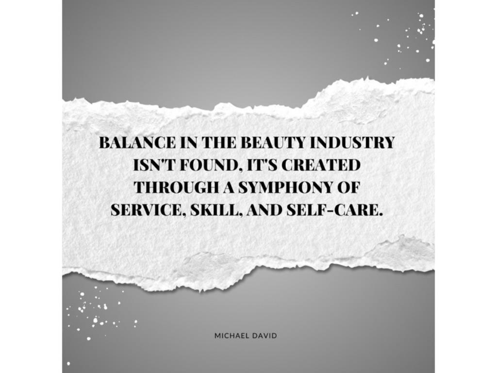

1. Clayton M. Christensen, *The Innovator’s Dilemma: When New Technologies Cause Great Firms to Fail* (Boston: Harvard Business Review Press, 1997). ↩︎
2. Aveda, “Aveda Education,” 2023, accessed March 8, 2025, https://www.aveda.com/education. ↩︎
3. Sam Villa, “Sam Villa: Education IS Self-Care,” American Salon, accessed July 21, 2025, https://www.americansalon.com/education/sam-villa-education-self-care. ↩︎
4. Hairbrained, “Hairbrained Mentorship Program,” 2023, accessed March 8, 2025, https://www.hairbrained.me. ↩︎
5. Journal of Ethnic Studies, “Traditional Hairstyling Techniques and Cultural Significance,” 2020, accessed March 8, 2025, https://www.jes.org. ↩︎
6. UNESCO, “Cultural Heritage and Traditional Skills,” 2021, accessed March 8, 2025, https://www.unesco.org. ↩︎
7. Vogue, “How Top Stylists Mentor the Next Generation,” 2020, accessed March 8, 2025, https://www.vogue.com/article/top-stylist-mentorship. ↩︎
8. Behind the Chair, “The Benefits of Shadowing in Hairstyling,” 2021, accessed March 8, 2025, https://www.behindthechair.com. ↩︎
9. Salon Today, “Building Your Signature Style: Post-Mentorship Strategies,” 2021, accessed March 8, 2025, https://www.salontoday.com. ↩︎
10. Harvard Business Review, “The Value of Peer Feedback in Professional Development,” 2020, accessed March 8, 2025, https://hbr.org. ↩︎
11. American Salon, “How to Prepare for a Master Portfolio Review,” 2022, accessed March 8, 2025, https://www.americansalon.com. ↩︎
12. NAHA, “North American Hairstyling Awards,” 2022, accessed March 8, 2025, https://www.nahaawards.com. ↩︎
13. YouTube, “Educational Channels for Hairstylists,” 2023, accessed March 8, 2025, https://www.youtube.com. ↩︎
14. U.S. Chamber of Commerce, “Community Education Opportunities,” 2021, accessed March 8, 2025, https://www.uschamber.com. ↩︎
15. Wella Professionals, “Trade Show Education: Strategies for Maximizing Value,” 2021, accessed March 8, 2025, https://www.wella.com. ↩︎
16. LinkedIn Learning, “How to Evaluate Online Courses,” 2023, accessed March 8, 2025, https://www.linkedin.com/learning. ↩︎
17. Forbes, “How to Measure the ROI of Continuing Education,” 2020, accessed March 8, 2025, https://www.forbes.com. ↩︎
18. Entrepreneur, “Time Management Tips for Busy Professionals,” 2021, accessed March 8, 2025, https://www.entrepreneur.com. ↩︎

# Part III: Advanced Business Strategies

## Chapters IX—XIII

Welcome to the elite tier where artistic vision meets business mastery. While many stylists reach proficiency, this section charts the territory reserved for those who aim beyond success toward significance. Through intimate case studies of industry titans who faced the same crossroads you now approach, you'll recognize the pivotal decisions that transformed neighborhood stylists into international influences.

These chapters decode the subtle psychology of team leadership, the financial intelligence behind multidimensional revenue streams, and the strategic foresight that positions your brand ahead of market shifts. Here, we examine how the industry's most respected names navigate the delicate balance between creative integrity and commercial growth. These aren't theoretical concepts— they're actionable blueprints for elevating your practice from sustainable to remarkable, drawn from those who've walked this path before you.

IX

Stepping

Into

Leadership

> "And David shepherded them with integrity of heart; with skillful hands he led them."

— Psalm 78:72

## Introduction

**S**tep forward with confidence into a leadership role, where your vision can inspire and transform not only clients but your community. Your impact goes beyond the artistry of a perfect cut or color—it’s about setting trends, mentoring others, and driving innovation in an evolving freelance industry. Freelance hairstylists today are carving out new paths, redefining success on their own terms. Industry trends indicate significant growth in the independent stylist sector in recent years. Freelance hairstylists are influencing every part of the industry, from client engagement to sustainable practices, yet many freelancers hesitate to see themselves as leaders.[^1]

This chapter is an invitation to embrace leadership as an essential aspect of freelance success. We’ll explore how creating a clear vision can be a transformative anchor, how seeking and providing mentorship can unlock potential, and how innovation keeps you relevant in a fast-paced market. Real-world examples from industry trailblazers will illuminate what it means to lead with purpose and conviction. We’ll draw insights from the journeys of pioneering freelance stylists whose vision, mentorship approach, and innovation have redefined segments of the industry. Additionally, proven leadership strategies will guide our approach to vision alignment and freelance leadership development.

Whether you’re a seasoned stylist or a new freelancer, the principles in this chapter will help you harness your unique vision, leverage your strengths, and inspire others. Together, let’s shape a leadership journey that transforms your career and leaves an enduring legacy in the hairstyling world.

## Personal Anecdote: The Moment I Realized I Was Leading

I remember a day that shifted everything for me. I was working independently, focused solely on perfecting my craft, when a group of emerging stylists approached me for advice on a new technique I had developed. Their genuine curiosity and respect made me realize that, despite not working in a traditional salon environment, I was influencing and guiding others.

This recognition transformed my self-perception—from seeing myself merely as an independent artisan to embracing my role as an industry leader. I began to share my insights more openly, mentor those around me, and approach each client interaction with the confidence that my work was setting trends and inspiring peers. That moment taught me that leadership isn’t about titles or positions; it’s about the impact you have on others through your passion, knowledge, and willingness to lift others up.

**Key Insight:** Leadership in hairstyling doesn’t require a formal title or salon ownership—it emerges naturally when you combine expertise with a genuine desire to inspire and guide others.

## I. The Vital Role of Vision in Freelance Leadership

### 1. Start with Your “Why”

In the daily hustle of freelance life, it’s easy to get swept up in the immediate demands—clients, deadlines, bills. However, effective freelance leaders need a guiding vision, a North Star that inspires and aligns each decision. Your “why” is a foundational motivator that brings meaning to your work and clarifies your professional purpose.[^3]

Consider the example of independent educators who have developed specialized training in niche areas of hairstyling. These freelancers didn’t just teach techniques; they had a mission to preserve specific artistry traditions while empowering other independents to build unique careers. Their teaching platforms demonstrate that when you clarify your purpose, you inspire and rally a community around shared values.

To develop your “why,” reflect on what drives your passion for hairstyling. Is it the transformative power of a well-crafted style? A desire to inspire confidence in clients? This core motivation forms the bedrock of your leadership vision.

**Example Reflection Prompts:**

- What motivates you to excel in hairstyling?
- What lasting impact do you want to create for your clients, community, or industry?

> Discovering my core purpose was a gradual yet profound journey. I spent countless hours reflecting on why I was drawn to hairstyling—not just for the art, but for its power to transform lives. This deep introspection led me to understand that my true calling was to instill confidence and empower others through creativity. Once I was clear about my “why,” every business decision began to reflect that purpose. I shifted my focus from quick wins to building meaningful, lasting relationships with my clients, ensuring that each service was not just a transaction but an experience. The tangible result was a more loyal clientele and a business model that aligned perfectly with my personal values.

### 2. Dream Big, Then Bigger

Once you’ve defined your “why,” let yourself dream. Envision an ambitious future, not just for your career but for the broader hairstyling industry. Look at stylists who’ve set visionary goals; for instance, Joshua Coombes, the London-based hairstylist, took a unique approach by founding #DoSomethingForNothing, offering free haircuts to the homeless. His dream went beyond hairstyling—he wanted to use his craft to foster empathy and social impact. Such a vision can inspire significant change and encourage others to join you on your journey.[^4]

**Example Reflection Prompts:**

- What legacy do you want to leave in the hairstyling industry?
- How do you want to challenge existing norms or set new standards?

### 3. Distill and Communicate

A vision is most powerful when it’s clearly articulated. Craft a succinct vision statement that captures your purpose and goals. Share it across your brand platforms—website, social media, client communications. This consistency builds credibility, making it clear what you stand for and attracting clients and collaborators who resonate with your values.

**Example Vision Statement:** “To empower clients to embrace their unique beauty and inspire a movement of freelance stylists who prioritize sustainability and creativity.”

### 4. Leadership in Action: Putting Vision Into Practice

- **Write Your Vision Statement:** Display it where you’ll see it every day, whether it’s your mirror, workstation, or journal. Let it be a constant reminder of the bigger picture you’re working towards.
- **Embed Vision into Branding:** Align your online presence, client interactions, and aesthetic with your vision for cohesive branding. Consistency reinforces credibility.
- **Use Vision as a Decision Tool:** When faced with opportunities or challenges, ask: “Does this align with my vision?” Let your answer guide your path forward. Remember, your vision is a living document. As you grow and the industry evolves, revisit and refine it. The key is to always stay true to the core values and aspirations that drive you.

## II. The Transformative Power of Mentorship

### 1. Seeking Mentorship as a Freelance Leader

In freelancing, mentorship bridges the gap of solitary work, offering opportunities to learn from seasoned professionals, gain industry insights, and expand networks. Many industry leaders began as independent stylists who connected with mentors who shared not only technical knowledge but also business acumen and leadership insights.[^5]

Consider the journey of Jill Buck, an independent stylist who sought mentorship from established experts in precision cutting. Through these relationships, Buck not only refined her technical skills but also gained valuable insights on building her personal brand and developing educational content. Today, she’s known for her meticulous cutting techniques and her ability to teach others, demonstrating how mentorship can transform a solo practitioner into an industry influencer.

**Steps to Find and Connect with Mentors:**

1. **Identify Desired Skills and Traits:** Define the qualities you want in a mentor. Do you admire someone known for their creative color techniques, their business acumen, or their client-centered approach? Look for mentors who can provide the guidance you need in specific areas.
2. **Research Potential Mentors:** Reach out through industry networking events, social media, or local beauty associations. Platforms like Hairbrained and Behind the Chair feature many hairstyling icons who offer mentorship or educational courses.
3. **Make a Thoughtful Approach:** When reaching out, be specific about what you hope to gain from mentorship and why you admire their work. Propose a flexible arrangement, such as monthly virtual coffee chats or shadowing sessions, to show your commitment without imposing on their time.

**Example Approach Template:**

> Dear [Mentor’s Name],

> I hope this message finds you well. My name is [Your Name], and I’ve long admired your work, especially your innovative approach to [specific skill]. As I develop my own freelance career, I would be incredibly grateful for your guidance in [mention specific goals]. I’d love the opportunity to connect and discuss this possibility. Thank you for considering my request.

> Best regards, [Your Name]

**Be an Engaged Mentee:** Actively participating in mentorship means showing up prepared, following through on suggestions, and finding ways to offer value in return. This could be as simple as sharing your unique insights or assisting on projects. Engaged mentees demonstrate commitment and respect, often leading to a more fruitful mentorship experience.

### 2. Providing Mentorship as a Freelance Leader

Mentorship is a two-way street; as you advance in your career, consider giving back by mentoring others. Research shows that freelancers who mentor others report higher job satisfaction and professional growth. By mentoring, you create a ripple effect that strengthens the industry, fostering the next generation of talent.

Take the example of Matt Swinney, who built his career as an independent session stylist before becoming an educator. Despite maintaining his freelance work, Swinney consistently mentors emerging stylists, sharing both technical expertise and insights on navigating the industry as an independent professional. His approach to mentorship focuses on empowering others to find their unique path rather than following a predetermined career template.

**Steps to Be an Effective Mentor:**

1. **Share Your Journey with Authenticity:** Transparency about your own challenges and achievements builds trust and helps mentees feel more connected. Sharing specific experiences—whether it’s a difficult client situation or a breakthrough moment—provides mentees with relatable examples.
2. **Customize Your Approach:** Recognize that each mentee is unique. Take time to understand their goals, strengths, and growth areas. Tailor your guidance to their specific needs and learning style.
3. **Empower, Don’t Prescribe:** Your role is to guide and advise, not dictate. Ask questions that prompt mentees to think critically and arrive at their own solutions. The goal is to foster independence, not dependence.

**Ways to Offer Mentorship:**

- **Start a Peer Mentorship Group:** Connect with fellow freelance stylists to create a support group where you can all share insights, challenges, and growth strategies.
- **Lead Workshops or Classes:** Share your expertise by hosting workshops, either virtually or locally, on topics such as bridal styling, color correction, or business management.
- **Highlight Emerging Talent on Social Media:** Use your platform to recognize new talent, providing exposure and encouragement to emerging stylists. This simple act can have a significant impact on their confidence and career growth.

> An unexpected lesson in leadership came when I began mentoring a young stylist who was brimming with talent but lacked confidence. As I guided her through new techniques and shared insights from my own journey, I was challenged to articulate the very strategies that had fueled my success. This mentoring experience forced me to reflect on my practices, often uncovering nuances I had long taken for granted. In teaching her, I not only helped her grow but also rediscovered fresh perspectives on my own artistry. This process underscored a fundamental truth: true leadership is a two-way street, where nurturing others invariably refines and enriches your own abilities.

### 3. Leadership in Action: Fostering Mentorship Connections

- **Join Industry Mentorship Programs:** Participate in structured mentorship programs offered by professional organizations or local cosmetology schools to facilitate impactful connections.
- **Offer Workshops or Seminars:** Lead a workshop or seminar on a topic of your expertise. Teaching is a powerful form of mentorship that can reach a broad audience.
- **Start a Peer Mentorship Circle:** Gather a group of fellow freelance hairstylists to meet regularly, share challenges, brainstorm solutions, and hold each other accountable to growth goals.
- **Highlight Emerging Talent:** Use your platform—social media, blog, or events—to feature and elevate up-and-coming talent. A simple shoutout or feature can be a game-changer for an emerging freelancer.

Remember, mentorship is a two-way street. Approach every interaction, whether as a mentee or mentor, with an openness to learn and grow. The most impactful mentorship relationships are built on a foundation of mutual respect, trust, and commitment to shared success.

## III. Embracing Change and Innovation

### 1. Stay Curious: Commit to Lifelong Learning

Innovation and adaptability are critical for freelance hairstylists navigating a fast-evolving beauty industry. The COVID-19 pandemic starkly illustrated this need, forcing stylists worldwide to pivot their businesses virtually overnight. Many independent stylists quickly transitioned to virtual consultations and tutorial videos, effectively reshaping client engagement during lockdowns. Stylists who embraced this adaptability emerged stronger, showcasing the power of innovation in securing long-term success.

Commit to continuous learning. Attend industry conferences, enroll in online courses, follow influencers who are pushing the boundaries of the craft. The more you expose yourself to new ideas, the more fodder you have for innovation.

**Example:**

- **Stay Curious Action:** Subscribe to leading hairstyling journals and participate in webinars to stay updated on the latest techniques and trends.

**Steps to Cultivate Curiosity and Stay Updated:**

1. **Subscribe to Industry Publications and Platforms:** Stay informed by reading publications like Salon Today, Behind the Chair, and Modern Salon. These sources provide regular updates on new trends, products, and techniques, as well as profiles of trailblazing stylists.
2. **Attend Online Courses and Webinars:** Platforms like Hairbrained, Pulp Riot’s education hub, and L’Oréal Access offer specialized courses on topics such as color theory, texture, and sustainable practices. Many courses offer certifications, adding valuable credentials to your professional portfolio.
3. **Network with Other Innovators:** Joining industry forums or groups, such as the Professional Beauty Association (PBA) or Hairbrained, connects you with stylists who share insights, experiences, and the latest industry techniques.

### 2. Embrace Experimentation and Flexibility

Experimentation is a key driver of innovation. Many freelance hairstylists hesitate to try new approaches, fearing failure or client dissatisfaction. However, experimentation allows stylists to discover new services, products, and techniques that can set them apart. Independent colorists who regularly experiment with new formulations and application methods often develop signature techniques that attract a loyal clientele and social media following.

**Steps to Embrace Experimentation:**

1. **Pilot New Services on Selected Clients:** Start by offering a new service—such as balayage, fantasy color, or scalp treatments—to trusted clients at a discounted rate. Gather feedback to refine and perfect the service.
2. **Document and Analyze Results:** Track the results of your experiments, noting client reactions, challenges, and outcomes. This data can help you determine if the new service is worth formally adding to your portfolio.
3. **Develop a Feedback Loop with Clients:** Let clients know you value their input, especially when testing new techniques or products. This not only builds rapport but also provides valuable insights into client preferences.

**Example Experiments:**

- **DIY Kits and Virtual Consultations:** Like many stylists during the pandemic, consider offering virtual consultations for clients who want to maintain their style at home or experiment with DIY kits for touch-ups.
- **Eco-Friendly Practices:** Experiment with sustainable products or low-waste techniques to attract eco-conscious clients. Many stylists have adopted refillable product systems and compostable tools, aligning their brand with sustainable values.

### 3. Seek Diverse Perspectives: Learn from Other Industries

Innovation often flourishes at the intersection of different industries. By connecting with professionals outside of hairstyling—such as fashion designers, makeup artists, or technology experts—stylists can gain fresh insights and inspire creative breakthroughs. Fashion houses often collaborate with freelance stylists to integrate hairstyling into fashion storytelling, emphasizing the role of hairstylists in broader creative industries.

**Steps to Gain Diverse Perspectives:**

1. **Collaborate with Other Creatives:** Partner with makeup artists, photographers, or fashion designers for joint projects. These collaborations often yield unique style concepts, positioning you as a versatile and innovative stylist.
2. **Attend Cross-Industry Events:** Participate in events such as fashion weeks, beauty conventions, and wellness summits. Observing trends in these areas can offer inspiration for hairstyling techniques or business strategies.
3. **Join Local Creative Groups:** Connect with creatives in your area through meetups or social media groups. Many cities have creative groups where artists from different fields exchange ideas and offer feedback.

**Examples of Cross-Industry Innovation:**

- **Virtual Styling Consultations:** Inspired by tech-based consultations in other industries, some hairstylists now offer personalized virtual styling sessions for long-distance clients.
- **Social Media Storytelling:** Stylists can learn branding and storytelling strategies from influencers in adjacent fields, such as beauty and wellness, applying those strategies to enhance their own brand presence.

### 4. Leadership in Action: Innovating Your Freelance Business

Implementing innovation into a freelance business requires structure, commitment, and vision. Adopting a business model that prioritizes regular innovation sessions or “CEO Days” helps stylists plan and experiment with new approaches systematically. Many successful freelance stylists have exemplified business innovation by continuously reinventing their styling techniques and social media presence, keeping their brand fresh and highly sought after.

**Actionable Steps to Innovate Your Business:**

1. **Schedule Monthly “CEO Days”:** Dedicate a day each month to focus solely on business strategy and innovation. Use it to analyze trends, brainstorm new offerings, and map out implementation plans.
2. **Leverage Client Feedback for Innovation:** Create feedback channels, such as follow-up emails or surveys, to understand client preferences and unmet needs. Use this data to tailor new services or enhance existing ones.
3. **Incorporate Emerging Technologies:** Partner with a tech-savvy friend or hire a consultant to help you integrate new technologies into your business. From virtual reality hair consultations to AI-powered color matching, innovation often lies at the intersection of creativity and tech.
4. **Evaluate and Adapt Regularly:** Reassess your innovation efforts quarterly, examining what worked and what didn’t. Adjust your strategies based on these assessments to continually refine your approach.

By treating innovation as an ongoing practice, freelance stylists can not only adapt to industry changes but actively drive them, positioning themselves as leaders and trendsetters in their field.

## IV. Building Your Network of Support and Collaboration

### 1. Lead with Generosity

The myth of the solo entrepreneur is just that—a myth. Behind every successful freelance leader is a robust network of supporters, collaborators, and champions. Approach every interaction with a “give first” mindset. Share your knowledge, make introductions, offer support—without expecting anything in return. The more value you provide to your network, the more inclined they’ll be to support you when you need it.[^6]

**Example:**

- **Generosity Action:** Offer free consultations or hairstyling sessions to emerging stylists in exchange for their insights and feedback.

### 2. Prioritize Quality Over Quantity

Focus on building genuine, mutually beneficial relationships, not just amassing a large number of superficial connections. Regularly check in with your contacts, express appreciation for their support, and look for ways to deepen the bond.

**Example:**

- **Quality Relationships Action:** Schedule monthly catch-up calls with key contacts to discuss their projects and offer assistance where possible.

### 3. Diversify Your Connections

While it’s important to have strong ties within the hairstyling community, don’t limit your network to just your immediate industry. Cultivate relationships with professionals from related fields—photography, fashion, beauty, wellness. These cross-disciplinary connections can open up exciting opportunities for collaboration and cross-pollination of ideas.

**Example:**

- **Diversify Connections Action:** Partner with a local photographer to offer bundled services for photoshoots, enhancing both your portfolios.

### 4. Leadership in Action: Strengthening Your Network

- **Attend Industry Events Regularly:** Set a goal to make meaningful new connections at each event and follow up within 48 hours to keep the momentum going.
- **Volunteer Your Skills:** Offer your hairstyling services for local charities or community events. This not only expands your network but also positions you as a leader committed to making a difference.
- **Start a “Collaboration Club”:** Gather a group of fellow creatives to meet monthly, brainstorm joint projects, cross-promote each other’s work, and hold each other accountable to networking goals.
- **Create a “Relationship Tracker” Spreadsheet:** Manage your network by noting key details about each contact, the last time you connected, and next steps for nurturing the relationship. Schedule regular “outreach hours” to ensure you’re consistently staying in touch.

Remember, your network is your net worth. By investing consistently in building and nurturing authentic relationships, you create a web of support that will sustain and propel your freelance career for years to come.

## V. Micro-Leadership: Daily Practices for Freelance Leaders

Leadership isn’t reserved for those managing large teams or owning salons. For freelance hairstylists, leadership manifests through small, consistent actions that gradually build influence and inspire others. These “micro-leadership” practices can be integrated into your daily routine, regardless of your career stage or working environment.[^7]

### 1. Small Actions with Big Impact

Leadership begins with mindful, intentional choices that reflect your values and vision. These seemingly small actions can have a ripple effect, influencing clients, peers, and the broader industry.

**Daily Micro-Leadership Practices:**

- **Morning Intention Setting:** Begin each day by setting a specific leadership intention, such as “Today I will inspire creativity in each client interaction” or “Today I will share one valuable tip with a fellow stylist.”
- **Client Education Moments:** Use every service as an opportunity to educate clients about proper hair care, styling techniques, or product choices. This positions you as an authority and empowers clients to make informed decisions.
- **Technique Sharing:** When you discover a helpful shortcut or technique, share it with other freelancers in your community rather than keeping it to yourself. This generosity builds your reputation as a collaborative leader.
- **Active Listening:** Practice focused, empathetic listening during client consultations and conversations with peers. True leaders listen more than they speak, gathering insights that inform better decisions.
- **Positive Industry Representation:** Conduct yourself professionally in all interactions, knowing that you represent not just yourself but the hairstyling profession. Small courtesies like punctuality and follow-through build trust in you and the industry.

### 2. Digital Micro-Leadership

In today’s connected world, leadership extends into digital spaces. Even modest social media accounts can be platforms for influence and inspiration when used intentionally.

**Digital Leadership Actions:**

- **Share Educational Content:** Post quick tutorials, product reviews, or styling tips that provide genuine value to followers. Even a simple Instagram Story demonstrating a blow-drying technique can position you as a generous knowledge-sharer.
- **Celebrate Others’ Work:** Use your platform to highlight and praise exceptional work by other stylists. This not only supports them but demonstrates your commitment to community over competition.
- **Engage Thoughtfully:** Leave substantive comments on industry discussions rather than just likes or generic responses. Adding your unique perspective contributes to the professional dialogue.
- **Curate Quality Information:** Share articles, research, and resources that elevate the profession’s standards and knowledge base. This establishes you as someone committed to industry advancement.

### 3. Client-Centered Leadership

Every client interaction is an opportunity to demonstrate leadership through exceptional service and ethical practices.

**Client Leadership Practices:**

- **Ethical Recommendations:** Suggest only services and products that truly benefit the client, even when it means a smaller sale. This integrity builds trust and positions you as a client advocate rather than just a service provider.
- **Setting Industry Standards:** Implement best practices in sanitation, sustainability, and inclusive service, even when they require extra effort. These actions elevate standards for the entire profession.
- **Transparent Communication:** Be straightforward about pricing, timing, and realistic service outcomes. This honesty changes client expectations in positive ways that benefit all stylists.
- **Feedback Solicitation:** Actively seek client feedback and implement improvements based on their suggestions. This demonstrates a growth mindset that inspires others.

### 4. The Freelance Leadership Progression

Leadership development for freelancers follows a natural progression as your influence grows. Understanding these stages helps you recognize your current leadership level and identify next steps for growth.

| Leadership Stage | Primary Focus | Key Actions | Impact Scope |
| --- | --- | --- | --- |
| Self-Leadership | Personal excellence | Mastering skills, continuing education, self-discipline | Individual growth |
| Client Leadership | Exceptional service | Education, consultations, building trust | Direct client base |
| Peer Leadership | Supporting colleagues | Technique sharing, mentorship, collaboration | Local stylist community |
| Industry Leadership | Advancing the profession | Education creation, advocacy, innovation | Broader hairstyling field |

Remember that you can demonstrate leadership at any stage of your career. A new freelancer carefully documenting their work and sharing honest reflections about their learning journey is practicing leadership just as surely as an experienced stylist developing educational content or advocating for industry changes.

### 5. Practical Examples of Freelance Leadership

These real-world examples demonstrate how independent stylists have exercised leadership through everyday actions:

- **The Standards-Setter:** A freelance stylist who consistently uses and promotes sustainable, cruelty-free products influences both clients and peers to make more environmentally conscious choices. This subtle leadership gradually shifts industry norms without requiring a formal leadership position.
- **The Community Builder:** An independent stylist who started a simple monthly meet-up for local freelancers to share techniques and support each other has created a valuable network that enhances everyone’s work. This modest initiative demonstrates leadership through community building.
- **The Knowledge Sharer:** A freelancer who regularly posts detailed breakdowns of their color formulations and techniques on social media, freely sharing information that others might keep proprietary, elevates the skill level of their entire digital community.
- **The Boundary Establisher:** A stylist who implements and clearly communicates professional policies regarding scheduling, cancellations, and consultations helps clients understand the value of professional services while setting standards that benefit all stylists.

> Over the years, I’ve learned that leadership isn’t defined by grand gestures but by the consistency of small, intentional actions. Every day, I start with a brief moment of reflection and set clear intentions—not just for my creative output, but for how I can inspire and support my community. Whether it’s sharing a quick styling tip on social media, sending a thoughtful note to a client, or setting aside time for informal check-ins with emerging talents, these practices have gradually built a strong, supportive network. These daily habits have not only enhanced my own discipline and focus but have also cultivated trust and a sense of belonging among my clients and peers, ultimately amplifying my influence in the hairstyling industry.

## VI. Conclusion: Stepping into Leadership

Leadership in freelancing isn’t confined to titles or formalities—it’s about shaping your professional world with vision, purpose, and adaptability. Throughout this chapter, we explored the pillars of effective freelance leadership: setting a compelling vision, seeking and giving mentorship, embracing change and innovation, cultivating a robust network, and implementing daily micro-leadership practices. Each section emphasized that leadership, especially in the freelance hairstyling industry, is as much about personal development as it is about impact on clients, peers, and the larger industry.

Vision is the cornerstone of leadership, and a well-defined vision serves as a guiding compass. As we’ve seen, having a vision grounded in personal values and industry awareness doesn’t just benefit individual careers—it raises the standard for the entire field. Mentorship, both sought and offered, is the path to accelerated growth and a thriving community, passing down skills, knowledge, and confidence to the next generation. Innovation, meanwhile, is essential in an industry that thrives on trends and change. Freelancers who lead the way in adopting new techniques, technologies, and approaches will stand out in a crowded market.

The micro-leadership practices we’ve explored demonstrate that you don’t need formal authority to be influential. Through consistent small actions—from how you educate clients to how you share knowledge with peers—you build a leadership presence that transcends traditional hierarchies. A strong network of peers and collaborators acts as both a safety net and springboard, bolstering resilience, creating opportunities, and fostering professional fulfillment.

Every freelance hairstylist has the opportunity to redefine leadership on their own terms, inspiring those around them and shaping the future of the beauty industry. Leadership is a choice. It’s a daily decision to show up not just as a skilled technician but as a visionary, a trailblazer, an uplifter of others. It’s a commitment to not just doing your best work but to being your best self—for your clients, your community, and your craft.

## Case Study: Joshua Coombes - Leadership Through Social Impact

**Real-Life Example: Joshua Coombes, Street Barber and Social Entrepreneur**

**Challenge:** Joshua Coombes wanted to use his hairstyling skills to make a meaningful difference in his community while building his professional reputation. He noticed the disconnect between the beauty industry’s focus on glamour and the real needs of vulnerable populations in his city.

**Solution:** Coombes created the #DoSomethingForNothing movement, taking his barbering skills to the streets to provide free haircuts for homeless individuals. He documented these acts of service on social media, not for self-promotion, but to inspire others to use their professional skills for social good. He trained other barbers to join the movement and collaborated with homeless charities to maximize impact.

**Outcome:** The movement has spread globally, with thousands of hairstylists participating in over 30 countries. Coombes has cut hair for hundreds of homeless individuals, been featured in major media outlets, spoken at industry conferences, and inspired a new model of socially conscious hairstyling. His leadership has elevated both his career and the entire industry’s awareness of social responsibility.

**Lessons Learned:** True leadership emerges when you use your professional skills to serve others beyond commercial gain. By addressing real social needs with his expertise, Coombes demonstrated that hairstylists can be powerful agents of positive change, inspiring others to follow his example of purposeful leadership.

## Actionable Steps

1. **Set three micro-leadership goals for the next 30 days.** These could include mentoring one new stylist, starting an online discussion about industry trends, or organizing a small networking event.
2. **Identify your unique perspective or expertise and find ways to share it.** Whether through social media, workshops, or informal conversations, make your insights accessible to others.
3. **Practice active listening and empathy in all professional interactions.** Leadership is as much about understanding others as it is about being understood.
4. **Commit to lifelong learning.** Stay updated on industry trends, new techniques, and emerging technologies. A leader who stops learning stops leading.
5. **Build genuine relationships within and outside the hairstyling community.** Collaborate with professionals from related fields like fashion, photography, and wellness to broaden your perspective and expand your influence.

## Key Takeaways

1. **Craft a Compelling Vision:** Develop a vision aligned with your values that acts as a guide for your career. Communicate it clearly to inspire others and keep your goals in focus.
2. **Actively Seek Mentorship:** Accelerate your growth by connecting with mentors and contribute to the community by mentoring others as you advance in your leadership journey.
3. **Cultivate a Mindset of Innovation:** Stay curious, experiment boldly, and proactively adapt to industry changes to maintain relevance and competitiveness.
4. **Build a Diverse, Robust Network:** Develop a network of supporters, collaborators, and champions who can help you navigate the challenges and opportunities of freelance life.
5. **Practice Micro-Leadership Daily:** Integrate small but powerful leadership actions into your daily routine to gradually build influence and inspire others.
6. **Embrace Your Role as a Leader:** Lead not just in title but in mindset and action, recognizing the impact you have on your clients, community, and industry.

## Quiz

### Question 1

What is the most important foundation for effective leadership in freelance hairstyling?

- A) Having the most advanced technical skills
- B) Owning expensive equipment and tools
- C) Having a clear vision and strong "why" behind your work
- D) Working in the most prestigious salons

### Question 2

According to the chapter, what characterizes micro-leadership in hairstyling?

- A) Only making big, dramatic changes in the industry
- B) Small, consistent actions that positively influence others daily
- C) Focusing solely on your own career advancement
- D) Waiting until you have formal authority to lead

### Question 3

What was the key insight from Joshua Coombes' #DoSomethingForNothing movement?

- A) Social media promotion is essential for leadership
- B) Only famous stylists can make a difference
- C) Professional skills can be powerful tools for social impact and leadership
- D) Leadership requires expensive marketing campaigns

### Question 4

What role does vulnerability play in effective leadership for hairstylists?

- A) It should be avoided to maintain professional credibility
- B) It creates authentic connections and inspires trust
- C) It's only appropriate in personal relationships, not professional ones
- D) It demonstrates weakness and undermines authority

## Worksheet

### Freelance Leadership Development Plan

#### Part 1: Vision Statement Development

1. **What core values drive your passion for hairstyling? List 3-5 values that are most important to you professionally.**
2. **Imagine the future of hairstyling: what specific role do you want to play in shaping it?**
3. **How do you want to influence your clients, the hairstyling community, and the industry at large?**
4. **Draft Your Vision Statement: Craft a clear, motivational statement based on your reflections above.**

#### Part 2: Leadership Skills Assessment

Rate yourself from 1 (needs development) to 5 (strength) in each leadership area:

5. **Vision & Purpose: Ability to create and communicate an inspiring vision**
6. **Mentorship: Ability to guide others and seek guidance when needed**
7. **Innovation: Willingness to experiment and adapt to changes**
8. **Relationship Building: Skill in creating a supportive network**
9. **Daily Leadership Practices: Consistency in small leadership actions**

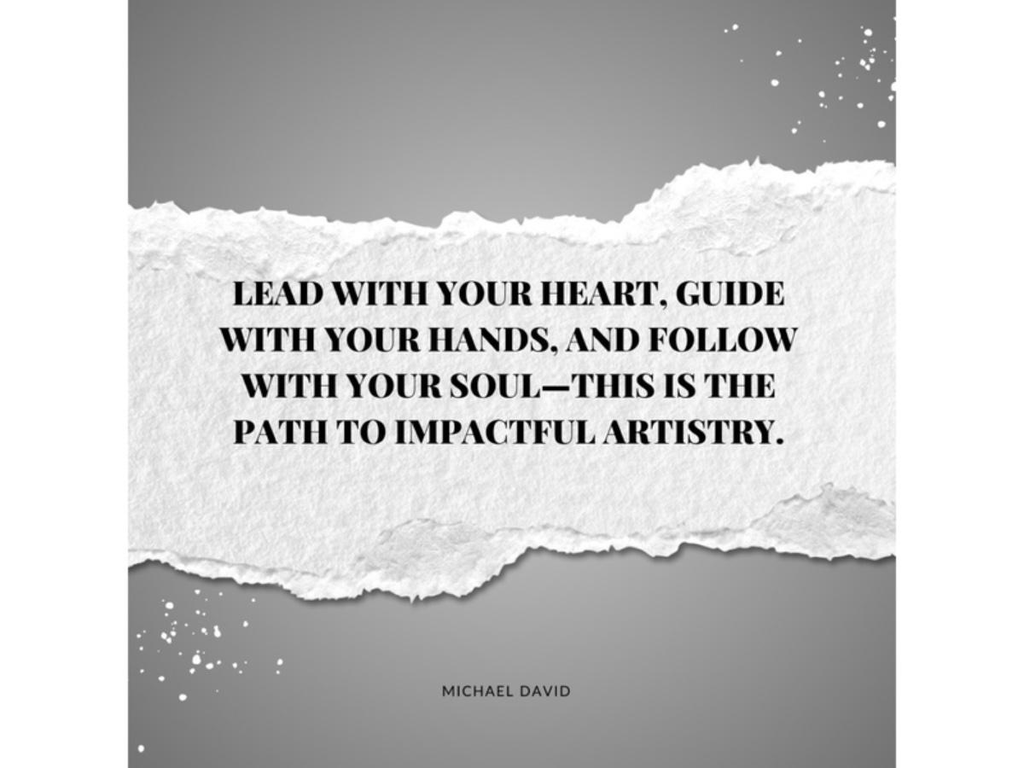

1. Salon Today, “The Rise of Freelance Hairstylists,” 2021, accessed March 8, 2025, https://www.salontoday.com. ↩︎
2. Simon Sinek, *Start With Why: How Great Leaders Inspire Everyone to Take Action* (New York: Portfolio, 2009), accessed March 8, 2025, https://www.startwithwhy.com. ↩︎
3. Essence, “How Independent Stylists Are Changing the Game,” 2019, accessed March 8, 2025, https://www.essence.com. ↩︎
4. Behind the Chair, “Mentorship in Freelance Hairstyling: Success Stories,” 2018, accessed March 8, 2025, https://www.behindthechair.com. ↩︎
5. Mark Granovetter, “The Strength of Weak Ties,” *American Journal of Sociology* 79, no. 6 (1973): 1360–1380, accessed March 8, 2025, https://www.jstor.org/stable/2776392. ↩︎
6. Harvard Business Review, “The Power of Small Leadership Acts,” 2020, accessed March 8, 2025, https://hbr.org. ↩︎

X

Crafting

Enduring

Legacies

> "But the fruit of the Spirit is love, joy, peace, forbearance, kindness, goodness, faithfulness, gentleness, and self-control. Against such things, there is no law."

— Galatians 5:22-23

## Introduction

**C**onsider the impact of your work not just today, but as a legacy shaping the future of hairstyling artistry and entrepreneurship. Beyond technical skill, crafting a lasting legacy in this field depends on sustained well-being and the courage to invest in self-care. This chapter explores how hairstylists can prioritize their well-being to make their careers not only sustainable but also deeply fulfilling and inspirational for future generations.

Imagine the scissors trembling in your hand, their familiar weight suddenly feeling foreign. Your reflection in the mirror stares back, a stranger behind the mask of a confident stylist. Beneath the surface, a storm of doubt, exhaustion, and pressure swirls—challenging your passion at every turn. This is the hidden battlefield of the hairstylist, where the joy of artistry is often in tension with the brutal demands of an unforgiving industry. It’s easy to feel consumed by the relentless pace, where creativity and service intertwine, and the spark that once illuminated every move dims, worn down by the physical, mental, and emotional toll of giving so much of ourselves.

## Personal Anecdote: The Wake-Up Call That Changed Everything

There was a pivotal moment in my career when I was forced to confront my own mortality. After a particularly grueling week of back-to-back appointments, I experienced a brief health scare that left me shaken. In the midst of this vulnerability, a mentor reached out and shared a simple but profound truth: “Your art isn’t confined to a single day’s work—it’s the legacy you leave behind.”

That conversation changed everything for me. I realized that while my daily client work was essential, I had the opportunity to build something far greater—a legacy that would inspire future generations of hairstylists. This new perspective shifted my focus from short-term success to long-term impact, motivating me to invest in mentorship, document my techniques, and contribute meaningfully to the industry.

**Key Insight:** True success in hairstyling isn’t measured by daily appointments or immediate profits, but by the lasting impact you create through your work, mentorship, and contributions to the industry’s future.

Yet, for hairstylists, true self-care is not a luxury but a necessity—a pillar of creating a legacy that endures. Consider the inspiration of brands like Olaplex and Mielle Organics. Olaplex, a trailblazer in hair health, transformed the industry by pioneering bond-repair technology, redefining how stylists approach hair care with innovation and science. For stylists, Olaplex stands as a symbol of progress and resilience.[^1] Mielle Organics, led by Monique Rodriguez, exemplifies a holistic, community-centered approach, particularly within the Black community. Mielle’s natural ingredients celebrate textured hair, embracing and honoring diversity—a testament to how brands can have a profound impact by aligning with the values of their communities.[^2]

As we explore self-care, resilience, and legacy-building, let these brands be a reminder: resilience, purpose, and a commitment to authenticity create an impact that extends beyond ourselves. By embracing self-care as an essential part of our craft, we ensure our own well-being and deepen the legacy we leave for others. Join this journey of self-care mastery, reconnecting with your core needs, prioritizing growth, and crafting an enduring legacy, one rooted not just in skill but in the depth of fulfillment and joy you bring to every client and moment.

## Legacy Building Timeline: A Phased Approach

Building a meaningful legacy can feel overwhelming when viewed as a single, monumental task. Instead, think of it as a series of intentional steps taken over time. This phased approach breaks down legacy-building into manageable stages, allowing you to make consistent progress without feeling overwhelmed:[^3]

### Phase 1: Immediate Impact (1-3 Months) ⚡

Start with quick-win actions that build momentum and establish a foundation for greater impact:

- Implement daily self-care practices (5-10 minutes of stretching, meditation)
- Organize your financial records and explore automation tools
- Begin documenting your unique techniques and approaches
- Reach out to one potential mentor or peer for connection

### Phase 2: Short-term Growth (3-12 Months) ⏱️

Focus on consistent habit-building that strengthens your foundation:

- Establish regular therapeutic sessions (massage, mobility work)
- Join or form a virtual accountability circle with peers
- Implement a fully automated financial tracking system
- Create clear work-life boundaries with scheduled downtime

### Phase 3: Medium-term Development (1-3 Years) ⏱️

Build relationships and systems that support sustained growth:

- Mentor an emerging stylist and document the experience
- Develop signature techniques or specialized service offerings
- Establish a recognizable personal brand aligned with your values
- Create content that shares your unique approach and philosophy

### Phase 4: Long-term Legacy (3+ Years) 🌱

Focus on contributions that will outlast your active career:

- Explore franchising or licensing your techniques/approach
- Develop training programs or educational resources
- Advocate for industry improvements or ethical standards
- Create mentorship structures that will continue beyond your direct involvement

Remember that legacy-building isn’t linear—elements from different phases can happen simultaneously. The key is to start where you are with the resources you have, and consistently take steps that align with your vision for long-term impact.

## I. Optimizing the Physical Instrument: Ergonomic and Nutritional Strategies

### 1. Investing in Strain-Mitigating Equipment and Workspaces

Creating an ergonomic workspace is essential for hairstylists, who often endure long hours on their feet. Just as Olaplex has redefined hair care with its focus on bond-repair, investing in ergonomic tools and equipment allows hairstylists to work sustainably, protecting their health and career longevity. Imagine a workspace that feels as supportive as Olaplex’s products are for hair—one designed to minimize strain and nurture physical well-being through each long day of creative work. Ergonomic additions like anti-fatigue mats, adjustable stools, and balanced shears are investments that align with the same dedication to quality and longevity that Olaplex represents in the world of hair care.[^4]

**Actionable Steps for a Supportive Workspace ⚡:**

- Ergonomic Assessment: Just as Olaplex prioritizes hair health, consider how your tools and setup could be enhanced to prioritize your physical health.
- Invest in Anti-Fatigue Mats and Adjustable Equipment: Much like how Olaplex protects hair integrity, these investments help protect your physical integrity over the long term.

### 2. Implementing Preventative Therapeutic Massage and Mobility Routines

> For years, the physical toll of long days on my feet and the repetitive motions inherent in freelance hairstyling began manifesting as chronic shoulder and back pain. I vividly remember the day when the discomfort became so intense that I nearly canceled several client sessions. A trusted colleague recommended I try regular therapeutic massage as a preventative measure. Although I was hesitant at first, I soon discovered that these sessions did more than just alleviate pain—they restored my energy, improved my posture, and sparked a renewed level of creative clarity. Embracing this practice transformed my physical well-being and has been key to sustaining my career longevity, proving that caring for my body is just as important as refining my craft.

Your hands are your livelihood, your arms and shoulders the conduits of your creativity. Yet how often do you tend to these crucial instruments with the same care and attention you lavish on your clients’ hair? In addition to optimizing our physical environment, hairstylists can benefit greatly from implementing preventative therapeutic practices, such as massage and mobility routines. Regular massage sessions can help alleviate muscle tension, improve circulation, and promote relaxation, while targeted mobility exercises can enhance flexibility, strength, and overall physical resilience. Imagine ending each week with a deep tissue massage, feeling the knots of tension melt away under skilled hands that understand the unique strains of your profession.

**Actionable Steps ⏱️:**

1. Schedule Regular Massage Sessions: Book regular appointments with a qualified massage therapist who understands the physical demands of hairstyling. Opt for massages that focus on the neck, shoulders, back, and hands.
2. Develop a Daily Mobility Routine: Incorporate stretching and mobility exercises into your daily schedule. Focus on areas most affected by your work, such as the neck, shoulders, back, and wrists.
3. Integrate Mobility Breaks: Take short, frequent breaks during your workday to perform simple stretches. Even 2-3 minutes of stretching between clients can significantly reduce muscle fatigue and prevent strain.
4. Use Mobility Tools: Utilize tools like foam rollers, resistance bands, or yoga mats to enhance your mobility routines. These can help target specific muscle groups and improve overall flexibility.
5. Prioritize Recovery: Allocate time before and after your shifts for relaxation and recovery practices. This can include light stretching, deep breathing exercises, or using heat therapy to soothe tired muscles.

### 3. Fueling Peak Creativity with Anti-Inflammatory Nutrition Principles

A stylist’s diet fuels their creativity and focus—much like Mielle Organics fuels the health and beauty of textured hair with nutrient-rich ingredients. Known for its natural approach, Mielle Organics proves that what we put in and on our bodies can have a transformative effect. By embracing anti-inflammatory foods such as leafy greens, omega-3-rich fish, and nuts, hairstylists can sustain the steady energy needed to keep their creative edge sharp. Consider starting your day with a smoothie rich in antioxidants—an approach as nourishing for your body as Mielle’s formulas are for hair.[^5]

**Actionable Steps for Nutritional Health ⚡:**

- Embrace Nutrient-Dense Foods: Just as Mielle Organics centers natural ingredients, prioritize whole, nutrient-rich foods to optimize your mental and physical energy.
- Hydrate and Snack Smart: Mielle Organics’ commitment to high-quality, restorative ingredients is a reminder to value what fuels your own performance. Keep water, herbal teas, and nutrient-rich snacks within reach throughout the day.

## II. Fortifying the Creative Spirit: Mental Clarity Practices

### 1. Cultivating Headspace through Breath Work and Meditation

Mental clarity is essential for sustained creativity. Start with simple breath work exercises, like 4-7-8 breathing: inhale for 4 seconds, hold for 7, and exhale for 8. This technique calms the nervous system and clears the mind. Incorporate short meditations into your day, focusing on visualization or gratitude to reset and center your mind.[^6]

In the bustling environment of a salon, finding moments of calm can seem impossible. Yet, it’s in these pockets of stillness that we often unlock our greatest creativity and resilience. One of the most powerful tools for cultivating mental clarity and emotional balance is the practice of breath work and meditation. By taking intentional moments throughout the day to focus on our breath and quiet our minds, we can reduce stress, enhance focus, and tap into a deeper well of creativity and intuition. Imagine starting your day with five minutes of mindful breathing, feeling the stress and anxiety melt away as you focus on the simple rhythm of your inhales and exhales.

**Actionable Steps ⏱️:**

1. Incorporate a Daily Meditation Practice: Start your morning routine with 5-10 minutes of meditation. Use guided meditation apps or simple breathing techniques to center your mind and prepare for the day ahead.
2. Practice Breath Work Techniques: Utilize techniques like box breathing or alternate nostril breathing during high-stress moments to quickly regain focus and calm. These methods can help reduce anxiety and improve mental clarity.
3. Create a Dedicated Meditation Space: Designate a quiet area in your workspace or home for meditation and reflection. Equip this space with calming elements such as plants, soft lighting, and comfortable seating to promote tranquility.
4. Use Visualization and Gratitude Practices: Incorporate visualization exercises to imagine your goals and aspirations, and practice gratitude to foster a positive mindset. This can enhance your emotional well-being and inspire creative ideas.
5. Join Meditation Groups: Consider joining local or online meditation groups to build a supportive community and stay motivated in your practice. Sharing experiences with others can deepen your understanding and commitment to meditation.

### 2. Preserving Inspiration with Whitespace Pauses and Nature Immersions

Scheduling whitespace days can help refresh your creativity, much like how Mielle Organics has brought freshness and innovation to hair care by celebrating natural ingredients and honoring the cultural heritage behind them. Spending time outdoors—whether on a hike, at a botanical garden, or simply stepping away for fresh air—provides rejuvenation that aligns with Mielle’s philosophy of natural, holistic care. Nature has a restorative effect that clears mental clutter, sparking creativity and helping stylists return to work with a renewed sense of purpose, much as Mielle’s approach brings a sense of vitality and rejuvenation to textured hair care.

In the fast-paced world of hairstyling, it’s easy to get caught up in the constant hustle and forget to make space for the things that inspire and rejuvenate us. By intentionally creating whitespace pauses in our schedules and immersing ourselves in nature, we can preserve our creative spark and avoid burnout. Imagine blocking off one day each month as your “inspiration day,” where you step away from the salon and engage in activities that fill your creative well, such as visiting museums, attending workshops, or exploring new neighborhoods. Picture how refreshed and reinvigorated you’d feel returning to your clients, brimming with new ideas and enthusiasm.

**Actionable Steps 🌱:**

1. Schedule Regular “Inspiration Days”: Allocate one day each month dedicated solely to activities that inspire you. This could include visiting art galleries, attending creative workshops, or exploring new areas in your city.
2. Incorporate Nature Immersions: Make it a habit to spend time outdoors regularly. Whether it’s a daily walk in the park, a weekend hike, or tending to a garden, nature has a restorative effect on the mind and spirit.
3. Practice Mindful Observation: During your time in nature, practice mindfulness by observing the details around you—the colors, textures, sounds, and scents. This can spark new ideas and enhance your creative thinking.
4. Engage in Creative Hobbies: Use your inspiration days to pursue hobbies outside of hairstyling, such as painting, writing, or photography. These activities can provide fresh perspectives and fuel your creativity.
5. Limit Digital Distractions: On your inspiration days, minimize screen time and digital distractions. Focus on activities that engage your senses and encourage deep reflection.

### 3. Structuring Work-Life Boundaries for Rejuvenation Cycles

> There was a time when work consumed every moment of my day. I recall one weekend all too clearly: I sacrificed a long-planned family celebration because last-minute client requests pulled me away from personal time. The ensuing disappointment and burnout served as a harsh wake-up call. I realized that without clear boundaries, my passion for hairstyling was at risk of being overwhelmed by constant stress. Determined to reclaim my creative energy, I began setting strict work-life boundaries—scheduling dedicated downtime, disconnecting from work emails, and reserving time solely for personal pursuits. This small but significant change revitalized my spirit, restored my creativity, and ultimately made me a more effective and fulfilled hairstylist.

As passionate professionals, it’s easy to blur the lines between work and personal life, leading to overwork, exhaustion, and a diminished sense of joy and purpose. By structuring clear work-life boundaries and prioritizing regular rejuvenation cycles, we can sustain our creative energy and avoid the pitfalls of burnout. Imagine ending your workday with a clear mind, leaving your professional concerns at the salon door. Picture having evenings and weekends free to pursue hobbies, spend time with loved ones, or simply rest without feeling guilty or anxious about work. This balance isn’t just good for your personal life—it’s essential for maintaining the enthusiasm and creativity that drew you to hairstyling in the first place.

**Actionable Steps ⏱️:**

1. Establish Clear Start and End Times: Define specific hours for your workday and communicate these boundaries to your clients and colleagues. Stick to these times to ensure you have dedicated periods for rest and personal activities.
2. Create Pre- and Post-Work Rituals: Develop routines that help you transition between work and personal life. This could include journaling, stretching, or engaging in a brief meditation session to clear your mind.
3. Schedule Regular Vacations and Breaks: Plan time off throughout the year to disconnect from work completely. Whether it’s a short weekend getaway or an extended vacation, taking breaks is crucial for long-term well-being.
4. Prioritize Sleep and Exercise: Ensure you get adequate sleep each night and incorporate regular physical activity into your routine. Both are vital for maintaining energy levels and reducing stress.
5. Engage in Personal Hobbies: Dedicate time to activities you enjoy outside of hairstyling. Whether it’s reading, cooking, or painting, personal hobbies can provide a creative outlet and enhance your overall happiness.

## III. Building Support Networks: Belonging Through Vulnerability

### 1. Engaging with Local Entrepreneurial Peer Alliances

A strong network offers invaluable support in building a lasting career. Mielle Organics has become a cornerstone within the Black community by prioritizing authenticity and building a brand that uplifts and supports the very community it serves. For hairstylists, creating networks with a similar sense of purpose and belonging is key to resilience. Engage with local groups or industry communities where you can share challenges, victories, and industry insights, taking inspiration from Mielle Organics’ commitment to its community. By connecting with peers, you cultivate a support system that strengthens your career while creating meaningful relationships.

**Actionable Steps for Building a Network ⏱️:**

- Attend Local and Virtual Events: Seek out industry events and community gatherings, inspired by Mielle’s mission of inclusivity and empowerment.
- Propose Informal Mastermind Sessions: Use these sessions to exchange ideas, drawing from the collaborative spirit that brands like Mielle Organics represent.

### 2. Launching Virtual Accountability Circles for Intimate Guidance

Forming a virtual accountability circle provides a dedicated space for sharing goals and receiving feedback. Set a regular meeting schedule—weekly or monthly—and establish clear objectives for each session. Respect confidentiality within the group to foster openness and trust, making the circle a reliable source of support.

In addition to local in-person networks, virtual accountability circles can provide a powerful source of support and guidance for hairstylists. These intimate groups, often facilitated through video conferencing or online forums, bring together professionals from different locations to share goals, challenges, and progress, holding each other accountable and offering tailored advice and encouragement. Imagine having a weekly video call with a small group of hairstylists from around the country or even the world, each of you sharing your wins and struggles from the past week and setting intentions for the week ahead. This level of consistent support and shared growth can be transformative for your personal and professional development.

**Actionable Steps 🌱:**

1. Identify a Small Group with Complementary Goals: Select a group of hairstylists or beauty industry professionals who share similar aspirations and values. Ensure each member is committed to mutual support and accountability.
2. Establish a Regular Meeting Schedule and Format: Decide on a consistent time and frequency for your virtual meetings. Determine a structured format that includes goal sharing, progress updates, and feedback sessions.
3. Use Reliable Communication Platforms: Choose a platform like Zoom, Google Meet, or Microsoft Teams for your virtual meetings. Ensure all members have access and are comfortable using the chosen technology.
4. Create a Shared Document or Forum: Develop a centralized space, such as a Google Doc or a private Facebook group, where members can track their goals, share resources, and offer asynchronous support and feedback between meetings.
5. Foster a Culture of Confidentiality and Trust: Emphasize the importance of keeping shared information within the group. Encourage honest and respectful communication to build a safe and supportive environment.

### 3. Absorbing Transcendent Mentorship from Luminaries Modeling Mastery

Learning from industry leaders provides invaluable insight and inspiration. Seek out mentorship through industry events, webinars, or online platforms like LinkedIn. By observing those who have achieved mastery, you can adopt effective strategies and envision your own path forward.

One of the most transformative forms of support for hairstylists is the guidance and wisdom of luminaries who have achieved mastery in their craft. By seeking and absorbing the mentorship of these industry leaders, we can accelerate our growth, gain invaluable insights, and connect with a lineage of excellence that inspires and uplifts us. Imagine having the opportunity to shadow a world-renowned stylist for a day, observing not just their technical skills but also how they interact with clients, manage their time, and approach creative challenges. Picture attending a masterclass with an industry icon and having the chance to ask them about their journey, their failures, and the lessons they’ve learned along the way.

**Actionable Steps 🌱:**

1. Identify Hairstyling Luminaries: Research and create a list of industry leaders whose work and philosophy resonate with your values and aspirations. Focus on those known for their creativity, business acumen, and client-centered approach.
2. Seek Mentorship Opportunities: Look for opportunities to learn from these luminaries through workshops, masterclasses, webinars, or one-on-one mentorship programs. Attend their events and actively engage with their content.
3. Attend Industry Events and Seminars: Participate in conferences, trade shows, and seminars where industry leaders are speaking or teaching. Take advantage of Q&A sessions and networking opportunities to connect with them.
4. Reach Out with Respect and Curiosity: When approaching potential mentors, be respectful and express genuine interest in their work. Share specific aspects of their career that inspire you and explain how their guidance can help you achieve your goals.
5. Embody Their Principles and Techniques: Study and practice the techniques and strategies modeled by your chosen mentors. Integrate their wisdom into your work and share your progress with your support networks to reinforce your learning.

## IV. Establishing Sustainable Operations for Legacy Preservation

### 1. Implementing Automated Financial Tracking and Projection Systems

> For a long time, managing my finances felt like navigating a chaotic maze—endless spreadsheets, scattered receipts, and the constant stress of missed deadlines. Each month, keeping up with bills and managing cash flow left me feeling overwhelmed and uncertain about my future as a freelance artist. After many sleepless nights, I decided it was time to regain control. I invested in an automated financial system, a transition that wasn’t without its challenges as I learned new software and restructured my routines. However, once the system was in place, it brought remarkable clarity and order to my financial life. The stress dissipated, replaced by newfound confidence and the freedom to focus on what I love most—my artistry. This shift not only fueled my business growth but also reinforced that structure and automation are powerful tools in achieving long-term success.

For a freelance hairstylist, achieving sustainability means implementing streamlined systems for managing finances and growth. Much like Olaplex set new standards in the hair industry with its innovative bond-repair technology, integrating financial tools like QuickBooks or Xero can set new standards for how stylists approach their business. These tools allow you to track expenses, monitor income, and make informed business decisions that contribute to long-term stability and success. Just as Olaplex has built a legacy of trust through precision and science, hairstylists can build their own legacy through diligent, data-driven financial practices.[^7]

**Actionable Steps ⚡:**

- Research Financial Software Options: Investigate tools like QuickBooks, Xero, or Wave that are suitable for freelance professionals.
- Set Up Automated Expense Tracking: Connect your business accounts to automatically categorize and track expenses.
- Create a Monthly Financial Review Routine: Schedule time to review your financial health and make adjustments to your business strategy.

### 2. Delegating Administrative Tasks to AI-Powered Virtual Assistants

Leverage AI-powered tools like Google Assistant or Siri for reminders, scheduling, and answering routine inquiries. Automating administrative tasks through platforms like Asana or Trello enables you to focus on creative and client-focused aspects of your work.

Another key strategy for sustainable operations is the delegation of administrative tasks to AI-powered virtual assistants. By automating repetitive, time-consuming tasks such as appointment scheduling, client communication, and inventory management, we free up our time and energy to focus on the creative and interpersonal aspects of our craft that truly drive our impact and fulfillment. Imagine waking up to find your schedule perfectly organized, your client follow-ups handled, and your inventory automatically restocked. Picture having more time to experiment with new techniques, connect deeply with your clients, or simply breathe between appointments. With the right AI tools, this level of efficiency and peace of mind is within reach.

**Actionable Steps ⏱️:**

1. Research AI-Powered Virtual Assistant Platforms: Explore tools like Schedulicity, Vagaro, Asana, or Trello that offer features tailored to the needs of hairstylists and salon owners. Choose platforms that integrate seamlessly with your existing systems and workflows.
2. Set Up Automated Workflows for Client Booking and Communication: Use these tools to automate appointment scheduling, send automated reminders to clients, and manage follow-up communications. Customize templates to ensure consistent and professional interactions.
3. Train Your Virtual Assistant to Handle Routine Administrative Tasks: Delegate tasks such as inventory tracking, supply ordering, and basic customer service inquiries to your virtual assistant. This allows you to focus on higher-level strategic and creative work.
4. Monitor and Optimize Automation Processes: Regularly review the performance of your virtual assistants to ensure they are handling tasks efficiently. Make adjustments as needed to improve accuracy and effectiveness.
5. Leverage Advanced Features: Explore additional features like AI-powered color matching, virtual reality consultations, or automated social media posting to enhance your client experience and business operations further.

### 3. Scaling Revenue Through Franchising or Licensing Equity Structures

If you aspire to grow your brand, consider the franchising or licensing model—a strategy that Olaplex has demonstrated by licensing its patented bond-building formula to salons worldwide. By establishing brand guidelines and quality control measures, Olaplex has scaled its impact globally while retaining its commitment to quality and innovation. For hairstylists, licensing or franchising can create a scalable revenue model that sustains your work and expands your influence. Imagine your techniques and values inspiring stylists across different regions, helping them deliver consistent, high-quality experiences to clients, much like the consistent results Olaplex offers its users.

**Actionable Steps 🌱:**

1. Conduct Market Research and Feasibility Studies: Assess the potential for franchising or licensing your hairstyling brand. Analyze market demand, competition, and scalability to determine the viability of expanding your business model.
2. Develop a Comprehensive Operations Manual and Training Program: Create detailed guidelines and protocols that outline your unique systems, techniques, and philosophies. Ensure that these documents provide clear instructions for maintaining consistency and quality across all franchised or licensed locations.
3. Consult Legal and Financial Experts: Work with legal and business advisors to structure equity agreements that align with your values and goals. Protect your intellectual property and ensure fair compensation for your contributions.
4. Create a Strong Brand Identity: Develop a cohesive brand identity that reflects your vision and values. This includes consistent branding elements such as logos, color schemes, and marketing materials that can be easily replicated across different locations.
5. Launch a Pilot Franchise or License: Start with a pilot location or licensed partner to test and refine your franchising or licensing model. Gather feedback and make necessary adjustments before expanding further.
6. Scale Strategically: Gradually expand your franchising or licensing efforts based on the success of your pilot program. Focus on maintaining quality and consistency as you grow your brand’s presence.

## Conclusion: Crafting a Lasting Legacy Through Self-Care, Leadership, and Vision

Building a fulfilling, lasting career in hairstyling goes far beyond mastering technical skills. It requires a deep commitment to self-care, mentorship, and an evolving vision that adapts with the industry. Each act of care, every step toward growth, and every connection you cultivate renews your passion and strengthens the impact you leave on others. Embracing self-care as essential—much like the pioneering impact of brands like Olaplex and Mielle Organics—means prioritizing sustainability and resilience, both for yourself and for the beauty industry as a whole.

Olaplex and Mielle Organics exemplify what it means to create a legacy that transcends products, embodying values of innovation, community, and respect. Olaplex redefined hair repair technology, setting a new standard for hair health, while Mielle Organics, under Monique Rodriguez’s leadership, champions inclusivity, celebrates textured hair, and honors heritage through natural ingredients. Both brands inspire us to align our own professional paths with core values that reflect dedication to quality, sustainability, and community.

Leadership in freelancing isn’t just a title; it’s a choice to uplift others and shape the future of your industry. Vision is your guiding compass, and by setting an inspiring, value-driven direction for your career, you elevate the entire field. Mentorship, both given and received, accelerates growth and creates a thriving community, ensuring skills, knowledge, and confidence are passed down to the next generation. Adapting to change and leading with innovation helps you stand out in a dynamic market, as does building a supportive network that bolsters resilience, fosters opportunities, and reinforces professional fulfillment.

As you continue your journey, remember that every small step of self-care and leadership builds your legacy. Just as Olaplex and Mielle Organics have carved lasting impressions through resilience, dedication, and community-centered values, you, too, can create an enduring legacy that inspires those around you. By cherishing your well-being, embracing growth, and acting with purpose, you’ll shape a path of artistry, impact, and inspiration that uplifts not only your career but the future of hairstyling.

May this chapter remind you of your boundless creativity and your power to craft a career—and a legacy—that reflects your highest self. Your radiant future begins with the simple, profound act of cherishing yourself, one meaningful step at a time.

### Key Takeaways

1. Craft a Compelling Vision: Take inspiration from brands like Mielle Organics, which honors community values and empowers its audience through its product line and cultural celebration.
2. Embrace Innovation and Quality: Learn from Olaplex’s commitment to research-driven technology. Focusing on quality and innovation can help build a legacy that stands the test of time.
3. Build a Supportive Network: Engage in community, much like Mielle Organics has done, to cultivate resilience, foster inclusivity, and create shared success.
4. Build a Diverse, Robust Network: Develop a network of supporters, collaborators, and champions who can help you navigate the challenges and opportunities of freelance life.
5. Embrace Your Role as a Leader: Lead not just in title but in mindset and action, recognizing the impact you have on your clients, community, and industry.
6. Practice Leadership Daily: Consistently apply leadership in your decisions, interactions, and creative work, strengthening your professional identity.

## Quiz

### Question 1

What is a key component of crafting a compelling vision in hairstyling leadership?

- A) Focusing solely on short-term profits
- B) Imagining a future where your work makes a significant impact
- C) Copying the vision of successful competitors
- D) Avoiding change to maintain stability

### Question 2

In the context of mentorship in hairstyling, which of the following is NOT an effective practice for mentors?

a) Sharing personal experiences, including failures b) Encouraging independence in decision-making c) Providing all the answers to mentees’ problems d) Celebrating the mentee’s growth and achievements

### Question 3

When leading through change in a hairstyling business, what is an important step?

a) Implementing changes without explanation b) Ignoring team members’ concerns about the changes c) Communicating clearly about the reasons for change and expected benefits d) Focusing only on the negative aspects of the current situation

### Question 4

Which of the following best describes the concept of “passing the torch” in hairstyling leadership?

a) Retiring from the industry as soon as possible b) Keeping all industry knowledge to oneself c) Nurturing the next generation of stylists and leaving a positive legacy d) Focusing solely on personal success and accolades

## Worksheet

### Crafting Enduring Legacies

This worksheet is designed to help you embrace self-care mastery, optimize your well-being, build supportive networks, and establish sustainable operations. Use it to assess your current practices, identify areas for improvement, and develop actionable plans to create a lasting legacy in your career.

#### Legacy Mapping Exercise

Before diving into specific practices, let’s visualize your desired legacy:

##### Step 1: Core Values Identification

List 3-5 core values that you want your hairstyling career to embody:

##### Step 2: Impact Visualization

Describe the impact you want to have on:

Clients:

Fellow Stylists:

The Industry:

##### Step 3: Legacy Timeline

Identify one key action you can take in each timeframe to build your legacy:

Next Month:

Next Year:

Next 5 Years:

### 1. Self-Care and Physical Well-Being Assessment

#### A. Ergonomic Workspace Evaluation

Comfort and Support:

- Do you use ergonomic chairs and anti-fatigue mats?
- Are your tools and equipment adjustable to fit your posture needs?

Tool Design:

- Are your shears and tools lightweight and balanced to reduce wrist strain?

#### B. Physical Health Practices

Stretching and Mobility:

- Do you incorporate stretching exercises before, during, and after your workday?
- How often do you receive therapeutic massages?

Nutrition and Hydration:

- Are you consuming anti-inflammatory foods to boost energy and creativity?
- How do you ensure adequate hydration throughout your day?

#### Reflection Questions:

- What ergonomic improvements can you make to your workspace?
- How can you integrate more stretching and mobility exercises into your routine?
- What changes can you implement in your diet to enhance your well-being?

### 2. Mental Clarity and Creative Fortification Plan

#### A. Breath Work and Meditation Practices

Daily Meditation:

- How many minutes do you dedicate to meditation each day?
- What meditation techniques do you find most effective?

Breath Work Techniques:

- Which breath work exercises (e.g., 4-7-8 breathing) do you practice regularly?

#### B. Inspiration Preservation Strategies

Whitespace Pauses:

- How often do you schedule “inspiration days” or breaks from your routine?
- What activities do you engage in during these pauses?

Nature Immersions:

- Do you incorporate time in nature into your self-care routine?
- How do nature breaks influence your creativity?

#### Reflection Questions:

- What meditation or breath work practices can you adopt to enhance mental clarity?
- How can you incorporate whitespace pauses and nature immersions into your schedule?

### 3. Building and Strengthening Support Networks

#### A. Local Entrepreneurial Peer Alliances

Network Engagement:

- Are you actively participating in local hairstyling or beauty industry associations?
- How frequently do you attend networking events?

Collaboration Opportunities:

- Have you collaborated with peers on projects or community events?

#### B. Virtual Accountability Circles

Group Formation:

- Do you belong to a virtual accountability circle or support group?
- How often do you meet with your accountability partners?

#### C. Mentorship Engagement

Seeking Mentors:

- Have you identified and reached out to potential mentors in the industry?
- What qualities do you look for in a mentor?

#### Reflection Questions:

- How can you expand and deepen your engagement with local and virtual support networks?
- What steps can you take to seek new mentors or become a mentor yourself?

### 4. Establishing Sustainable Operations for Legacy Preservation

#### A. Automated Financial Tracking

Financial Tools:

- What accounting software do you currently use (e.g., QuickBooks, Xero)?
- How effectively are these tools helping you manage your finances?

Budgeting and Projections:

- Do you regularly create and review financial projections and budgets?

#### B. Delegating Administrative Tasks

AI-Powered Assistants:

- Which AI tools or virtual assistants do you use for administrative tasks?
- How have these tools impacted your workflow?

#### C. Scaling Through Franchising or Licensing

Franchise Potential:

- Have you considered franchising or licensing your brand?
- What steps have you taken to develop a scalable business model?

#### Reflection Questions:

- What financial tracking improvements can you implement to enhance sustainability?
- How can you further leverage AI tools to delegate administrative tasks?
- What strategies can you adopt to explore franchising or licensing as a means to scale your business?

### 5. Commitment Statement

Write a short statement affirming your commitment to prioritizing self-care and sustainable practices in your hairstyling career:

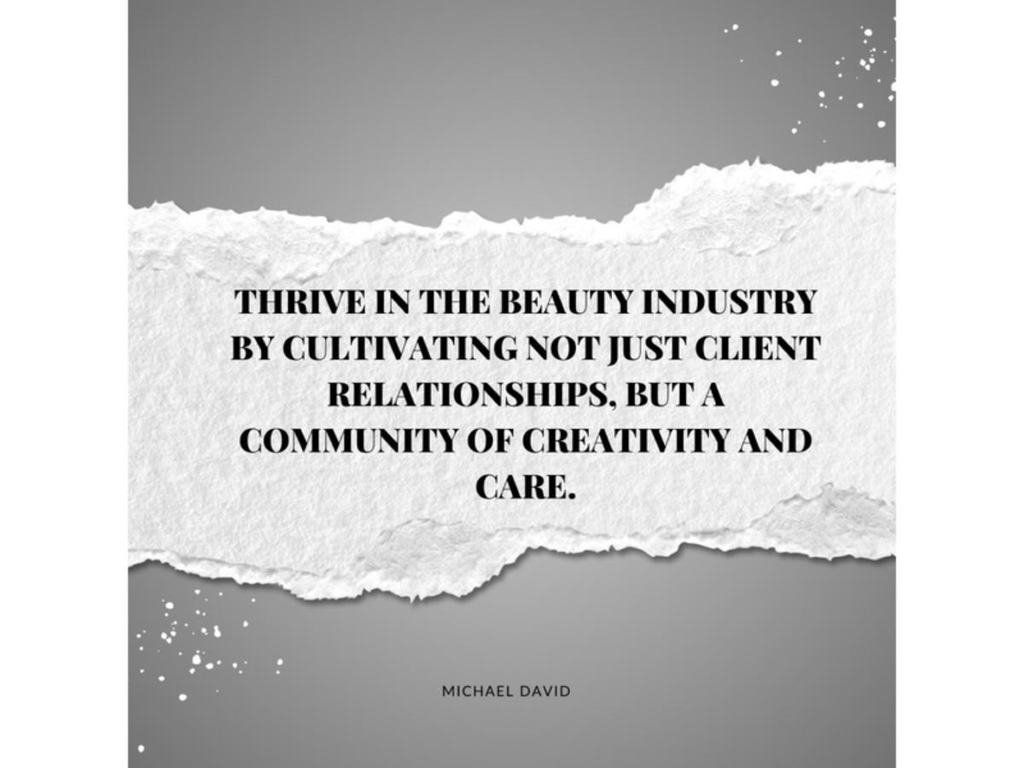

1. James Dyson, “How Olaplex Revolutionized Hair Repair,” 2020, accessed March 8, 2025, https://www.olahpex.com. ↩︎
2. Mielle Organics, “Our Story: Celebrating Natural Beauty,” 2021, accessed March 8, 2025, https://www.mielleorganics.com. ↩︎
3. Project Management Institute, *A Guide to the Project Management Body of Knowledge (PMBOK® Guide)* (Newtown Square, PA: Project Management Institute, 2017). ↩︎
4. U.S. Occupational Safety and Health Administration, “Ergonomics in the Workplace,” 2020, accessed March 8, 2025, https://www.osha.gov/ergonomics. ↩︎
5. Harvard T.H. Chan School of Public Health, “The Nutrition Source,” 2022, accessed March 8, 2025, https://www.hsph.harvard.edu/nutritionsource. ↩︎
6. Jon Kabat‑Zinn, *Full Catastrophe Living: Using the Wisdom of Your Body and Mind to Face Stress, Pain, and Illness* (Delta, 1990). ↩︎
7. Intuit, “QuickBooks Online,” 2023, accessed March 8, 2025, https://quickbooks.intuit.com. ↩︎

XI

Advanced

Digital

Strategies

for

Freelance

Hairstylists

> A good name is more desirable than great riches; to be esteemed is better than silver or gold.

— **— Proverbs 22:1**

## Introduction

**V**isualize yourself standing in your salon, scissors poised, ready to craft a masterpiece that transcends boundaries. But instead of an audience of one, you suddenly have the eyes of the world upon you. The mirror before you transforms into a shimmering digital portal, reflecting not just your client’s expectant face but the eager gazes of thousands—no, millions—of potential admirers, clients, and collaborators. This is the power of digital amplification, a game-changing revelation that’s rewriting the rules of success for freelance hairstylists.

In today’s ever-evolving landscape, where creativity and commerce intertwine, digital amplification has become the spotlight that can make your artistry shine on a global stage. No longer confined to the four walls of a salon or limited by local word-of-mouth, hairstylists now have access to virtual platforms where influence can flourish, and business can thrive beyond traditional expectations. The rise of digital technologies has unleashed a transformative wave, reshaping how we connect, communicate, and consume. For hairstylists, this digital renaissance opens unprecedented opportunities to showcase talent, build brand identity, and engage with a vast, untapped audience.

From the captivating world of social media to the boundless potential of e-commerce, from compelling content creation to virtual consultations, the digital realm offers a treasure trove of tools and strategies. With these at your fingertips, you can amplify your reach, establish authority, and create a sustainable, scalable business model that defies traditional boundaries. But let’s be honest—navigating this digital landscape can feel like stepping into a foreign country without a map. It’s overwhelming, especially if you’re more comfortable wielding shears than smartphones.

This new frontier demands a fresh set of skills, a strategic mindset, and the courage to adapt and innovate in the face of constant change. It calls for a paradigm shift, urging you to evolve from solo artist to savvy entrepreneur, leveraging technology to create value, build community, and drive growth in ways you may never have thought possible.

In this chapter, we’ll embark on an exhilarating journey through the world of advanced digital strategies tailored for freelance hairstylists. We’ll explore how to harness the power of digital amplification and thrive in this era of boundless possibility. From elevating authority through strategic partnerships to building a vibrant community through interactive engagement, from showcasing operational integrity to fostering diversity and inclusion in digital spaces, we’ll dive into the principles and practices that can transform your freelance business into a digital powerhouse.

So, whether you’re a seasoned pro with decades of experience or a newcomer ready to make your mark, it’s time to embrace the game-changing potential of digital amplification. The world is waiting with bated breath to discover your unique artistry, your compelling story, and the transformative impact only you can make. Are you ready to step into the spotlight and claim your space in the digital arena? Let’s explore how you can create a legacy that transcends time and place, one click, one post, one connection at a time.

## Personal Anecdote: Digital Hesitation to Online Engagement

When I first considered putting my work online, I was filled with digital hesitation. I knew platforms like Instagram and Facebook had the potential to elevate my business, and I even eyed TikTok for its creative reach—but I wasn’t sure how to start. My early posts were sporadic and lacked the effort I now know they deserved. However, a small breakthrough came when I received a supportive comment on one of my photos, sparking the realization that even minimal online engagement could open new doors. Although I haven’t yet dedicated as much time to my socials as I should, embracing these digital platforms is slowly reshaping my business, and this book is part of my journey toward disciplined, authentic online engagement.

**Key Insight:** Even small steps into digital engagement can yield meaningful results and build confidence for future growth in online brand building.

## I. Digital Marketing Foundations for Every Stylist

Before diving into advanced strategies, let’s establish a solid foundation for your digital journey. No matter your current comfort level with technology, these basics will help you take those first crucial steps with confidence.

### Digital Readiness Assessment: Where Are You Now?

Understanding your starting point is essential for creating a digital strategy that works for you. Consider which of these profiles best describes your current digital comfort level:

- **⭐ Digital Newcomer:** You have personal social media accounts but haven’t used them much professionally. The idea of creating content for business purposes feels intimidating.
- **⭐⭐ Digital Explorer:** You’ve posted some work photos and maybe experimented with Stories or Reels. You understand the basics but haven’t developed a consistent strategy.
- **⭐⭐⭐ Digital Enthusiast:** You regularly post content across multiple platforms and have started to see business results. You’re ready to refine your approach and explore advanced techniques.

Throughout this chapter, you’ll see these star ratings next to strategies and techniques, helping you identify which approaches are appropriate for your current level while showing a path for growth.

### Platform Selection: Where Should You Begin?

While there are numerous digital platforms, starting with one or two that best showcase your work will help you build confidence and consistency before expanding further.

#### ⭐ Instagram Basics

Visual-focused and perfect for hairstylists, Instagram allows you to showcase your work through photos, videos, Stories, and Reels.

**First Steps:**

- Create a business account (convert your personal account in Settings)
- Craft a clear, professional bio that mentions your location and specialty
- Post 3-5 of your best work photos with simple captions
- Follow other stylists and hair brands for inspiration

#### ⭐ Facebook for Business

Excellent for connecting with your local community, showcasing reviews, and managing appointments.

**First Steps:**

- Create a Business Page (separate from your personal profile)
- Complete all business information, including services and hours
- Post a welcome message and 2-3 examples of your work
- Invite friends and family to like your page

#### ⭐⭐ TikTok for Creative Reach

Perfect for short-form video content that showcases your personality and techniques.

**First Steps:**

- Create a professional account
- Watch popular hairstyling videos to understand the platform’s style
- Film a simple before-and-after transformation
- Experiment with trending sounds and hashtags

Remember, consistency matters more than perfection. Start small, post regularly, and build from there. Even one quality post per week is better than sporadic activity or overwhelm.

## II. Elevating Authority Through Strategic Value-Adding Partnerships

In the vast digital landscape, your voice can sometimes get lost in the noise. But what if you could amplify your message by joining forces with other brilliant minds? This is where strategic value-adding partnerships come into play. These collaborations offer a powerful way to elevate your authority and expand your reach exponentially.

### Identifying Complementary Experts and Brand Collaborators ⭐⭐

Imagine your expertise as a beautiful melody. Now, picture how much richer and more compelling that melody becomes when harmonized with complementary voices. That’s the magic of identifying the right partners—experts and brands that resonate with your values and enhance your offerings. Think beyond the obvious. Collaborating with other hairstylists can be valuable, but don’t limit yourself. Consider working with makeup artists who can complete a cohesive look, fashion designers who bring your hairstyles to life on the runway, or lifestyle bloggers who incorporate your hair care tips into a broader beauty regimen. Even professionals from adjacent fields, like nutrition or wellness, can create exciting crossover opportunities, allowing you to explore connections between hair health and overall well-being.

**Actionable Steps:**

1. Create a “Dream Team” List: Identify potential partners whose work complements yours and aligns with your brand vision. Think broadly across beauty, fashion, and wellness sectors.
2. Research Their Online Presence: Go beyond follower counts. Look at their engagement levels, the quality of their interactions, and how their audience responds to their content. This research will help you understand who aligns with your brand.
3. Craft Personalized Outreach Messages: When reaching out, show genuine interest in their work by referencing specific projects or content they’ve created. Propose collaboration ideas that are mutually exciting and beneficial.

### Co-Creating Educational Content Benefiting Shared Audiences ⭐⭐

Once you’ve found the perfect partners, it’s time to create something meaningful together. Co-created educational content can be a golden opportunity to establish shared authority and provide immense value to both of your audiences. Picture hosting a video series with a renowned colorist where you demonstrate the season’s hottest hair color trends. Or imagine collaborating with a trichologist on a podcast exploring the science of healthy hair. The possibilities are as limitless as your creativity.

**Actionable Steps:**

1. Brainstorm Content Ideas: Collaborate with your partners to generate content ideas that make both of you excited. Think about the questions and interests your shared audiences have.
2. Outline a Content Creation Plan: Each partner should play to their strengths. For instance, if you’re great at live demonstrations and your partner excels at explaining complex concepts, structure your content to showcase these talents.
3. Develop a Robust Distribution Strategy: Choose the right formats and platforms for reaching your audience—whether that’s a live webinar, a series of blog posts, or a downloadable e-book. Ensure that your content distribution maximizes its reach and impact.

### Establishing Compliance Guidelines to Maintain Credibility ⭐⭐⭐

As exciting as partnerships can be, protecting your hard-earned reputation is crucial. Clear compliance guidelines act as a safeguard, ensuring that all collaborations align with your values and maintain the trust you’ve built with your audience. Think of these guidelines as the foundation of a beautiful building—they might not be visible to the casual observer, but they’re essential to the integrity of everything you create together.

**Actionable Steps:**

1. Educate Yourself on Industry Regulations: Understand the rules around sponsored content, affiliate marketing, and influencer partnerships. Knowledge is power, and in this case, it’s also protection.
2. Craft Compliance Guidelines: Develop a set of clear guidelines for your partnerships. Define everything from the types of products you’re willing to promote to how collaborations are disclosed to your audience.
3. Communicate Guidelines Clearly to Potential Partners: Make sure all partners are aware of your guidelines before collaboration begins. This transparency fosters an ethical partnership that your audience will respect and trust.

## Case Study: Transformative Client Documentation Success

**Real-Life Example: Digital Newcomer’s First Video Success**

**Challenge:** A freelance stylist struggled with online visibility and client engagement, feeling uncertain about sharing work on social media platforms.

**Solution:** The stylist documented a subtle yet meaningful transformation for a client transitioning to a more natural, low-maintenance style. They recorded the process and shared before-and-after content on Instagram, experimenting with TikTok clips despite initial hesitation.

**Outcome:** While engagement wasn’t overwhelming, the stylist received encouraging messages and several new client inquiries, demonstrating the potential of authentic online content sharing.

**Lessons Learned:** Even modest online success can serve as a foundation for growth, building confidence and motivating continued development of digital storytelling skills.

## III. Building Community Through Interactive Digital Engagement

In the digital age, success isn’t just about broadcasting your message—it’s about fostering genuine connections and building a thriving community around your brand. Interactive digital engagement transforms passive followers into passionate advocates for your work.

### Implementing Live Discussion Forums and User-Generated Content Campaigns ⭐⭐

Imagine your digital platform not as a stage where you perform, but as a vibrant town square where ideas are exchanged, stories are shared, and creativity flourishes. This is the power of live discussion forums and user-generated content campaigns. Picture hosting a weekly live Q&A session where you address your followers’ most pressing hair care concerns in real time. Or launch a challenge that invites your audience to showcase their own hair transformations inspired by your techniques. These interactive initiatives don’t just engage your audience—they make them active participants in your brand story.

**Actionable Steps:**

1. Identify Active Platforms: Choose platforms where your audience is most engaged, like Instagram Live, Facebook Groups, or forums on your website.
2. Create a Content Calendar: Schedule regular interactive events such as Q&A sessions, live tutorials, or content challenges to build consistency and anticipation.
3. Develop Clear Guidelines: Provide instructions and prompts for user-generated content campaigns. The easier you make it for people to participate, the more likely they are to join in.

### Amplifying Client Transformations and Success Stories ⭐

Every client transformation is a testament to your skill and artistry. By amplifying these success stories, you’re not only showcasing your work—you’re inspiring others and building social proof that can attract new clients. Imagine creating a monthly feature that spotlights a dramatic client transformation, complete with before-and-after photos, a video of the process, and a testimonial on how the new look has boosted their confidence. Real-life success stories resonate deeply and create an emotional connection with your audience.

**Actionable Steps:**

1. Develop a System for Capturing Transformations: Set up professional before-and-after photoshoots and record video testimonials. Ensure you have client consent to share their stories.
2. Create a Consistent Presentation Format: Design a visually appealing template for showcasing transformations across your digital channels, ensuring brand consistency.
3. Encourage Client Participation: Motivate clients to share their own stories and experiences. This not only showcases your work but also fosters a sense of community and trust.

### Hosting In-Person Gatherings for Face-to-Face Connection Building ⭐⭐

While digital engagement is powerful, there’s an undeniable magic in face-to-face connections. By bridging the digital and physical worlds through in-person gatherings, you create deeper, more meaningful relationships with your community. Envision hosting a hands-on workshop where your online followers can learn your signature techniques in person. Or imagine a glamorous event where your digital community comes together to celebrate hair artistry, complete with live demonstrations, networking opportunities, and perhaps even a charity component.

**Actionable Steps:**

1. Plan Meaningful Events: Organize workshops, seminars, or social gatherings that provide unique value and align with your brand values.
2. Promote Through Digital Channels: Use social media platforms, email lists, and website updates to announce and generate excitement for these events.
3. Create Engaging Experiences: Ensure events offer interactive experiences like live demonstrations, networking opportunities, and client testimonials, giving attendees memorable takeaways and encouraging them to share their experiences online.

## IV. Showcasing Operational Integrity and Social Responsibility

In today’s conscious consumer landscape, your skills and creativity are just part of the equation. Increasingly, clients and followers want to support businesses that align with their values and contribute positively to the world. This is where showcasing your operational integrity and social responsibility becomes not just an ethical choice but a powerful business strategy.

### Transparently Reporting Eco-Friendly and Ethical Business Practices ⭐⭐

Imagine your salon as not just a place of beauty but as a beacon of sustainability. By transparently sharing your eco-friendly and ethical practices, you’re not only making a positive impact on the planet—you’re also building trust and loyalty among environmentally conscious clients. Picture creating a beautifully designed infographic that illustrates your salon’s journey toward sustainability. It could highlight your switch to energy-efficient equipment, partnerships with eco-friendly product lines, and reduced water usage through innovative techniques. Visual storytelling like this not only educates your audience but also inspires them to make more conscious choices in their own lives.

**Actionable Steps:**

1. Conduct a Thorough Audit: Evaluate your current business practices to identify where you excel in sustainability and where there’s room for improvement.
2. Set Clear, Measurable Goals: Establish specific targets for enhancing your eco-friendly practices, such as reducing plastic waste by 30% or transitioning to renewable energy within the year.
3. Create Compelling Content: Share your sustainability journey through blog posts, social media updates, and infographics. Keep your audience informed of your progress and celebrate milestones along the way.

### Diversifying Visual Representations Across Content and Messaging ⭐

Your digital presence is a powerful platform for championing diversity and inclusion. By consciously diversifying the visual representations in your content, you’re not just expanding your potential client base—you’re contributing to a more inclusive beauty standard. Imagine a social media feed that celebrates the beauty of all hair types, textures, and styles. Picture content that showcases a diverse range of models representing various ages, ethnicities, body types, and gender expressions. This inclusive approach sends a powerful message that your artistry is for everyone, fostering a sense of belonging among your audience.

**Actionable Steps:**

1. Audit Your Current Visual Content: Review your existing content to assess the diversity of models, styles, and cultural representations. Identify gaps and areas for improvement.
2. Develop Inclusive Content Guidelines: Create guidelines to ensure diverse representation in all your visual content. This can include choosing models with different hair types, skin tones, and backgrounds.
3. Collaborate with Diverse Models and Influencers: Partner with individuals who represent a wide range of identities and experiences. Not only does this broaden your appeal, but it also enriches your content and demonstrates your commitment to inclusivity.

### Collaborating with Accessibility Advocates on Inclusive Initiatives ⭐⭐⭐

True inclusivity extends beyond visual representation to ensuring that your services and digital content are accessible to everyone, including those with disabilities. By collaborating with accessibility advocates, you’re not only expanding your reach—you’re leading the way toward a more equitable beauty industry. Imagine partnering with a hearing-impaired beauty influencer to create tutorials that incorporate sign language. Or envision working with a disability rights organization to make your salon more accessible, then sharing that journey to inspire other businesses. These initiatives demonstrate your commitment to inclusivity in action.

**Actionable Steps:**

1. Research and Connect with Accessibility Advocates: Identify influencers and organizations that focus on accessibility in the beauty industry, and reach out to explore collaboration opportunities.
2. Propose Meaningful Collaborations: Develop projects that address accessibility needs, such as creating inclusive content or redesigning your salon space to be more accessible.
3. Share Your Journey: Document and share the process and outcomes of these collaborations on your digital platforms. Use this opportunity to educate your audience about accessibility and its importance in the beauty industry.

## Personal Anecdote: Planning for Inclusive Content Creation

I’ve noticed a significant gap in quality content for underserved hair types and textures, and I’m planning to change that. Although I haven’t yet produced my own tutorial series, I’m excited about creating content specifically tailored to my community’s needs—focusing on natural textures and culturally unique styles. I envision developing step-by-step videos and detailed guides that not only educate but also celebrate our heritage. I’m still in the planning phase, and while I’m not yet reaping the rewards of this effort, I believe that by consistently investing in inclusive content, I’ll eventually connect with an audience that truly values representation and expertise.

**Key Insight:** Recognizing gaps in representation and making intentional plans to address them, even in early stages, demonstrates authentic commitment to inclusive content creation.

## V. Fostering Diversity and Inclusion in Digital Spaces

In our beautifully diverse world, the digital landscape offers an unprecedented opportunity to celebrate and amplify a wide range of human experiences. As a hairstylist, you have a unique platform to champion diversity and inclusion, not just in the styles you create but in the digital spaces you cultivate. Let’s explore how you can foster an environment of true inclusivity that resonates with a global audience.

### Launching Inclusive Hashtag Campaigns Encouraging Diverse Participation ⭐⭐

Imagine sparking a global conversation about beauty that transcends boundaries and celebrates every unique strand of hair. This is the power of an inclusive hashtag campaign. It’s not just about trending; it’s about creating a movement that empowers individuals to share their stories and see themselves represented in the beauty narrative. Picture launching a campaign like #EveryStrandMatters or #BeautyBeyondBorders. Envision your feed transforming into a vibrant mosaic of diverse hair textures, styles, and cultural expressions. Each post becomes a testament to the inclusive community you’re building, inviting voices that have long been underrepresented in the beauty industry to take center stage.

**Actionable Steps:**

1. Brainstorm Meaningful Hashtags: Create hashtags that reflect your commitment to diversity and inclusion. The best hashtags are catchy, meaningful, and easy to remember.
2. Craft a Compelling Campaign Narrative: Explain the purpose behind your hashtag and why it matters. Share your personal story and the mission driving the campaign.
3. Develop Participation Prompts: Encourage your audience to engage by providing specific prompts, such as sharing their hair transformation stories, showcasing traditional hairstyles, or participating in themed styling challenges.

### Creating Tutorials Catering to Unique Cultural Textures, Styles, and Needs ⭐

Your expertise as a hairstylist is a powerful tool for education and empowerment. By creating tutorials that cater to a wide range of hair types and cultural styles, you’re not just sharing techniques—you’re validating and celebrating diverse beauty standards. Imagine creating a series called “Global Hair Journeys,” where each tutorial spotlights a different cultural hairstyle or technique. Picture the excitement of your audience as they see their unique hair needs addressed with expertise and respect. From intricate braiding techniques of West Africa to the art of styling textured hair for humid climates, each tutorial becomes a bridge of understanding and appreciation.

**Actionable Steps:**

1. Conduct In-Depth Research: Study various cultural hairstyles and techniques to ensure authenticity and respect in your tutorials. Consult with cultural experts if necessary.
2. Develop a Diverse Content Calendar: Plan a schedule that covers a wide range of hair types, textures, and cultural styles. Aim to include content that addresses underserved communities.
3. Share Cultural Significance: When creating tutorials, include the history and cultural importance of the styles you’re teaching. This adds depth and context to your content, enhancing its value and relatability.

### Spotlighting Underrepresented Voices Through Influencer Partnerships ⭐⭐⭐

Your platform has the power to amplify voices that have long been marginalized in the beauty industry. By partnering with influencers from diverse backgrounds, you’re not just expanding your reach—you’re enriching the conversation and challenging the status quo. Envision a collaboration series called “Voices of Beauty” where you team up with influencers from various cultural backgrounds, body types, or gender identities. Picture the powerful impact of showcasing a plus-size beauty blogger’s hair transformation or collaborating with a trans influencer to discuss inclusive salon experiences. These partnerships do more than create content—they create change.

**Actionable Steps:**

1. Identify Authentic Influencers: Look for influencers who genuinely represent diverse communities and whose values align with your brand. Prioritize authenticity over follower counts.
2. Develop Collaborative Content: Work with influencers to create content that highlights their unique perspectives and experiences. This could include joint tutorials, interviews, or feature posts.
3. Center Influencer Voices: Ensure that the influencer’s voice and story are at the forefront of the collaboration. Use your platform to elevate their message and provide context for your audience about the importance of diverse representation.

## Personal Anecdote: Learning from Automation Challenges

Managing client communication used to be a chaotic, time-consuming task for me. After several challenging weeks juggling appointments and follow-ups manually, I decided to experiment with automation tools. I started with ConvertKit for email sequences and ManyChat for text messaging. The initial setup was far from seamless—I encountered a steep learning curve and technical challenges along the way. However, even in these early stages, I began to see small wins: automated reminders, personalized follow-ups, and a more organized communication flow. Though I’m still refining my processes, these tools have already started to save me time and enhance my relationships with clients, proving that embracing technology can lead to long-term growth.

**Key Insight:** Technology adoption involves a learning curve, but persistence through initial challenges can yield meaningful improvements in client communication and business efficiency.

## VI. Leveraging Automation Technology for Exponential Reach and Growth

In the fast-paced digital world, working smarter—not just harder—is the key to scaling your impact and reaching new heights. Automation technology offers a powerful way to extend your reach, nurture client relationships, and drive growth—all while freeing up your time to focus on what you do best: creating beautiful hair.

### Implementing Multi-Channel Email and Text Nurturing Sequences ⭐⭐

Imagine having a tireless assistant who knows exactly what to say to your clients, when to say it, and through which channel—24 hours a day, 7 days a week. This is the magic of multi-channel nurturing sequences. By crafting personalized, automated messages that guide potential clients from curiosity to booking, you’re creating a seamless journey that feels both personal and attentive. Picture a new client discovering your Instagram page; within moments, they receive a warm welcome email with your top hair care tips. A few days later, a text message arrives with an exclusive offer for first-time clients. Each interaction builds trust and interest, moving them closer to becoming a loyal client.

**Actionable Steps:**

1. Map Out the Client Journey: Define the key touchpoints from initial contact to repeat bookings. Identify where automated messages can provide value and drive conversions.
2. Craft Engaging Templates: Develop a series of email and text message templates that reflect your brand voice and provide genuine value, focusing on educational content, exclusive offers, and personalized recommendations.
3. Choose a Robust CRM Platform: Invest in a marketing automation platform like HubSpot, Mailchimp, or ActiveCampaign that can handle multi-channel communication and track client interactions.

### Optimizing Content Strategy and Paid Advertising Using Analytics Insights ⭐⭐⭐

In the vast sea of digital content, standing out requires more than just creativity—it demands strategic precision. By harnessing the power of analytics, you can fine-tune your content and advertising efforts to resonate deeply with your target audience. Imagine having a crystal ball that reveals exactly what type of content your audience craves, which visuals stop them mid-scroll, and what messaging compels them to take action. This is the power of data-driven optimization. Picture the satisfaction of watching your engagement rates soar as you refine your approach based on real insights, not guesswork.

**Actionable Steps:**

1. Set Up Comprehensive Tracking: Use tools like Google Analytics, Facebook Insights, and Instagram Analytics to monitor user behavior, engagement rates, and conversion metrics.
2. Analyze Performance Data: Regularly review your analytics dashboards to identify patterns and trends in your best-performing content and ads. Look for insights on what resonates most with your audience.
3. Implement A/B Testing: Experiment with different content formats, headlines, visuals, and calls-to-action to determine what drives the highest engagement and conversion rates. Use the results to continuously refine your strategy.

### Investing in Specialist Support for Technical Funnel Buildouts ⭐⭐⭐

As your digital presence grows, so does the complexity of managing your online ecosystem. There comes a point where investing in specialist support isn’t just helpful—it’s transformative. A well-crafted, technically sound funnel can be the difference between steady growth and exponential success. Envision a sleek, seamless funnel that guides potential clients effortlessly from their first interaction with your brand to becoming enthusiastic, repeat customers. Imagine the peace of mind that comes from knowing your digital infrastructure is robust, scalable, and working tirelessly to grow your business, even while you sleep.

**Actionable Steps:**

1. Identify Funnel Needs: Determine which areas of your digital strategy would benefit most from advanced funnel buildouts, such as lead generation, client onboarding, or product sales.
2. Research and Vet Specialists: Look for funnel specialists or agencies with a proven track record in the beauty industry. Review their portfolios and client testimonials to ensure they can deliver the results you seek.
3. Collaborate on Funnel Design: Work closely with your chosen specialist to design a funnel that aligns with your brand goals and provides a seamless client experience. Provide them with all necessary brand assets and insights to create a tailored solution.
4. Implement and Monitor: Launch your new funnel and monitor its performance closely. Use analytics to track its effectiveness and make adjustments as needed to optimize results.

## Actionable Steps

### Digital Foundation Building

1. **Assess Your Digital Readiness:** Use the three-level system to identify your starting point and choose appropriate strategies.
2. **Select Primary Platforms:** Focus on 1-2 platforms initially to build consistency before expanding.
3. **Create Content Calendar:** Plan regular posting schedule that balances quality with achievable frequency.

### Strategic Partnership Development

1. **Identify Collaboration Opportunities:** Research complementary professionals whose values align with your brand.
2. **Develop Outreach Strategy:** Craft personalized messages that propose mutually beneficial partnerships.
3. **Establish Clear Guidelines:** Create compliance standards that protect your reputation and audience trust.

### Community Engagement Enhancement

1. **Implement Interactive Features:** Host live sessions, Q&As, and user-generated content campaigns.
2. **Document Client Stories:** Systematically capture and share transformation stories with proper consent.
3. **Bridge Digital and Physical:** Plan in-person events that strengthen online community connections.

### Diversity and Inclusion Integration

1. **Audit Current Content:** Review existing materials for representation gaps and improvement opportunities.
2. **Create Inclusive Campaigns:** Launch hashtag initiatives that celebrate diverse hair types and cultural expressions.
3. **Partner with Underrepresented Voices:** Collaborate with influencers from diverse backgrounds to amplify marginalized perspectives.

### Technology and Automation Implementation

1. **Map Client Journey:** Identify key touchpoints where automation can enhance communication and engagement.
2. **Set Up Analytics Tracking:** Use comprehensive tools to monitor performance and optimize content strategy.
3. **Consider Professional Support:** Evaluate when investing in specialist assistance for complex funnel development makes sense.

## Quiz

### Question 1

Which digital strategy is most appropriate for a stylist who has never used social media professionally before?

a) Launching a multi-platform hashtag campaign b) Creating a basic Instagram business account with 3-5 portfolio images c) Implementing automated email marketing sequences d) Investing in paid Facebook and Instagram advertising

### Question 2

What is a key benefit of co-creating educational content with complementary experts?

a) It eliminates the need for your own original content b) It allows you to charge higher prices for your services c) It expands your reach to new audiences and enhances your credibility d) It guarantees viral content on social media platforms

### Question 3

When creating tutorials for diverse hair types and textures, what should you include beyond technique demonstrations?

a) Criticisms of other stylists’ approaches b) Cultural context and historical significance of the styles c) Promises of quick and easy results for everyone d) Expensive product recommendations

### Question 4

Which approach to automation is most effective for building client relationships?

a) Sending the same generic message to all clients b) Creating personalized, multi-channel nurturing sequences c) Only using automation for appointment reminders d) Avoiding automation entirely to maintain personal touch

## Worksheet

### Digital Strategy Planning Worksheet

**Digital Readiness Assessment**

Check the statement that best describes your current comfort level:

⬜ **Digital Newcomer:** I have personal social accounts but haven’t used them professionally. ⬜ **Digital Explorer:** I’ve posted some work but don’t have a consistent strategy. ⬜ **Digital Enthusiast:** I regularly post across platforms and am ready for advanced techniques.

**Platform Selection and Goals**

Based on your assessment, select 1-2 platforms to focus on first:

**Platform 1:** ________________________________

**Three specific goals for this platform:**

**Platform 2 (optional):** ________________________________

**Three specific goals for this platform:**

**Content Calendar Planning**

**Weekly content plan:**

**Monthly feature ideas:**

**Seasonal content:**

**Strategic Partnership Development**

**List five potential complementary partners:**

**Collaboration ideas for your top choice:**

**Diversity and Inclusion Strategy**

**How will you ensure diverse representation in your content?**

**Types of hair textures and styles you’ll showcase:**

**Ideas for inclusive hashtag campaigns:**

**Digital Automation Planning**

**Client communications you could automate:**

**Tools you’ll consider implementing:**

**90-Day Digital Action Plan**

**Week 1-4 Focus:**

**Week 5-8 Focus:**

**Week 9-12 Focus:**

**Success metrics:**

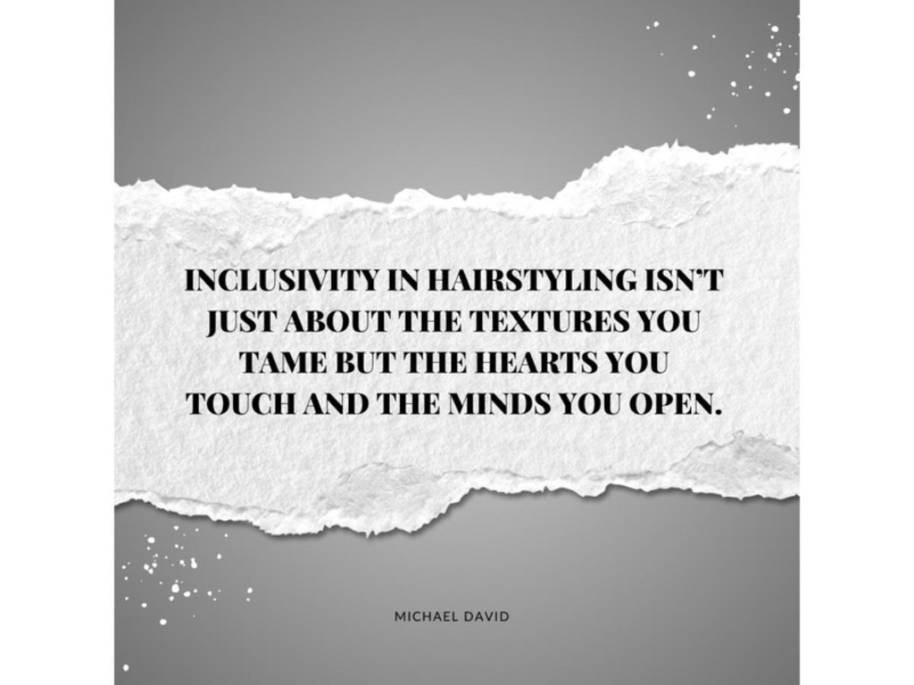

XII

Financial

Wisdom

Building

Sustainable

Ventures

> A friend loves at all times, and a brother is born for a time of adversity.

— **— Proverbs 17:17**

## Introduction

**S**tep into the quiet of your salon, its mirrors and chairs empty, as you reflect on the journey of building sustainable ventures. You sit at your desk, surrounded by invoices, bank statements, and notes scribbled hastily between appointments. As the clock ticks past midnight, you’re not thinking about the latest hair trends or color techniques—you’re focused on the daunting question of financial stability. Like countless freelance hairstylists, you’re confronting the dual challenges of building a career in artistry while navigating the world of business, finance, and personal resilience.

For many stylists, this quiet battle goes unnoticed. Despite your undeniable talent and commitment, the cycle of fluctuating income, mounting expenses, and the absence of a financial plan can feel overwhelming. Even industry icons such as Miko Branch, co-founder of the legendary Miss Jessie’s, and Johnny Wright, celebrity hairstylist and product line creator, have faced this reality. Miko Branch took her family’s haircare wisdom and transformed it into a multimillion-dollar brand, but it didn’t happen without financial missteps and critical lessons learned. These trailblazers understood that to build a sustainable business, they needed not only creative talent but also financial wisdom—an asset every bit as important as skill with a pair of scissors.

This chapter will guide you on that journey, providing a roadmap for building financial stability, growth, and ultimately, freedom. By diving into the principles of budgeting, accurate financial tracking, pricing strategies, and income diversification, you’ll gain the skills needed to elevate your artistry into a sustainable business venture. You’ll learn how to utilize digital tools, avoid common pitfalls, and even explore new revenue streams—from online tutorials to product licensing—that can help you thrive.

Imagine what financial confidence could look like for you: no more sleepless nights or moments of hesitation when ordering new supplies. Picture the freedom to expand your brand, save for the future, and invest in your skills. This is not a distant dream—it’s an achievable reality, and it starts with adopting the mindset and practices of a financially savvy entrepreneur.

Are you ready to transform your approach to money and build a venture that not only sustains you but allows you to flourish? Let’s dive into the essential tools and strategies to ensure that your passion for hairstyling fuels a stable, abundant, and lasting career.

## Personal Anecdote: From Financial Chaos to Structured Success

When I first began my career as a freelance hairstylist, I was caught in a whirlwind of financial uncertainty. Back then, I struggled with inconsistent income, poor record-keeping, and never really knowing whether I’d have enough to cover my rent and supplies at month’s end. I vividly remember one hectic season: after a string of overbooked days followed by a sudden lull, I found myself scrambling to pay bills and wondering if I could continue in the business.

It was during one of those nail-biting evenings—sitting at my cluttered desk with a pile of receipts and handwritten notes—that I realized something had to change. I knew I needed a system that would not only track every dollar but also help me plan for leaner periods. That moment of clarity transformed my approach to business finances. I invested time in learning about modern bookkeeping techniques and gradually, by implementing proper systems, my financial chaos gave way to stability. Today, I have structured processes in place that allow me to forecast my cash flow accurately, set aside funds for emergencies, and even reinvest in my growth—all of which have been game changers for my career.

**Key Insight:** Financial chaos can be transformed into stability through systematic implementation of proper tracking and planning systems, creating the foundation for sustainable business growth.

## I. Laying the Foundation: Accurate Financial Tracking Disciplines

Building a financially sustainable hairstyling business starts with disciplined financial tracking. In today’s fast-paced digital world, even small independent businesses have the tools to set up comprehensive financial systems. Tracking each expense, every sale, and understanding the broader financial health of your venture are all critical to gaining financial control. Some of the most successful brands in the beauty industry, such as SheaMoisture and Camille Rose, attribute their financial resilience to disciplined tracking systems that reveal opportunities for smarter spending and growth.

For freelance hairstylists, these principles are just as relevant. Implementing systems for automated bookkeeping, scheduled reviews, and cash flow analyses can give you an edge in managing not just the day-to-day of your finances but also planning for long-term stability.

### Implementing Cloud-Based Bookkeeping Automation Software

For hairstylists, balancing the creative demands of the job with bookkeeping tasks is no small feat. Cloud-based bookkeeping software, like QuickBooks and Xero, automates many of these tasks, offering tools for recording, categorizing, and analyzing transactions with a few clicks. Madam C.J. Walker Beauty Culture, one of the most storied black-owned beauty brands, credits much of its early growth to a strategic, organized approach to finances, allowing Madam Walker herself to reinvest in her business and scale operations.

With software such as FreshBooks, hairstylists can gain a holistic view of their finances, including income, expenses, and profit margins, from anywhere at any time. For hairstylists managing both client bookings and product sales, tools like Wave offer an accessible, cloud-based option that integrates sales data directly into bookkeeping.

**Actionable Steps:**

1. **Research Cloud-Based Options:** Compare features, pricing, and integrations of tools like QuickBooks, Xero, and FreshBooks. Evaluate which option fits best with the specific needs of your business.
2. **Customize Your Accounts:** Set up a chart of accounts to reflect your expenses and income streams, from in-salon services to product sales.
3. **Commit to Weekly Check-Ins:** Schedule time each week to categorize transactions, reconcile accounts, and ensure accuracy. This discipline saves time and minimizes the risk of end-of-year surprises.

### Conducting Quarterly Cash Flow Analyses for Strategic Decision-Making

Beyond daily tracking, regular cash flow analyses offer critical insights into the patterns and health of your business’s finances. Many successful salons and beauty brands perform these reviews quarterly to better understand how resources are allocated and to make timely adjustments. Bronner Bros., an Atlanta-based black-owned beauty brand, reviews its cash flow seasonally to align with major beauty events and adjust for slower periods.

For freelance hairstylists, a quarterly analysis reveals trends, like peak appointment times or higher supply costs, helping you make strategic adjustments to spending and saving. This practice enables stylists to avoid cash shortages during slower periods and confidently invest in growth opportunities when business is strong.

**Actionable Steps:**

1. **Set Quarterly Review Dates:** Block out time at the end of each quarter to review income, expenses, and cash reserves.
2. **Analyze Trends and Set Goals:** Identify service trends (like high-demand months) and allocate savings for quieter times.
3. **Plan Actionable Adjustments:** Adjust budgets, consider cutting discretionary expenses, or reinvest in areas of high demand.

### Diversifying Income Streams Through Online and eCommerce Expansions

For a hairstylist, relying solely on in-person services can mean financial vulnerability. Expanding into online and eCommerce offerings is a key way to build additional income channels that can make your business more resilient. For instance, brands like The Lip Bar by Melissa Butler evolved from a product-focused company into a robust, diversified eCommerce powerhouse. By offering courses, products, or even branded merchandise, freelance stylists can establish a virtual presence that generates consistent revenue.

For example, MoKnowsHair, a stylist who shares hair care tutorials and collaborates with brands, has leveraged her online presence into a diversified business model. Freelance stylists can similarly create eCommerce sites, offer virtual consultations, or sell branded products to complement in-person services.

**Actionable Steps:**

1. **Brainstorm Virtual Offerings:** Identify online services that fit your expertise and client demand, such as consultations, downloadable guides, or tutorials.
2. **Choose the Right Platforms:** Platforms like Shopify for product sales, Teachable for courses, and Zoom for virtual consultations make it easy to reach clients.
3. **Launch and Promote:** Develop a marketing strategy that targets your existing client base and uses social media to draw in new customers.

## Personal Anecdote: Digital Transformation Learning Curve

Before I discovered cloud-based bookkeeping, my financial records were maintained in paper ledgers and scattered spreadsheets. This old-school method was not only time-consuming but also riddled with errors—I frequently lost receipts, duplicated entries, and found reconciling my books at month’s end to be an absolute nightmare.

I was initially skeptical when a fellow stylist recommended moving to a digital system. The idea of abandoning my trusted paper files felt overwhelming, and I was anxious about the learning curve. However, after researching and testing QuickBooks Online—a robust cloud-based accounting solution—I decided to give it a try. QuickBooks Online automated many routine tasks, such as categorizing transactions and reconciling bank feeds, all while allowing me to access real-time financial data from any device.

Within just a few months of switching, I noticed remarkable improvements. My bookkeeping became significantly more accurate, and the stress of manually entering data was greatly reduced. The time saved on administrative tasks meant I could focus more on creative work and enhancing my client services. Most importantly, the peace of mind that came from knowing my finances were consistently up-to-date transformed my overall business perspective. QuickBooks Online not only streamlined my financial management but also provided valuable insights through comprehensive dashboards and reports, which have been instrumental in guiding my growth as a freelance hairstylist.

**Key Insight:** Embracing digital financial tools, despite initial learning curves, can dramatically improve accuracy and efficiency while providing valuable business insights for strategic growth.

## II. Mastering Pricing for Sustainable Profitability and Perceived Value

Pricing is one of the most influential aspects of a hairstyling business. It shapes client perceptions, dictates profit margins, and establishes a foundation for sustainable growth. For freelance hairstylists, pricing decisions often feel like a balancing act: setting rates that reflect your expertise and cover your costs while remaining competitive. By analyzing local market rates, calculating service costs, and experimenting with optimized structures, you can design a pricing strategy that elevates both your brand and your profitability.

For example, brands like Rucker Roots, a black-owned haircare company, approach pricing not just as a figure to generate sales, but as a strategic choice that reflects their values, quality, and brand positioning in a crowded market. Their products, from shampoos to serums, are priced based on comprehensive cost calculations, including raw materials and distribution fees, allowing them to stand firm in their pricing without undercutting their value.

### Researching Local Market Rates and Competitor Pricing Strategies

The first step to setting sustainable prices is understanding what clients in your area are accustomed to paying. By studying local market rates and competitor pricing, you can pinpoint where your services align or diverge. This approach helps you establish a pricing benchmark that reflects your offerings’ value while identifying areas to differentiate yourself.

For instance, Camille Rose Naturals founder Janell Stephens initially started with handcrafted hair care and set her prices after a thorough analysis of her direct competition. Today, her pricing reflects both her brand’s premium status and the high-quality ingredients used. Freelance stylists can similarly use competitor insights to price services thoughtfully, establishing a strong market position.

**Actionable Steps:**

1. **Research Local Rates:** Conduct online searches, visit nearby salons, and look at other freelance stylist rates. Take note of differences in service packages, base prices, and unique offerings.
2. **Identify Your Unique Selling Points:** Decide what makes your services unique—whether it’s exclusive techniques, high-quality products, or an exceptional client experience—and factor these into your pricing.
3. **Set Your Price Benchmarks:** Create a pricing range that aligns with your skill level, service offerings, and brand positioning while meeting local expectations.

### Calculating Comprehensive Costs of Delivering Services for Markup Integrity

Accurate pricing starts with a clear understanding of your costs. Many small businesses, including stylists, often underprice their services because they overlook indirect costs. Companies like Mielle Organics excel in this area; they account for everything from raw materials to operational overhead to ensure profitability. Knowing your comprehensive costs—both direct and indirect—will enable you to price services in a way that respects your time, materials, and expertise.

As a stylist, your direct costs include everything from styling products to disposable gloves, while indirect costs may encompass rent, utilities, and insurance. By mapping these expenses, you gain a realistic view of what you need to charge to not only cover costs but also make a profit.

**Actionable Steps:**

1. **List Direct Service Costs:** Itemize all materials used during services, including shampoos, conditioners, styling products, and tools.
2. **Allocate Indirect Costs:** Include a portion of fixed expenses—like rent, utilities, and equipment costs—to each service. Estimate the time spent per client to determine how much of these costs apply.
3. **Establish Markup for Profit:** Calculate a markup that accounts for both cost recovery and profitability. This will be your “minimum viable rate” and should guide your pricing to ensure long-term sustainability.

## Case Study: Comprehensive Cost Analysis Success

**Real-Life Example: Service Package Pricing Transformation**

**Challenge:** A freelance stylist was offering a comprehensive service package including haircut, color treatment, and styling at below-market rates without accounting for all associated costs, resulting in painfully low profit margins.

**Solution:** The stylist conducted a thorough cost analysis, itemizing every expense from premium dyes to electricity for tools, consultation time, and workspace overhead. They recalculated pricing based on comprehensive cost understanding plus appropriate markup.

**Outcome:** After adjusting prices based on accurate cost calculations, profit margins improved significantly while clients responded positively to the transparent value proposition and service clarity.

**Lessons Learned:** Accurate cost calculation and proper pricing not only improve profitability but also enhance client perception of value and build reputation for quality and fair pricing.

### Testing Optimized Pricing Structures and Monitoring Revenue Impacts

Pricing isn’t static. As your skills, clientele, and market position evolve, so should your pricing structures. Testing various pricing options, such as packages, premium upgrades, and loyalty programs, can help you find the model that maximizes revenue while enhancing client value. Pattern Beauty by Tracee Ellis Ross, for instance, regularly experiments with product bundles and promotions, driving revenue and catering to diverse customer needs without compromising the brand’s value perception.

Experimenting with different pricing structures can also enhance perceived value, making clients feel like they’re receiving more for their investment. Offering bundled services, seasonal promotions, or loyalty discounts not only attracts new clients but strengthens relationships with regulars, encouraging repeat business and long-term loyalty.

**Actionable Steps:**

1. **Develop Tiered Options:** Introduce a range of pricing tiers, such as basic, premium, and luxury services, or consider package deals for regular clients.
2. **Track Key Metrics:** Monitor how each pricing structure affects revenue, client retention, and booking rates. Use tools like client management software to track conversion rates and average spend per visit.
3. **Analyze and Adjust:** Regularly review the data from pricing experiments. Discontinue structures that don’t contribute positively and expand offerings that generate both revenue and high client satisfaction.

## III. Financial Growth Stages: Strategic Planning for Every Career Phase

Just as a hairstyle evolves through different stages of development, your financial approach should adapt as your career grows. Understanding where you are in your professional journey allows you to focus on the right financial priorities, make appropriate investments, and scale strategically. Each stage brings unique challenges and opportunities that require different financial strategies.

### The Startup Phase: Essential Financial Foundations

When you’re first establishing your freelance hairstyling business, your primary financial focus should be on survival and stability. This phase is characterized by irregular income, limited client base, and the need to invest in essential equipment and skills. During this time, establishing fundamental financial habits is crucial.

**Financial Priorities:**

- **Separate Personal and Business Finances:** Open a dedicated business checking account and credit card to track business expenses separately from personal spending.
- **Build Emergency Funds:** Aim to save 3-6 months of essential expenses to cushion against slow periods and unexpected costs.
- **Minimal Fixed Costs:** Keep overhead low by sharing space, renting chairs, or operating as a mobile stylist before committing to high fixed expenses.
- **Track Every Penny:** Implement basic financial tracking using free or low-cost tools like Wave Accounting or Google Sheets.

**Smart Investments at This Stage:**

- Essential professional-grade tools and equipment
- Basic liability insurance
- Fundamental education to perfect core techniques
- Simple website or social media presence for client acquisition

**Growth Indicators:** When you consistently meet your basic expenses, have a stable client base with recurring appointments, and maintain a small emergency fund, you’re ready to consider moving to the next phase.

### The Growth Phase: Strategic Reinvestment for Expansion

Once you’ve established financial stability, the growth phase focuses on scaling your business through strategic investments and expanded offerings. During this stage, your financial approach shifts from survival to systematic expansion and brand development.

**Financial Priorities:**

- **Reinvestment Planning:** Dedicate a percentage of profits (typically 15-30%) for business growth initiatives.
- **Tax Strategy Development:** Work with a tax professional to optimize deductions and plan for quarterly estimated tax payments.
- **Retirement Planning:** Begin contributions to a SEP IRA, Solo 401(k), or other retirement vehicles designed for self-employed professionals.
- **Upgrade Financial Systems:** Invest in more comprehensive financial software like QuickBooks or Xero, potentially hiring a part-time bookkeeper.

**Smart Investments at This Stage:**

- Advanced education in specialized techniques
- Professional brand development and photography
- Expanded service offerings requiring specialized equipment
- Marketing campaigns to reach targeted client segments
- Better salon space or studio environment

**Growth Indicators:** When you have consistent profitability, a waiting list of clients, an established brand presence, and financial systems that provide clear insights, you’re prepared to consider maturity-phase strategies.

### The Maturity Phase: Optimization and Long-Term Stability

In the maturity phase, your business has achieved substantial stability and recognition. Financial focus shifts to optimizing operations, maximizing profitability, and planning for long-term legacy building and eventual succession or exit strategies.

**Financial Priorities:**

- **Profit Optimization:** Fine-tune pricing, service mix, and operational efficiencies to maximize profitability without sacrificing quality.
- **Wealth Building Beyond the Business:** Diversify investments outside your styling business to create multiple income streams and prepare for eventual retirement.
- **Scalability Exploration:** Consider opportunities for scaling through team expansion, location growth, or product development.
- **Legacy Planning:** Develop intellectual property protection for your unique methods, considering how to monetize your knowledge and techniques.

**Smart Investments at This Stage:**

- Team development and staff training
- Proprietary product lines or branded tools
- Real estate or permanent salon space
- Digital assets like premium online courses or subscription content
- Professional financial team (accountant, financial advisor, attorney)

**Success Indicators:** Consistently high profitability, strong brand recognition, diverse income streams, and financial systems that provide both operational insights and strategic planning support.

## Personal Anecdote: Economic Downturn Resilience

A defining moment in my career came during a severe local economic downturn. Client bookings began to drop noticeably, and I quickly felt the pinch on my cash flow. Instead of panicking, I decided to reevaluate my entire business model.

I implemented several strategies to weather the storm. First, I diversified my income streams by introducing a range of budget-friendly packages alongside my premium services. This helped attract a broader range of clients during tough times. I also negotiated better terms with suppliers, which reduced my costs without compromising quality. Perhaps most importantly, I began setting aside a fixed percentage of every paycheck into an emergency fund. This reserve eventually covered several slow months and even allowed me to invest in targeted marketing campaigns to win back clients.

Unexpectedly, the downturn also opened up opportunities. As many stylists cut back on services due to reduced demand, I capitalized on the gap by offering specialized workshops and digital consultations. These not only provided extra revenue but also strengthened my relationships with existing clients. In retrospect, that challenging period taught me invaluable lessons about flexibility, proactive planning, and the importance of having a financial cushion.

**Key Insight:** Economic downturns can become opportunities for growth when approached with flexibility, strategic planning, and diversified service offerings that meet changing client needs.

## IV. Recession-Proofing Your Styling Business

Economic downturns are inevitable cycles that can significantly impact service-based businesses like hairstyling. However, with proper preparation and adaptable strategies, you can build a recession-resistant business that survives—and sometimes even thrives—during challenging economic periods.

### Building Emergency Reserves and Contingency Plans

The cornerstone of recession-proofing is creating financial buffers that provide breathing room during uncertain times. This approach allows you to maintain operations without resorting to desperate measures that could damage your brand or client relationships in the long term.

**Actionable Strategies:**

1. **Establish a Business Emergency Fund:** Build reserves that cover 6-12 months of essential business expenses, including supplies, rent, insurance, and minimum personal income needs.
2. **Develop Multiple Supplier Relationships:** Create relationships with various suppliers to ensure product availability and negotiate better prices, especially when economic conditions change.
3. **Create Flexible Expense Categories:** Structure your budget with clearly defined essential vs. discretionary expenses, allowing you to quickly identify areas to cut when necessary.
4. **Maintain Low Debt Levels:** Minimize high-interest debt and avoid large fixed payment obligations that limit flexibility during downturns.

Successful beauty entrepreneurs like Courtney Adeleye, founder of The Mane Choice, attribute their ability to thrive through economic challenges to maintaining strong cash reserves and flexible business models that can quickly adapt to changing market conditions.

### Service Diversification: Creating Crisis-Resistant Offerings

During economic downturns, client spending patterns change dramatically. Luxury services often see decreased demand, while essential services and affordable luxuries maintain stronger performance. By strategically diversifying your service offerings, you can create a portfolio that remains relevant regardless of economic conditions.

**Actionable Strategies:**

1. **Develop Tiered Service Packages:** Create options at different price points, including maintenance-focused services that clients are reluctant to eliminate even when budgets tighten.
2. **Introduce “Bridge” Services:** Develop offerings that extend the life of premium services, such as color-preserving treatments or style-extending techniques that help clients maximize their investment.
3. **Create Value-Added Bundles:** Package complementary services together with slight discounts to increase perceived value while maintaining reasonable profit margins.
4. **Offer Flexible Appointment Options:** Implement scheduling options like early morning, evening, or weekend slots to accommodate clients facing changing work situations.

Brand owner Jamyla Bennu of Oyin Handmade found that offering smaller size products and sampler sets during economic downturns allowed clients to continue engaging with her brand at more accessible price points, maintaining both revenue and customer loyalty during challenging times.

### Leveraging Digital Solutions During Economic Downturns

When in-person appointments decline during economic challenges, digital channels can become critical revenue streams. Online offerings often have lower operational costs and can reach audiences beyond geographic limitations, providing essential financial support during downturns.

**Actionable Strategies:**

1. **Develop Digital Service Models:** Create virtual consultation services, online tutorials, or digital product sales that generate revenue without requiring physical presence.
2. **Build Subscription Offerings:** Establish recurring revenue through membership models, product subscriptions, or exclusive content that clients can access for monthly fees.
3. **Create DIY-Support Products:** Develop professional home maintenance kits or tutorials that help clients maintain their look between less frequent salon visits.
4. **Implement Gift Card Promotions:** During slow periods, offer incentivized gift card programs that generate immediate cash flow while committing to future services when economic conditions improve.

During economic challenges, digital adaptation has allowed many stylists to not only survive but thrive. Celebrity stylist Ted Gibson transitioned to virtual consultations and launched STARRING by Ted Gibson, an innovative concept combining physical services with digital experiences—demonstrating how technological pivots can create resilience during uncertain times.

## V. Overcoming Financial Anxiety: Mindset and Implementation Strategies

For many creative professionals, including hairstylists, financial management can trigger significant anxiety. This emotional barrier often prevents talented stylists from implementing the very systems that could alleviate their stress and build sustainable businesses. Addressing the psychological aspects of financial management is just as important as the technical knowledge.

### Addressing Common Financial Fears in the Beauty Industry

Understanding and normalizing financial anxiety is the first step toward overcoming it. Many successful beauty entrepreneurs, including Sundial Brands founder Richelieu Dennis (SheaMoisture), have openly discussed their initial financial hesitations and how addressing these fears was crucial to building their multimillion-dollar companies.

**Common Financial Fears Among Stylists:**

- **Technology Intimidation:** Feeling overwhelmed by financial software, online banking, or digital payment systems.
- **Financial Literacy Gap:** Concern about lacking the knowledge to make good financial decisions or understand financial statements.
- **Investment Hesitation:** Anxiety about investing in systems, education, or equipment that requires significant upfront costs.
- **Scarcity Mindset:** Fear that there “isn’t enough” to justify proper financial systems or professional financial help.
- **Imposter Syndrome:** Feeling unworthy of charging premium rates that accurately reflect expertise and costs.

**Mindset Shifts for Financial Confidence:**

- **View Finance as a Creative Tool:** Reframe financial management as another creative aspect of your business—one that enables rather than restricts your artistic expression.
- **Adopt a Growth Perspective:** Embrace the learning process, understanding that financial mastery, like hairstyling expertise, develops over time through practice and education.
- **Separate Worth from Numbers:** Recognize that financial challenges are not a reflection of your value as a stylist or person—they’re simply technical problems with technical solutions.
- **Focus on Progress, Not Perfection:** Celebrate small financial wins and improvements rather than expecting immediate mastery of complex financial concepts.

### Starting Small: Low-Risk Financial System Implementation

The journey to financial confidence begins with manageable steps that build momentum. By starting with low-risk, high-impact financial practices, you can gradually develop both the skills and confidence needed for more advanced financial management.

**Beginner-Friendly Financial Steps:**

1. **Create a Simple Tracking System:** Begin with a basic spreadsheet that records income and expenses—even this elementary step provides valuable financial visibility.
2. **Set Aside Small Savings:** Establish an automatic transfer of even 5% of each payment received into a dedicated business savings account.
3. **Schedule Weekly Money Dates:** Dedicate just 30 minutes each week to review transactions, categorize expenses, and update your financial records.
4. **Use Guided Tools:** Try apps like Mint or YNAB (You Need A Budget) that provide structured guidance for financial tracking and planning.
5. **Join a Financial Skills Group:** Connect with other beauty professionals focusing on financial growth to share experiences and accountability.

Success story: Lisa Price, founder of Carol’s Daughter, began with simple handwritten ledgers tracking sales at flea markets before implementing more sophisticated systems as her business grew. This gradual approach allowed her to build confidence while developing the financial discipline that eventually supported a multi-million dollar acquisition by L’Oréal.

### Measuring Success: Tracking Progress and Building Confidence

Recognizing and celebrating financial progress reinforces positive behaviors and builds momentum toward greater financial mastery. Establishing clear metrics and milestones helps convert abstract financial goals into tangible achievements that fuel continued growth.

**Key Financial Progress Indicators:**

- **Consistency Metrics:** Track how regularly you perform key financial tasks like reconciling accounts, updating records, or reviewing financial reports.
- **Knowledge Acquisition:** Monitor your growing understanding of financial terminology, concepts, and strategies through self-assessment or guided learning programs.
- **System Implementation:** Document each new financial practice or tool successfully integrated into your business operations.
- **Comfort Level Assessment:** Periodically rate your confidence with various financial tasks to identify areas of growth and remaining challenges.
- **Decision-Making Quality:** Evaluate whether financial data increasingly informs your business decisions about pricing, investments, or service offerings.

**Celebration Strategies:**

- Create a visual progress tracker in your workspace that highlights financial milestones achieved
- Schedule quarterly financial achievement reviews with small rewards for meeting implementation goals
- Share wins with a trusted accountability partner who understands the significance of your financial growth
- Document your financial journey through journaling or video diaries to remind yourself of progress during challenging periods

By acknowledging these achievements, you reinforce the connection between financial management and business success, gradually transforming financial tasks from dreaded obligations into empowering practices that support your creative vision.

## Actionable Steps

### Financial Foundation Building

1. **Implement Cloud-Based Systems:** Research and select appropriate bookkeeping software for your business size and needs.
2. **Establish Tracking Disciplines:** Set up weekly financial review sessions and quarterly cash flow analyses.
3. **Diversify Income Streams:** Identify and develop online or digital revenue opportunities.

### Pricing Strategy Development

1. **Market Research:** Analyze local competitor pricing and identify your unique value proposition.
2. **Cost Calculation:** Map all direct and indirect costs to establish minimum viable pricing.
3. **Price Testing:** Implement tiered pricing structures and monitor revenue impacts.

### Growth Stage Optimization

1. **Assess Current Phase:** Determine whether you’re in startup, growth, or maturity phase.
2. **Phase-Appropriate Investments:** Align financial investments with your current business stage.
3. **Set Growth Indicators:** Establish metrics to measure progress toward the next phase.

### Recession-Proofing Implementation

1. **Build Emergency Reserves:** Establish business emergency fund covering 6-12 months expenses.
2. **Service Diversification:** Develop crisis-resistant service offerings at multiple price points.
3. **Digital Expansion:** Create online revenue streams and digital service models.

### Anxiety Management and Mindset

1. **Address Financial Fears:** Identify and work through common industry financial anxieties.
2. **Start Small:** Implement low-risk financial practices to build confidence.
3. **Track Progress:** Establish metrics and celebration strategies for financial milestones.

## Quiz

### Question 1

What is one benefit of using cloud-based bookkeeping software?

a) Manually organizing financial records b) Real-time transaction updates and collaboration with accountants c) Limited integration with other systems d) Physical storage of records and receipts

### Question 2

How often should freelance stylists conduct cash flow analyses to remain financially strategic?

a) Daily b) Monthly c) Quarterly d) Annually

### Question 3

Which of these strategies is an example of diversifying income?

a) Providing only one type of haircut b) Creating and selling a line of hair care products c) Avoiding e-commerce due to market size d) Relying solely on in-person appointments

### Question 4

When setting prices for hairstyling services, which factor is critical to consider?

a) Charging less than competitors b) Ignoring material and operating costs c) Calculating all service delivery costs for markup integrity d) Offering discounts without assessing cost implications

## Worksheet

### Financial Stability and Growth Worksheet

**1. Financial Assessment: Where Are You Now?**

Rate your current financial systems on a scale of 1-5 (1=nonexistent, 5=highly developed):

- Bookkeeping System: _______
- Financial Tracking Process: _______
- Pricing Strategy: _______
- Emergency Reserves: _______
- Income Diversification: _______
- Financial Confidence: _______

**2. Identify Your Growth Stage**

Check the statements that best describe your current financial situation:

**Startup Indicators:**

- □ I’m still building my client base and establishing my services
- □ My income is inconsistent month to month
- □ I rely primarily on basic services and haven’t developed specialties
- □ I have minimal financial systems in place

**Growth Stage Indicators:**

- □ I have a stable client base with consistent rebooking
- □ My income is relatively predictable with seasonal variations
- □ I’ve developed specialized offerings and signature services
- □ I have basic financial tracking but need more sophisticated systems

**Maturity Stage Indicators:**

- □ I have a waiting list or am at full capacity with clients
- □ I have multiple revenue streams beyond basic services
- □ I’m recognized for expertise in my area or specialty
- □ I have comprehensive financial systems but seek optimization

**3. Financial Goals and Projections**

**Revenue Goals:** Define specific targets for the upcoming quarter or year.

**Expense Goals:** Outline monthly and quarterly expense objectives.

**Profitability Goals:** Set targets that support business growth and stability.

**4. Action Plan: Financial System Implementation**

**Immediate Actions (Next 30 Days):**

**Short-Term Implementation (1-3 Months):**

**Long-Term Financial Strategy (3-12 Months):**

**5. Recession-Proofing Strategy**

**Emergency Fund Target:** Calculate 6-12 months of essential expenses.

**Service Diversification Plan:** List potential service adaptations for economic changes.

**Digital Expansion Opportunities:** Identify online revenue possibilities.

**6. Investment Analysis**

List 3-5 potential investments for your business and analyze their projected ROI:

**Investment 1:**

- Description: ________________________________
- Cost: ________________________________
- Expected Benefits: ________________________________
- Timeline for Return: ________________________________

**Investment 2:**

- Description: ________________________________
- Cost: ________________________________
- Expected Benefits: ________________________________
- Timeline for Return: ________________________________

**Investment 3:**

- Description: ________________________________
- Cost: ________________________________
- Expected Benefits: ________________________________
- Timeline for Return: ________________________________

**7. Financial Progress Tracking**

Identify 3-5 specific metrics you’ll use to measure your financial progress:

**8. Commitment Statement**

Write a personal commitment to financial mastery and specific actions you’ll take:

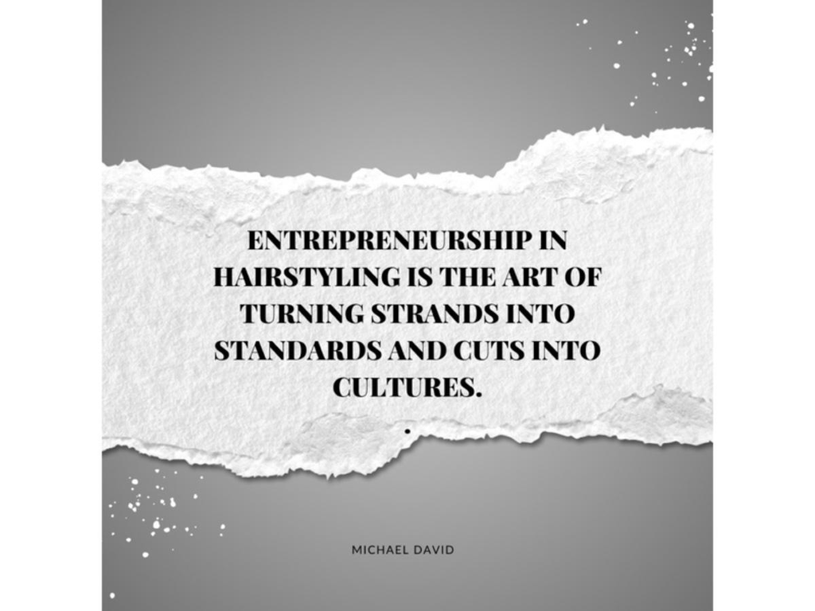

XIII

Embracing

Ethics

and

Sustainability

in

Hairstyling

> The earth is the Lord's, and everything in it, the world, and all who live in it.

— **— Psalm 24:1**

## Introduction

**F**eel the salon buzz with energy, each snip and spritz contributing to your client’s transformation. But with every cut and color, a new realization dawns—you’re not only shaping appearances but also leaving an impact on the world beyond your salon walls. From the products used to the waste generated, your choices contribute to something larger than beauty alone.

As awareness grows around environmental impact, hairstylists around the world are stepping up, reshaping their craft to reflect a commitment to ethical and sustainable practices. Leading the charge in sustainable beauty, Black-owned brands like The Lip Bar, founded by Melissa Butler, have transitioned from kitchen startups to eco-conscious powerhouses. Known for their commitment to eco-friendly ingredients and packaging, The Lip Bar has become a sustainable trailblazer. Similarly, Bread Beauty Supply by Maeva Heim emphasizes natural, biodegradable ingredients designed to care for textured hair while also caring for the planet.

Trailblazing hairstylists such as Vernon Francois, celebrated for his work with natural, textured hair, demonstrate how sustainability and beauty can coexist harmoniously. Vernon incorporates plant-based, biodegradable, and ethically sourced products, inspiring a movement of eco-conscious haircare in an industry not traditionally associated with environmental care. His approach reminds us that, as hairstylists, our influence reaches far beyond the chair.

In this chapter, we’ll embark on a transformative journey through the world of ethical and sustainable hairstyling. We’ll explore how to build eco-friendly salon environments, maintain integrity through transparency, and use your role as a stylist to advocate for industry-wide sustainability. You’ll meet stylists and salons already leading the way, like Greener Salon & Spa in New York, which has reduced its carbon footprint by switching to solar energy and adopting energy-efficient lighting, proving that sustainability can be as profitable as it is responsible.

Through these stories and practical steps, you’ll learn how to amplify your impact, aligning your business with practices that serve both your clients and the planet. Each mindful choice contributes to a larger movement toward a responsible, sustainable beauty industry. Are you ready to join these pioneers and shape the future of hairstyling, one green choice at a time?

## Personal Anecdote: The Environmental Awakening

I vividly remember the moment I first became aware of the environmental impact of my freelance hairstyling practices. Working independently meant I was responsible for every detail—from the energy-hungry lighting in my home studio to the disposable products used in each appointment. One evening, while reviewing my soaring energy bill, I realized that every inefficient bulb and single-use item was adding up, both in expenses and in environmental cost.

That night, I sat in my makeshift office surrounded by receipts and handwritten notes, overwhelmed by the thought that my work could be more sustainable. I took my first small step by switching to LED bulbs and setting up a basic recycling system for reusable items. This modest change not only lowered my bills but also sparked a commitment to integrate eco-friendly practices into every facet of my freelance career.

**Key Insight:** Environmental consciousness often begins with a single moment of awareness, and small initial changes can spark larger commitments to sustainable practices that benefit both the business and the planet.

## Quick Start Sustainability Guide

Beginning your sustainability journey doesn’t require a complete overhaul of your freelance business. These simple, affordable changes can make an immediate impact:

1. **Switch to LED lighting** in your workspace to reduce energy consumption by up to 75%.
2. **Use microfiber towels** instead of disposable ones, reducing waste while providing better absorbency.
3. **Install a programmable thermostat** to optimize energy use during and between client appointments.
4. **Create designated recycling bins** for product packaging, foils, and paper waste.
5. **Switch to concentrated products** that require less packaging and last longer.
6. **Opt for digital consultations and receipts** to reduce paper usage.
7. **Use refillable containers** for styling products to minimize plastic waste.

Remember: Sustainability is a journey, not a destination. These small changes build the foundation for more comprehensive practices as your business grows.

## I. Cultivating Eco-Friendly Salon Environments

Building an eco-friendly salon begins with the very foundation of our daily operations: energy usage, waste reduction, and sourcing environmentally responsible products. Each of these factors contributes to the sustainability of your salon, and together, they can shape a space that reflects your commitment to the environment while delivering a premium experience for your clients.

### Implementing Energy-Efficient Equipment and Renewable Power Sources

Imagine stepping into a salon where every piece of equipment hums with energy-efficient precision. Every chair, light fixture, and dryer is designed to minimize energy use, reducing both carbon footprint and electricity costs. Salons like Greener Salon & Spa in New York have made this vision a reality by switching to solar power and using energy-efficient lighting, reducing their energy costs by 25% and establishing themselves as a model of eco-friendly business.

Incorporating eco-friendly equipment can make a significant impact. Brands like Bio Ionic create styling tools that use natural volcanic minerals to speed up drying and styling time, reducing energy consumption and minimizing heat damage. The Shark HyperAIR dryer, known for its efficient heat control, is another tool that combines low energy use with effective performance. Additionally, investing in LED lighting not only reduces energy consumption but also provides better illumination for detailed styling work.

Leading technology in hairstyling tools also plays a crucial role in energy efficiency. Dyson, renowned for its innovative engineering, offers the Dyson Supersonic hair dryer, which uses a digital motor to provide fast drying with minimal heat damage. The Supersonic’s intelligent heat control and efficient airflow design ensure that energy usage is optimized without compromising performance. Similarly, the tool brand T3 provides a range of high-performance, energy-efficient styling tools such as the T3 Cura Luxe hair dryer, which features advanced ionic technology and customizable heat settings to reduce energy consumption while delivering salon-quality results.

#### ROI Calculation: Energy-Efficient Investment Returns

| Investment | Initial Cost | Annual Savings | Break-Even Point | 5-Year Savings |
| --- | --- | --- | --- | --- |
| LED Lighting (10 bulbs) | $150 | $120 | 15 months | $450 |
| Energy-Efficient Hair Dryer | $300 | $90 | 3.3 years | $150 |
| Programmable Thermostat | $75 | $180 | 5 months | $825 |
| Reusable Microfiber Towels | $120 | $200 | 7 months | $880 |

*Note: Actual savings may vary based on usage patterns and local utility rates. These calculations assume average usage in a freelance setting with 20-25 clients per week.*

By integrating these technologies, you’re not only reducing your salon’s environmental footprint but also demonstrating a commitment to sustainability that resonates with clients. The financial benefits of these energy-efficient upgrades are significant, with businesses saving up to 30% on energy costs through better energy management practices. Moreover, energy-efficient tools often come with longer lifespans and lower maintenance costs, further enhancing their value proposition.

**Actionable Steps:**

1. **Conduct an Energy Audit:** Many utility companies offer free or low-cost energy audits to help identify areas where you can improve efficiency. Assess your current energy usage to pinpoint high-consumption areas.
2. **Research Eco-Friendly Equipment:** Look for Energy Star-certified appliances and tools that prioritize energy efficiency, such as LED lighting, low-energy dryers, and programmable thermostats. Compare different brands and models to find the best fit for your salon’s needs.
3. **Consider Renewable Power Sources:** Investigate options for solar panel installation or green energy providers. Solar power, for instance, often pays for itself within a few years and can lower your energy bills significantly. Additionally, explore local incentives or rebates for adopting renewable energy solutions.
4. **Educate Your Team:** Ensure that all staff members are trained on the proper use of energy-efficient equipment to maximize their benefits and avoid unnecessary energy consumption.
5. **Incorporate Advanced Styling Tools:** Invest in high-performance, energy-efficient styling tools like the Dyson Supersonic and T3 Cura Luxe to enhance both sustainability and client satisfaction.

## Personal Anecdote: Energy-Efficient Tool Discovery

Before I discovered energy-efficient tools, I relied on older, power-hungry equipment that drove up my operational costs and subtly diminished the client experience in my home-based studio. Although I was careful with my finances as a freelancer, I hadn’t considered how much impact my tools had on both my energy usage and overall service quality.

A fellow freelance stylist recommended trying a new energy-efficient hair dryer known for its low power consumption and quiet operation. I hesitated at first due to the upfront investment and the learning curve, but once I made the switch, I was amazed. Not only did my energy bills drop noticeably, but clients also remarked on the gentler, quieter experience during their sessions. This single change affirmed that sustainable investments could save money and enhance service quality simultaneously.

**Key Insight:** Investing in energy-efficient tools can simultaneously reduce operational costs and improve client experience, demonstrating that sustainability and business excellence complement each other.

### Establishing Comprehensive Recycling and Waste Reduction Protocols

Eco-friendly salons don’t stop at energy efficiency—they also focus on minimizing waste. Imagine a zero-waste salon where every product, tool, and disposable item has been carefully chosen for its ability to be reused, recycled, or repurposed.

Salons like Shades of Green in Los Angeles are pioneering waste reduction by partnering with Green Circle Salons, an organization that provides comprehensive recycling and waste management solutions. By participating in Green Circle’s program, Shades of Green has diverted 90% of its waste from landfills, transforming hair clippings into oil spill cleanup mats and recycling foils, color tubes, and product containers.

Working as a mobile freelance stylist presents unique sustainability challenges, but also opportunities:

- **Travel Optimization:** Plan appointments geographically to minimize driving distances and fuel consumption.
- **Portable Collection System:** Create a compact, divided container system for collecting recyclables during on-location appointments.
- **Concentrated Products:** Use highly concentrated products that require less packaging and are lighter to transport.
- **Digital Communications:** Implement paperless booking, consultation, and payment systems.
- **Multi-Purpose Tools:** Invest in versatile tools that serve multiple functions to reduce the weight and volume of your kit.
- **Client Home Practices:** Educate clients about proper product disposal and sustainable hair care practices they can continue between appointments.

Implementing a comprehensive recycling and waste reduction protocol involves several key steps:

- **Identify Recyclable Materials:** Determine which materials used in your salon can be recycled, such as paper, plastics, glass, and metal. Work with your suppliers to ensure that packaging is recyclable or compostable.
- **Set Up Recycling Stations:** Create clearly labeled bins for different types of waste, ensuring that clients and staff understand and participate in your recycling efforts. Position these stations in convenient locations around the salon to encourage proper disposal.
- **Partner with Recycling Organizations:** Collaborate with organizations like Green Circle Salons to handle the recycling of salon-specific waste, such as hair clippings, foils, and color tubes. These partnerships ensure that waste is managed responsibly and converted into useful products.
- **Reduce Single-Use Items:** Minimize the use of disposable items by opting for reusable alternatives where possible. For example, use washable towels instead of disposable ones and refillable containers for shampoos and conditioners.
- **Educate Clients and Staff:** Inform both clients and staff about your recycling and waste reduction initiatives. Provide information on how they can contribute, such as using reusable cups or properly disposing of hair clippings.

By adopting comprehensive recycling protocols, you can create a salon environment where sustainability is a daily practice, not an afterthought. This not only reduces your environmental impact but also appeals to eco-conscious clients who value responsible business practices.

**Actionable Steps:**

1. **Conduct a Waste Audit:** Identify what types of waste your salon generates regularly and how you can reduce, reuse, or recycle it. Categorize waste into recyclable, compostable, and non-recyclable to streamline your efforts.
2. **Partner with Green Circle Salons:** If available, this organization provides recycling services for salon-specific materials like hair clippings, foils, and product containers. Their expertise ensures that your waste management practices are effective and compliant with local regulations.
3. **Implement Recycling Stations:** Create clearly labeled bins for paper, plastic, and hair waste, ensuring that clients and staff understand and participate in your recycling efforts. Place these stations in high-traffic areas like the reception desk and waiting area.
4. **Train Your Team:** Educate your staff on proper waste segregation and recycling procedures. Regular training sessions can reinforce the importance of waste reduction and ensure that everyone is on the same page.
5. **Minimize Waste:** Opt for bulk purchasing to reduce packaging waste and choose products with minimal or recyclable packaging. Encourage clients to bring their own reusable items where possible.

### Sourcing Biodegradable Product Alternatives for Disposable Supplies

Sustainability goes beyond what we recycle; it includes what we use in the first place. By choosing biodegradable alternatives for disposable salon supplies, you can reduce waste without compromising on quality or client experience.

#### Budget-Friendly Sustainable Options: Comparative Pricing

| Product Type | Conventional Option | Eco-Friendly Alternative | Price Difference | Long-Term Benefits |
| --- | --- | --- | --- | --- |
| Hair Color | Standard Color: $8-10/application | Organic Color: $10-15/application | +$2-5 per client | Reduced chemical exposure, client loyalty |
| Styling Products | Aerosol Hairspray: $12 | Pump Hairspray: $14 | +$2 | Lower emissions, healthier air quality |
| Client Capes | Plastic Disposable: $0.30 each | Biodegradable: $0.50 each | +$0.20 per client | Reduced plastic waste, positive client impression |
| Towels | Paper Towels: $0.10/use | Microfiber Towels: $4 each (200+ uses) | -$16 per 200 uses | Significant cost savings, better performance |
| Packaging | Single-use Bottles: $2-3 | Refillable Systems: $5-8 initial, $1-2 refills | -$15+ annually | Waste reduction, lower long-term costs |

*Note: Initial investment in sustainable options often yields cost savings over time while enhancing your brand’s reputation with eco-conscious clients.*

Consider using brands like EcoTools for brushes, which emphasizes eco-friendly materials, or Naturtint for organic hair color solutions. At Sustainable Shears in Seattle, for instance, biodegradable capes and compostable towels have become standard. Their clients appreciate this eco-conscious approach, which has fostered brand loyalty and even increased clientele over time.

Switching to biodegradable products involves several considerations:

- **Evaluate Product Options:** Research and select products that are fully biodegradable or compostable. This includes everything from hair capes and towels to disposable gloves and foils.
- **Assess Quality and Performance:** Ensure that biodegradable alternatives meet your salon’s quality standards. Test products to verify that they perform as well as or better than their non-biodegradable counterparts.
- **Vendor Partnerships:** Partner with suppliers who prioritize sustainability and offer a range of biodegradable products. This ensures a consistent supply and helps build a reliable eco-friendly product line.
- **Cost-Benefit Analysis:** While biodegradable products may come at a higher upfront cost, consider the long-term benefits, such as reduced environmental impact, enhanced brand reputation, and increased client loyalty.

By integrating biodegradable products into your salon’s operations, you’re making a conscious choice to protect the environment while providing exceptional service to your clients. This commitment not only aligns with global sustainability goals but also sets your salon apart as a leader in eco-friendly beauty practices.

**Actionable Steps:**

1. **Research Biodegradable Brands:** Seek out brands that prioritize sustainable materials, like compostable towels and capes from EcoTools and low-waste color products from Naturtint. Look for certifications that verify the biodegradability and eco-friendliness of products.
2. **Transition Slowly:** Start by replacing one or two disposable items with biodegradable options and expand as you find products that meet your needs. This gradual approach allows you to manage costs and ensure quality without overwhelming your operations.
3. **Educate Clients:** Let clients know about the eco-friendly choices you’re making. Create displays or cards that explain the environmental benefits of using biodegradable products. This transparency fosters trust and encourages clients to support your sustainable practices.
4. **Monitor and Adjust:** Regularly assess the performance and client feedback on biodegradable products. Make adjustments as necessary to ensure that your eco-friendly choices continue to meet your salon’s standards and client expectations.
5. **Optimize Supply Chain:** Work with suppliers who offer biodegradable products and commit to sustainable sourcing. Ensure that your inventory management minimizes waste and maximizes the use of biodegradable items.

By adopting energy-efficient tools, comprehensive recycling protocols, and biodegradable supplies, you can build a salon environment that attracts eco-conscious clients and aligns with your commitment to the planet. These small changes, implemented consistently, position your salon as a leader in the sustainable beauty movement.

## II. Maintaining Relational Business Integrity and Transparency Practices

Eco-friendly choices and sustainable practices become more meaningful when paired with open, transparent communication about the value these bring to clients and the planet. By clearly explaining the costs and benefits of sustainable choices, you foster a sense of partnership with your clients, building trust, loyalty, and even admiration for your business’s commitment to the environment.

### Providing Detailed Service Cost Breakdowns, Accounting for Specialized Value

Many eco-friendly products and sustainable practices come with higher upfront costs, but they also offer unique, long-term benefits for both the client and the environment. Transparent communication around these costs can help clients understand the added value of these services.

Celebrity stylist Nikki Nelms has built trust with her clients by offering clear, detailed breakdowns of her service costs, including an explanation of her sustainable practices. She educates clients about the environmental benefits of organic products and highlights the cost differences between sustainable and conventional options. This transparency fosters a strong connection, demonstrating both the value of her eco-friendly approach and the care behind her pricing.

Providing detailed service cost breakdowns involves:

- **Itemizing Costs:** Break down each service to show where the money is going. This can include product costs, energy usage, waste management, and labor. For example, a coloring service might detail the use of organic dyes, the energy-efficient dryer, and the biodegradable capes.
- **Highlighting Sustainable Practices:** Clearly explain the sustainable choices you’ve made, such as using non-toxic products, recycling waste, or using renewable energy sources. This helps clients appreciate the environmental benefits and the added value of your services.
- **Educating Clients on Value:** Emphasize the long-term benefits of sustainable practices, such as healthier hair, reduced environmental impact, and the ethical sourcing of products. This education can shift the focus from cost to value.
- **Offering Tiered Pricing Options:** Provide different pricing tiers that reflect varying levels of sustainability. For example, offer a basic service using standard products and a premium service using eco-friendly products, allowing clients to choose based on their preferences and budgets.

**Actionable Steps:**

1. **Develop an Itemized Pricing Structure:** Include specific costs associated with sustainable products and practices to clarify the service’s value. Use detailed invoices or digital pricing menus that outline each component of the service.
2. **Create Informative Handouts or Digital Displays:** Share visual materials explaining why sustainable products may cost more and the environmental benefits they bring. Place these in the salon or include them in digital communications like newsletters or social media posts.
3. **Train Staff on Talking Points:** Ensure that everyone on your team can confidently communicate the benefits of eco-friendly practices, helping clients understand their added value. Role-play conversations and provide scripts or key points for staff to use when discussing pricing with clients.
4. **Implement a Transparent Pricing Policy:** Make it clear to clients that your pricing reflects your commitment to sustainability. Include statements about ethical practices and environmental responsibility in your promotional materials and during consultations.
5. **Use Technology to Showcase Costs:** Consider using digital tablets or interactive displays that break down the costs and benefits of each service in real-time, providing an engaging way for clients to understand the value.

By providing detailed service cost breakdowns, you reinforce the value of your sustainable practices and build stronger, more trusting relationships with your clients.

## Personal Anecdote: Transparency Building Trust

Transparency has always been central to my freelance journey, especially regarding sustainability. When I revised my pricing to reflect my investments in eco-friendly tools and sustainable products, I knew that clear communication with my clients was essential.

I remember explaining to a long-time client why my rates had increased slightly—revealing that the additional cost was earmarked for sustainable investments, like energy-efficient equipment and eco-friendly products. Her response was a mix of surprise and gratitude; she admitted that she’d never considered the environmental impact of her salon visits before. That honest conversation not only deepened our trust but also inspired her to embrace sustainability in her own routine, proving that open dialogue can spark meaningful change.

**Key Insight:** Transparent communication about sustainable practices not only builds trust with clients but can also inspire them to adopt eco-friendly habits in their own lives, creating a ripple effect of positive environmental impact.

### Fostering Open Client Dialogues Around Sustainability-Driven Pricing Models

Transparency can go beyond simply explaining costs. By openly discussing the broader impact of eco-friendly choices, you shift clients’ perspectives from seeing sustainable services as added expenses to understanding them as investments in health and the planet.

Consider True Eco Beauty Salon in Atlanta, which incorporates a “sustainability surcharge” option. Clients who choose this surcharge contribute directly to the salon’s green initiatives, like expanding their recycling program or investing in biodegradable supplies. This approach not only covers costs but encourages clients to be active participants in sustainability, strengthening their connection to the salon’s mission.

Fostering open client dialogues involves:

- **Encouraging Questions:** Invite clients to ask about your sustainable practices and be prepared to provide thoughtful, informative answers. This openness can lead to more engaged and appreciative clients.
- **Sharing Success Stories:** Highlight how your sustainable choices have positively impacted the environment and the salon. For instance, share metrics like reduced waste or lower energy consumption.
- **Creating Interactive Opportunities:** Host events or workshops focused on sustainability in beauty, allowing clients to learn and engage with your eco-friendly initiatives actively.
- **Using Digital Platforms for Transparency:** Leverage social media, email newsletters, and your website to regularly update clients on your sustainability efforts and their outcomes.

**Actionable Steps:**

1. **Create a Sustainability Surcharge Option:** Offer clients a small additional charge that supports eco-friendly initiatives within the salon. Clearly explain how this surcharge will be used to further your sustainability goals.
2. **Encourage Client Participation:** Use consultation time to explain how their choices, like opting for organic products, contribute to reducing environmental impact. Provide incentives for clients who participate in sustainability initiatives, such as discounts or loyalty points.
3. **Gather Client Feedback on Sustainable Practices:** Regularly check in with clients to understand their views on eco-friendly services and discuss any changes or additions they would like to see. Use surveys or suggestion boxes to collect feedback.
4. **Highlight Client Contributions:** Acknowledge and celebrate clients who actively participate in your sustainability efforts. Feature their stories or testimonials in your marketing materials to inspire others.
5. **Engage in Two-Way Communication:** Use platforms like Instagram Stories or Facebook Live to host Q&A sessions where clients can ask about your sustainable practices in real-time, fostering a more interactive and transparent relationship.

By fostering open dialogues, you transform sustainability from a policy into a shared value, creating a community of clients who are invested in your salon’s eco-friendly mission.

### Vetting Supply Chain Partners for Ethical Manufacturing and Labor Standards

Maintaining ethical integrity extends beyond the salon’s four walls. Ensuring that products and tools are sourced from companies committed to ethical manufacturing, fair labor practices, and environmentally friendly production is essential to upholding a holistic commitment to sustainability.

To ensure that partners align with their values, many salons prioritize brands with a proven commitment to ethical practices. This involves looking for certifications, conducting supplier research, and occasionally even visiting manufacturing sites. By carefully vetting suppliers, salons can promote quality and integrity across every aspect of their business.

Key aspects of vetting supply chain partners include:

- **Certifications and Standards:** Look for suppliers that have certifications like Fair Trade, Organic, or B Corporation. These certifications provide assurance that the products meet certain ethical and environmental standards.
- **Transparent Manufacturing Processes:** Choose suppliers who are open about their manufacturing processes and supply chain. Transparency builds trust and allows you to verify that ethical practices are being followed.
- **Fair Labor Practices:** Ensure that your suppliers adhere to fair labor practices, providing safe working conditions, fair wages, and respecting workers’ rights.
- **Sustainable Sourcing:** Opt for suppliers who source materials sustainably, reducing environmental impact and promoting biodiversity.
- **Quality Assurance:** Select suppliers who prioritize quality, ensuring that their products are not only ethical but also effective and safe for use in your salon.

**Actionable Steps:**

1. **Research Supplier Standards:** Prioritize suppliers that commit to fair wages, safe working conditions, and sustainable manufacturing processes. Use online resources and industry networks to identify potential partners.
2. **Request Transparency Reports:** Many companies provide annual sustainability or corporate responsibility reports—review these documents to assess alignment with your values. Request detailed information about their sourcing and manufacturing practices.
3. **Set Clear Expectations:** Communicate your standards to your suppliers and consider discontinuing partnerships if their practices don’t align with your salon’s commitment to sustainability. Draft a supplier code of conduct that outlines your ethical and environmental requirements.
4. **Visit Manufacturing Sites:** If feasible, visit your suppliers’ manufacturing facilities to observe their practices firsthand. This can provide deeper insights into their operations and commitment to ethical standards.
5. **Seek Recommendations:** Network with other eco-friendly salons and industry professionals to get recommendations for reliable and ethical suppliers.

By carefully vetting supply chain partners, you ensure that every product and tool used in your salon upholds your commitment to ethics and sustainability, reinforcing your brand’s integrity and appeal.

## Personal Anecdote: Community Learning and Collaboration

As a freelance hairstylist, I quickly discovered that sustainability is a journey best traveled with others. I reached out to fellow independent stylists who shared my passion for eco-friendly practices, and together we began exchanging ideas and resources.

One standout experience was joining an online group dedicated to sustainable freelancing. In one discussion, a fellow stylist introduced me to a supplier offering eco-friendly, refillable packaging at a discounted rate. This discovery not only helped reduce waste but also significantly cut my operating costs. That collaboration underscored the value of community: by sharing knowledge and resources, we all build more resilient, sustainable practices—and that lesson has been invaluable in my ongoing journey.

**Key Insight:** Collaboration with like-minded professionals creates opportunities for shared learning, resource sharing, and cost savings while strengthening commitment to sustainable practices.

## III. Advancing Industry Sustainability Standards Through Collective Advocacy

True change in the beauty industry requires efforts that go beyond individual salons. By collaborating with other professionals, joining alliances, and advocating for sustainability-focused policies, hairstylists can help drive a collective movement toward a more responsible and eco-friendly industry. By uniting, salons amplify their influence, encouraging suppliers, clients, and legislators to adopt practices that prioritize environmental stewardship and ethical standards.

### Collaborating with Salon Alliances to Amplify Supplier Negotiation Leverage

One way to drive industry-wide change is through partnerships with salon alliances and professional networks. By working together, salons can leverage collective purchasing power to negotiate for sustainable products, services, and practices from suppliers. When many voices come together with a unified demand for eco-friendly products, suppliers are more likely to respond, adjusting their offerings to meet the growing demand.

Eco Salon Collective is an example of a network that empowers salons to advocate for sustainable products by buying in bulk and working directly with eco-conscious brands. Such alliances not only make sustainable products more accessible but also reduce costs, making it easier for smaller salons to maintain an eco-friendly approach.

Collaboration within salon alliances involves:

- **Unified Purchasing Power:** Group buying agreements allow salons to purchase products at lower prices due to bulk orders, making sustainable options more financially viable.
- **Shared Knowledge and Resources:** Alliances provide a platform for sharing best practices, resources, and insights on sustainability initiatives, fostering a culture of continuous improvement.
- **Collective Advocacy:** By presenting a united front, salon alliances can advocate for industry-wide changes, such as stricter environmental regulations or incentives for sustainable practices.
- **Joint Marketing Efforts:** Collaborating on marketing campaigns or events focused on sustainability can amplify the message and reach a broader audience.

**Actionable Steps:**

1. **Join or Form Local Eco-Friendly Alliances:** Look for existing alliances with a focus on sustainability, or consider forming one with other salons in your area. Engage with local beauty industry groups to find like-minded partners.
2. **Collaborate on Sustainable Standards:** Work with alliance members to set sustainability goals, such as zero-waste commitments or exclusive use of biodegradable products. Establish shared standards that all members agree to uphold.
3. **Collectively Negotiate Supplier Deals:** Organize group purchasing agreements to negotiate discounts on sustainable supplies and tools. Present a united front to suppliers, demonstrating the collective demand for eco-friendly products.
4. **Share Success Stories:** Regularly share and celebrate the sustainability achievements of alliance members. Highlighting individual successes can inspire others to adopt similar practices and reinforce the collective commitment to sustainability.
5. **Host Joint Events:** Organize workshops, seminars, or webinars focused on sustainability in hairstyling. These events can provide valuable education, foster community, and promote eco-friendly practices across the industry.
6. **Leverage Technology for Collaboration:** Utilize collaborative tools and platforms to manage alliance activities, track progress, and share resources efficiently. Tools like Slack or Trello can facilitate communication and project management among alliance members.

By collaborating with salon alliances, you not only enhance your salon’s sustainability efforts but also contribute to a larger movement that drives meaningful change across the beauty industry.

#### 12-Month Sustainability Implementation Roadmap

| Timeline | Focus Area | Action Items | Investment Level | Impact Level |
| --- | --- | --- | --- | --- |
| **Months 1-3** Foundation | Energy & Basic Recycling | • Switch to LED lighting<br>• Install programmable thermostat<br>• Set up basic recycling system<br>• Conduct energy audit | Low | Medium |
| **Months 4-6** Client Education | Communication & Products | • Develop sustainability messaging<br>• Create pricing transparency materials<br>• Introduce first eco-friendly product lines<br>• Begin client education initiatives | Low-Medium | Medium |
| **Months 7-9** Equipment Upgrade | Tools & Supplies | • Research energy-efficient styling tools<br>• Invest in first sustainable equipment<br>• Transition to biodegradable disposables<br>• Join professional sustainability networks | Medium-High | High |
| **Months 10-12** Advanced Integration | Supply Chain & Advocacy | • Vet and transition to ethical suppliers<br>• Implement comprehensive recycling program<br>• Begin industry advocacy efforts<br>• Measure and report on sustainability impacts | Medium | High |

*Note: This roadmap allows for sustainable growth without overwhelming your business or budget. Adjust timing based on your specific circumstances and prioritize actions with the highest impact-to-investment ratio.*

### Championing Legislative Policies Mandating Responsible Sourcing Practices

Hairstylists can also support policy changes that mandate eco-friendly practices across the beauty industry. This might involve advocating for restrictions on toxic chemicals in hair products, pushing for packaging standards to reduce plastic waste, or lobbying for extended producer responsibility for product disposal. Such policies set a baseline of sustainability standards that can impact the entire industry.

For instance, The California Toxic-Free Cosmetics Act (AB 2762), passed in 2020, bans 24 harmful ingredients from personal care products, helping to protect both consumers and the environment. By backing similar initiatives, stylists play a role in encouraging safer, more sustainable practices industry-wide.

Supporting legislative policies involves:

- **Staying Informed on Relevant Legislation:** Keep up-to-date with new and pending laws that affect the beauty industry, particularly those related to environmental sustainability and product safety.
- **Engaging with Local Representatives:** Reach out to lawmakers to voice your support for policies that prioritize environmental responsibility within the beauty industry. Share your experiences and the benefits of sustainable practices to influence policy decisions.
- **Participating in Advocacy Campaigns:** Join or support advocacy groups that focus on sustainability in the beauty industry. Participate in letter-writing campaigns, petitions, or public hearings to demonstrate industry-wide support for eco-friendly legislation.
- **Educating Clients and the Public:** Use your platform to inform clients about important legislative changes and how they benefit both the environment and personal health. Encourage clients to support sustainable policies through their own advocacy efforts.

**Actionable Steps:**

1. **Stay Informed on Relevant Legislation:** Subscribe to industry newsletters, join professional associations, and follow relevant government bodies to stay updated on new laws and regulations.
2. **Engage with Local Representatives:** Schedule meetings or attend town halls with your local representatives to discuss the importance of sustainable policies in the beauty industry. Provide testimonials or data to support your advocacy.
3. **Use Your Platform for Advocacy:** Share information about important legislative efforts on your salon’s social media channels, website, and during client consultations. Encourage clients to support these initiatives through petitions or by contacting their own representatives.
4. **Collaborate with Advocacy Groups:** Partner with environmental or beauty industry advocacy groups to amplify your voice and contribute to larger campaigns focused on sustainability and ethical practices.
5. **Host Informational Sessions:** Organize in-salon events or webinars where clients can learn about relevant legislation and how they can get involved in supporting sustainable policies.

By championing legislative policies, you help create a regulatory environment that supports sustainable practices, ensuring that ethical standards are maintained across the beauty industry.

### Spotlighting Diverse Perspectives on Intersectional Sustainability Equity

True sustainability in the beauty industry considers not just environmental impact but also the social equity within these initiatives. Intersectional sustainability involves including diverse voices—especially those of underrepresented communities—in the conversation about eco-friendly practices. Stylists and salon owners from these communities often face unique challenges and bring essential perspectives to the table, contributing ideas rooted in cultural knowledge and experience.

Bread Beauty Supply, a Black-owned haircare brand, combines sustainability with a commitment to inclusivity by using biodegradable ingredients and packaging, catering to natural hair needs while respecting the environment. Recognizing and amplifying such efforts strengthens the sustainability movement and ensures it benefits everyone.

Spotlighting diverse perspectives involves:

- **Highlighting Diverse Voices:** Feature stories and testimonials from stylists and clients from various cultural backgrounds. Showcasing their experiences and contributions to sustainability can inspire and educate others.
- **Inclusive Product Development:** Collaborate with diverse communities to develop products and services that meet their specific needs while adhering to sustainable practices.
- **Cultural Competency Training:** Educate your team on the importance of cultural diversity and inclusion in sustainability initiatives. Understanding different cultural perspectives can enhance your salon’s approach to eco-friendly practices.
- **Supporting Minority-Owned Sustainable Brands:** Partner with and promote brands owned by individuals from underrepresented communities. This not only supports these businesses but also enriches your own product offerings with unique, culturally informed perspectives.

**Actionable Steps:**

1. **Highlight the Work of Diverse Stylists and Brands:** Share content or host events that promote underrepresented voices in sustainability. Use your salon’s platforms to feature interviews, spotlight stories, or guest blog posts from diverse professionals.
2. **Collaborate with Diverse Suppliers:** Partner with brands and suppliers that are owned by or cater to marginalized communities, bringing inclusivity into your product offerings. Ensure that your supply chain reflects the diversity of your client base.
3. **Participate in Intersectional Sustainability Discussions:** Attend panels or workshops that focus on the intersection of sustainability, diversity, and equity within the beauty industry. Share these insights with your clients and colleagues to foster a more inclusive approach to sustainability.
4. **Create Inclusive Marketing Campaigns:** Design marketing materials that reflect the diversity of your clientele and highlight the inclusive nature of your sustainable practices. Use diverse models and authentic representations to connect with a broader audience.
5. **Support Community Initiatives:** Engage with local community projects or non-profits that focus on both sustainability and social equity. Volunteer your salon’s resources or services to support these initiatives, strengthening your community ties and promoting inclusive sustainability.

By embracing intersectional sustainability equity, you ensure that your salon’s sustainability efforts are inclusive, respectful, and beneficial to all communities, fostering a more equitable and responsible beauty industry.

## Case Study: Energy Audit and Upgrade Implementation

**Real-Life Example: Salon Energy Transformation**

**Challenge:** A freelance stylist operating from a home studio faced rising energy costs and wanted to reduce environmental impact while maintaining service quality.

**Solution:** Conducted a comprehensive energy audit through local utility company, identifying high-consumption areas including lighting, heating/cooling, and equipment usage. Implemented LED lighting upgrade, installed programmable thermostat, and invested in energy-efficient styling tools.

**Outcome:** Achieved 30% reduction in energy costs within six months while improving service quality through quieter, more efficient equipment. Clients responded positively to sustainability messaging and environmental commitment.

**Lessons Learned:** Strategic energy efficiency investments provide both environmental benefits and cost savings while enhancing client perception and service quality.

## Actionable Steps

### Eco-Friendly Environment Creation

1. **Energy Efficiency Implementation:** Conduct energy audits and upgrade to LED lighting, programmable thermostats, and energy-efficient styling tools.
2. **Waste Reduction Systems:** Establish comprehensive recycling protocols and partner with organizations like Green Circle Salons.
3. **Sustainable Product Sourcing:** Transition to biodegradable alternatives and research eco-friendly product lines.

### Transparency and Communication

1. **Pricing Transparency:** Develop detailed service cost breakdowns that highlight sustainable practices and their value.
2. **Client Education:** Foster open dialogues about sustainability initiatives and their environmental impact.
3. **Supply Chain Ethics:** Vet suppliers for ethical manufacturing and labor standards.

### Industry Advocacy and Collaboration

1. **Alliance Building:** Join or form eco-friendly salon alliances to leverage collective purchasing power.
2. **Legislative Support:** Stay informed and advocate for sustainable policies in the beauty industry.
3. **Diverse Perspectives:** Spotlight and support underrepresented voices in sustainability efforts.

### Implementation Planning

1. **Roadmap Development:** Follow 12-month implementation timeline prioritizing high-impact, low-investment actions first.
2. **Progress Tracking:** Establish metrics for measuring sustainability improvements and cost savings.
3. **Community Engagement:** Build networks with other sustainable practitioners for shared learning and support.

## Quiz

### Question 1

Which of the following is an eco-friendly option for a salon environment?

a) Installing LED lighting b) Using disposable plastic cups for clients c) Ignoring product packaging d) Increasing heating to reduce humidity

### Question 2

Why is providing detailed service cost breakdowns beneficial?

a) It allows you to increase prices without explanation b) It helps clients understand the value of sustainable practices c) It removes the need for sustainable practices d) It simplifies staff training

### Question 3

Which high-performance, energy-efficient hair dryer is known for its intelligent heat control?

a) Revlon One-Step b) Dyson Supersonic c) Hot Tools Professional d) Conair Infiniti Pro

### Question 4

What is a key benefit of joining salon alliances focused on sustainability?

a) Access to exclusive products b) Increased leverage in advocating for eco-friendly supplies c) Reduced need for sustainable practices d) Free marketing materials

## Worksheet

### Ethical Practices Worksheet

This worksheet serves as a reflective tool to solidify your commitments to sustainability, inclusivity, and ethical practices in your hairstyling business.

**1. Sustainability Commitments:** List the steps you will take to enhance your salon’s sustainability, from waste management to energy usage.

*Example:* “Switch to LED lighting, install a smart thermostat, and partner with Green Circle Salons for recycling.”

Your commitment:

**2. Inclusivity Practices:** Describe how you’ll create an inclusive environment, from training on diverse hair textures to offering eco-friendly product options for all hair types.

*Example:* “Feature diverse models in marketing, provide accessible services, and educate clients on sustainable options for textured hair.”

Your approach:

**3. Transparent Pricing and Ethical Sourcing:** Describe how you will inform clients about the costs and benefits of sustainable services, and ensure your products are ethically sourced.

*Example:* “Create a ‘sustainability surcharge’ for clients who want to contribute to green initiatives.”

Your strategy:

**4. Monitoring and Continuous Improvement:** Detail how you’ll track your progress and adjust practices as needed. Include specific metrics or feedback mechanisms.

*Example:* “Conduct quarterly sustainability audits, track waste reduction, and survey clients on their preferences for eco-friendly services.”

Your monitoring plan:

**5. Community and Industry Engagement:** Outline how you’ll collaborate with other professionals and advocate for industry-wide sustainability.

Your engagement strategy:

**6. Implementation Timeline:** Create a 6-month action plan for implementing your sustainability initiatives.

**Month 1-2:**

**Month 3-4:**

**Month 5-6:**

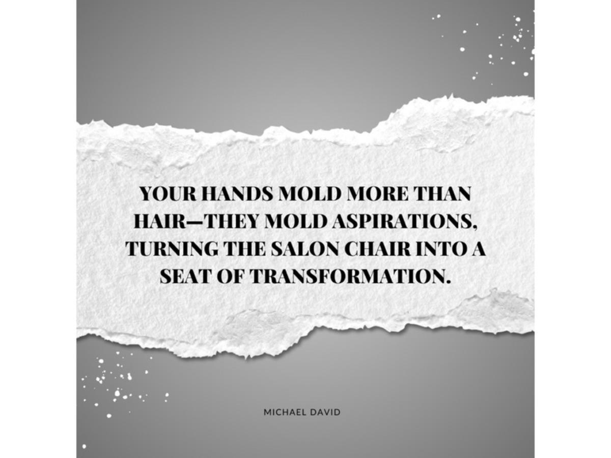

# Part IV: Future-Focused Growth

## Chapters XIV—XVI

The horizon of our industry isn't approaching—it's already here, reshaping everything from client expectations to environmental responsibilities. In these final chapters, you'll step beyond today's best practices into tomorrow's competitive advantages. While others react to change, you'll learn to anticipate it, cultivating the adaptive intuition that distinguishes visionaries from followers.

From AI-powered client analysis to biodegradable product innovations, these pages reveal how forward-thinking stylists are already leveraging emerging technologies and sustainability principles to create experiences that transcend traditional service boundaries. This isn't distant theory— it's your practical roadmap for remaining relevant and resonant in an industry where the only constant is transformation. As you close this book, you won't just be prepared for the future—you'll be positioned to create it.

XIV

The

Impact

of

AI

on

the

Beauty

Industry

> Do nothing out of selfish ambition or vain conceit. Rather, in humility value others above yourselves, not looking to your own interests but each of you to the interests of the others.

— **— Philippians 2:3-4**

## Introduction

**A**rtificial intelligence is transforming the beauty industry in ways we could scarcely have imagined a decade ago. From virtual consultations to personalized product formulations, AI technologies are reshaping how stylists work, how clients experience beauty services, and how brands develop and deliver products. For freelance hairstylists navigating this changing landscape, AI presents both exciting opportunities and legitimate concerns. How do we embrace these powerful tools while preserving the artistry and human connection that define our craft?

The beauty industry has always been at the intersection of art and science, tradition and innovation. Today, as AI becomes increasingly embedded in our professional tools and client experiences, we face a pivotal moment that challenges us to redefine what it means to be a hairstylist in the digital age. Will AI enhance our capabilities and free us to focus on creativity, or will it diminish the personal touch that makes our work meaningful? This chapter explores this question, offering practical insights on how to harness AI’s potential while preserving the irreplaceable human elements of our profession.

This chapter will guide you through the evolving AI landscape in the beauty industry, offering a balanced perspective that acknowledges both the transformative potential and the important boundaries of these technologies. We’ll explore how AI is enhancing client experiences, revolutionizing product development, optimizing supply chains, and creating new opportunities for stylists who are willing to adapt. Most importantly, we’ll provide a practical roadmap for incorporating AI into your practice at a pace that feels comfortable, emphasizing which human skills become even more valuable in this technological era.

Whether you’re tech-savvy and eager to embrace the latest innovations or approaching digital tools with caution, this chapter aims to empower you with knowledge and strategies to thrive in an AI-enhanced beauty industry. The future of hairstyling isn’t about choosing between human artistry and artificial intelligence—it’s about finding the sweet spot where technology amplifies your creativity and deepens your client connections rather than diminishing them.

## Personal Anecdote: Discovering AI as a Creative Partner

Initially, I was skeptical about incorporating AI into my hairstyling services, fearing it might overshadow the personal touch integral to my work. My perspective shifted when I experimented with L’Oréal’s “Style My Hair” app, an AI-driven virtual try-on tool that allows clients to preview different hair colors and styles in real-time. To my surprise, this technology complemented my creative judgment rather than replacing it. It enabled clients to visualize potential transformations, facilitating more informed and confident decisions. This experience reshaped my view of technology’s role, recognizing it as a valuable ally in enhancing client satisfaction.

**Key Insight:** AI tools can serve as creative partners rather than replacements, enhancing the consultation process and building client confidence while preserving the stylist’s essential role in creative decision-making.

## I. Client Experience Enhancement: AI-Powered Personalization

The client experience has always been at the heart of successful hairstyling. Today, AI is offering unprecedented opportunities to enhance these experiences through deeper personalization, more informed consultations, and immersive visualization tools. Far from replacing the stylist-client relationship, these technologies can enrich these connections by providing more tailored, engaging, and informative interactions.

### Virtual Consultations and Try-On Technologies ⭐

Virtual try-on technologies represent one of the most visible and rapidly evolving applications of AI in the beauty industry. Advanced tools like ModiFace (acquired by L’Oréal), Perfect Corp’s YouCam apps, and specialized platforms from major brands use augmented reality and AI to allow clients to visualize different hair colors, cuts, and styles before making a change. These technologies analyze facial features, hair texture, and other parameters to create realistic previews that help clients make more confident decisions.

Recent advancements in these technologies have made virtual try-ons increasingly sophisticated and realistic. For example, L’Oréal’s Beauty Genius, launched in 2024, combines generative AI with augmented reality to provide personalized virtual try-ons based on a deep understanding of hair characteristics. The platform’s AI engine has been trained on thousands of professional and real-life beauty consultations to ensure accurate and practical recommendations.

For stylists, these tools transform the consultation process, reducing the anxiety clients often feel about committing to a new look. By allowing clients to see realistic previews, these technologies build trust and open the door to more creative possibilities. Additionally, virtual consultations enable stylists to connect with clients remotely, expanding reach beyond geographic limitations.

**Actionable Applications:**

- Use virtual try-on apps during consultations to help clients visualize potential changes
- Offer pre-appointment virtual consultations to better prepare for in-person services
- Create digital portfolios of transformation options customized to each client
- Leverage these tools to help hesitant clients feel more confident about trying new styles

## Personal Anecdote: AI-Enhanced Consultation Success

During a consultation, a client was uncertain about which hairstyle would suit her face shape. Utilizing an AI-powered styling tool that analyzes facial features to suggest suitable hairstyles, we explored various options. While the AI provided a range of styles, it was my professional insight into her lifestyle and personal preferences that guided the final decision. This experience underscored that, although AI offers valuable data, the human element remains crucial in interpreting and tailoring these insights to each client’s unique needs.

**Key Insight:** AI provides valuable analytical foundation, but human expertise remains essential for interpreting data within the context of individual client lifestyles, preferences, and personal circumstances.

### Data-Driven Personalization Systems ⭐⭐

Beyond visual try-on tools, more sophisticated AI systems are enabling deeper personalization based on comprehensive client data. Platforms like Prose and Function of Beauty have pioneered AI-driven personalization in hair care products, analyzing dozens of factors—from hair type and texture to local environmental conditions—to create custom formulations. Similar approaches are emerging for in-salon services, where stylists can leverage AI to tailor treatments based on detailed client profiles.

Recent clinical studies have demonstrated the effectiveness of this approach. For example, Prose’s AI-driven custom formulations have been shown to outperform standard off-the-shelf products in controlled tests. The company’s algorithm considers 80 different metrics about a person’s hair and environment to create unique formulations from a bank of over 165 ingredients, resulting in more than 80 million possible combinations.

A significant innovation in this space is Hair AI by John Paul Mitchell Systems, a professional salon service that utilizes a specialized scanner attachment for smartphones to conduct detailed hair and scalp analysis. The system examines both scalp condition and hair health, then generates personalized product and treatment recommendations. Salon professionals report that this technology not only enhances the client consultation experience but also improves retail sales by providing scientific validation for product recommendations.

These systems learn over time, incorporating feedback and results to continuously refine recommendations. For stylists, this means gaining access to increasingly sophisticated insights that can inform service recommendations, product suggestions, and maintenance advice. The result is a more personalized experience that makes clients feel truly understood and cared for.

**Actionable Applications:**

- Implement digital client profiles that track treatment history, preferences, and results
- Use AI-powered analysis tools like Hair AI to scientifically analyze clients’ hair and scalp conditions
- Partner with AI-driven custom product brands to offer personalized take-home regimens
- Create a feedback loop that allows your recommendations to become more refined over time

### Client Journey Optimization ⭐⭐⭐

The most advanced AI applications in client experience extend beyond individual consultations or services to optimize the entire client journey. These systems can anticipate client needs, automate follow-up communications, and create seamless experiences across physical and digital touchpoints.

Modern salon management platforms now incorporate AI to create more intelligent client experiences. For instance, platforms like DaySmart Salon use AI algorithms to analyze client behavior patterns and preference data to optimize scheduling, automate personalized communications, and suggest services based on past history. Some platforms can even predict when clients might be ready for maintenance appointments, helping to reduce gaps in stylist schedules.

For example, Sephora’s AI systems track client interactions across channels, from in-store visits to online browsing, creating a unified view that informs personalized recommendations. Aveda uses predictive analytics to anticipate when clients might need maintenance appointments or product replenishments, triggering perfectly timed communications. These capabilities allow stylists to maintain meaningful connections with clients between appointments, fostering loyalty and enhancing satisfaction.

**Actionable Applications:**

- Implement intelligent scheduling systems that recommend optimal appointment timing
- Create automated, personalized follow-up sequences after services
- Use predictive analytics to anticipate client needs and proactively address them
- Develop multi-channel communication strategies that maintain consistent client experiences

## II. Product and Technique Innovation: Accelerating Discovery

AI is dramatically accelerating innovation in hair care products and styling techniques, enabling more rapid discovery, testing, and refinement. For stylists, this means gaining access to more effective tools and products while also having opportunities to contribute to the innovation process through feedback and collaboration.

### AI-Powered Formula Development ⭐⭐⭐

The traditional product development cycle in hair care has been lengthy and resource-intensive, often taking years to bring new formulations to market. AI is transforming this process by analyzing vast datasets to identify promising ingredients, predict formulation outcomes, and simulate testing scenarios.

Companies like Orveon (formerly Shiseido and Bare Minerals) use AI to analyze thousands of ingredient combinations and predict performance characteristics before physical testing begins. L’Oréal’s ModiFace technology helps predict how products will interact with different hair types and textures. These capabilities not only accelerate development but also enable more personalized and effective formulations tailored to specific hair needs.

In 2023-2024, several major beauty conglomerates established dedicated AI innovation labs to accelerate product development. L’Oréal’s “Idea Lab” uses AI algorithms to identify potential market gaps and generate new product concepts tailored to specific customer needs. Similarly, companies like Novi and The Good Face Project have developed specialized AI platforms that help beauty brands manage ingredient data and ensure regulatory compliance during the formulation process.

These technologies are not just streamlining the development process but are fundamentally changing how brands approach formulation. By using AI to identify unexpected ingredient synergies and predict performance across diverse hair types, companies can develop products that address previously overlooked hair concerns and create more inclusive solutions.

**Actionable Applications:**

- Partner with brands using AI for product development to offer client feedback
- Participate in beta testing programs for AI-developed products
- Document and share detailed observations about product performance to enhance AI datasets
- Consider how these technologies might influence your product selection and recommendation process

### Trend Analysis and Prediction ⭐⭐

AI excels at analyzing vast amounts of data to identify patterns and predict trends, capabilities that are revolutionizing how stylists stay ahead of evolving client preferences. Platforms like Spate and Trendalytics use machine learning to analyze billions of online data points—from search queries to social media engagement—to identify emerging hair trends months before they hit the mainstream.

For stylists, these insights can inform service offerings, technique development, and educational investments. By understanding which styles, colors, and treatments are gaining traction, stylists can proactively develop the skills and resources needed to meet upcoming demand, positioning themselves as trendsetters rather than followers.

The effectiveness of AI in trend prediction has improved dramatically in recent years. Modern AI systems don’t just track what’s currently popular but can predict emerging trends based on early signals across multiple channels. This predictive capability allows stylists to stay ahead of the curve, preparing for trends before they become mainstream demands.

**Actionable Applications:**

- Subscribe to AI-powered trend forecasting services relevant to your market
- Create a system for tracking local trend data and comparing it to global predictions
- Develop “trend preview” consultations that showcase emerging styles for adventurous clients
- Use trend insights to guide your continuing education and skill development priorities

### Technique Optimization Through AI Analysis ⭐⭐

Beyond products and trends, AI is beginning to influence how techniques are developed, taught, and refined. Computer vision systems can analyze cutting, coloring, and styling techniques to identify patterns that correlate with successful outcomes. Educational platforms like Milady and Aveda are incorporating AI to create adaptive learning experiences that respond to stylists’ specific strengths and development needs.

In hairstyling education, AI-enhanced platforms are creating more personalized learning paths. Virtual reality and 3D modeling technologies allow stylists to practice techniques in immersive digital environments before applying them with clients. These technologies are particularly valuable for mastering complex technical skills like precision cutting or advanced color application.

These capabilities are particularly valuable for freelance stylists, who may not have the same access to ongoing education and mentorship as those in larger salon environments. AI-powered learning platforms can provide personalized feedback and guidance, helping stylists continuously refine their techniques and expand their skillsets.

**Actionable Applications:**

- Use AI-enhanced educational platforms for targeted skill development
- Record and analyze your techniques to identify patterns and opportunities for refinement
- Participate in virtual skill-sharing communities that leverage AI for feedback and improvement
- Experiment with VR training systems to practice advanced techniques in a risk-free environment

## Case Study: AI Integration Journey

**Real-Life Example: Gradual AI Adoption Success**

**Challenge:** A freelance stylist felt overwhelmed by AI technology options and uncertain about how to integrate them without compromising personal service quality.

**Solution:** Implemented phased approach starting with AI-powered salon management software for scheduling and client follow-ups, then gradually added Hair AI analysis tools for enhanced consultations.

**Outcome:** Streamlined operations reduced administrative tasks by 40%, allowing more focus on creative work. Client satisfaction increased due to more personalized recommendations and proactive service follow-up.

**Lessons Learned:** Gradual AI integration allows for skill building and adaptation while maintaining service quality, demonstrating that technology can enhance rather than replace human expertise.

## III. Supply Chain Sorcery: AI’s Impact on Product Sustainability

AI’s impact on the beauty industry extends beyond personalized client experiences and product innovation. It’s also transforming supply chains, enabling brands to manage resources more efficiently, reduce waste, and minimize their environmental footprint. By analyzing real-time data from across the supply chain, AI systems help brands anticipate demand, streamline logistics, and prioritize sustainability—all critical factors as clients increasingly seek eco-conscious beauty options.

### Predictive Inventory & Production ⭐⭐

Predictive inventory and production tools driven by AI allow brands to manage stock levels more accurately, aligning supply with demand and minimizing waste. By analyzing sales patterns, search trends, and environmental factors, these tools make real-time adjustments, ensuring products are readily available when needed and reducing the risk of overproduction.

- **Estée Lauder’s Demand Forecasting:** Estée Lauder has implemented machine learning algorithms to predict inventory needs across global markets. By analyzing search trends, social media mentions, and seasonal shifts, their AI-powered forecasting helps them maintain optimal stock levels and reduce waste from overproduction. This approach also allows the brand to respond dynamically to regional market demands, providing just-in-time inventory to meet client needs.
- **L’Oréal’s Smart Factory Model:** L’Oréal’s “smart factories” use IoT (Internet of Things) sensors and AI planning tools to create a responsive production process. These factories automatically adjust manufacturing output based on sales data and forecasted demand, ensuring efficient resource allocation. In addition to reducing waste, this model supports L’Oréal’s sustainability initiatives by minimizing excess production, resource use, and environmental impact.

**The Emotional Impact:** For clients increasingly focused on eco-friendly practices, knowing a brand reduces waste by aligning production with actual demand can reinforce their loyalty and trust. Clients appreciate when brands match their values, creating an emotional connection that extends beyond product efficacy.

**Actionable Insight for Stylists:** Highlight your support for brands that prioritize sustainable production practices in your salon. Sharing these stories with clients not only demonstrates your commitment to sustainability but can also deepen client engagement with your salon’s values.

### Eco-Smart Shipping ⭐⭐⭐

Shipping and logistics are significant contributors to a product’s carbon footprint. AI is helping beauty brands optimize these logistics, improving delivery routes, minimizing waste, and reducing emissions through smarter, data-driven transportation systems. This “eco-smart shipping” allows brands to deliver products in a way that respects the planet’s resources while ensuring freshness and quality.

- **Sustainable Shipping Initiatives:** Multiple beauty brands are implementing AI-powered route optimization software to reduce emissions across their logistics networks. By analyzing factors like real-time traffic, freight availability, and weather patterns, these AI systems help reroute deliveries in ways that minimize delays and fuel consumption. Additionally, IoT sensors are increasingly used to track product freshness during transit, reducing the need for wasteful returns and ensuring optimal product quality on arrival.
- **Sephora’s Eco-Conscious Fulfillment Centers:** Sephora is adopting AI-driven logistics to optimize its fulfillment centers and reduce its carbon footprint. By using AI to plan delivery routes, minimize packaging, and reduce overall resource usage, Sephora can fulfill orders efficiently while supporting eco-friendly practices. AI also allows Sephora to anticipate peak demand, adjusting logistics to avoid excessive transportation costs and emissions.

**The Emotional Impact:** Clients who prioritize sustainability are drawn to brands that invest in green practices. Highlighting eco-smart shipping practices can make clients feel that their purchase aligns with their environmental values, enhancing their satisfaction and loyalty.

**Actionable Insight for Stylists:** In consultations, mention the eco-friendly logistics of brands you carry. Clients will appreciate knowing that their choices help reduce environmental impact, and they’ll be more likely to choose products that support green values.

### Conscious Consumption ⭐⭐

AI’s predictive abilities go beyond inventory management to help brands understand how consumers use products, enabling a shift towards “conscious consumption.” By analyzing customer behaviors and preferences, brands can tailor offerings to ensure that clients receive only what they need, reducing excess inventory and minimizing waste. This approach aligns with the sustainable beauty movement, where less is more, and resources are used mindfully.

- **Prose’s Custom Formulation Model:** Prose’s AI-driven custom formulation model is built on the concept of conscious consumption. By tailoring each product to an individual’s specific needs, Prose minimizes the risk of overproduction and unused products, as clients receive precisely what fits their hair type and lifestyle. This level of customization leads to greater satisfaction, encouraging clients to use products to completion and reducing the environmental impact of waste.
- **Virtual Try-Ons for Sustainability:** AI-powered virtual try-on technologies are helping reduce waste in the beauty industry by allowing clients to “test” products digitally before purchasing. These technologies reduce the need for physical samples and testers, which often end up in landfills. A 2023 study by Perfect Corp found that virtual try-on technologies reduced product returns by up to 30%, resulting in significant waste reduction.

**The Emotional Impact:** Conscious consumption resonates deeply with clients seeking to make thoughtful, responsible purchases. By choosing brands that prioritize this approach, clients feel a sense of purpose and satisfaction, knowing they’re contributing to a more sustainable beauty culture.

**Actionable Insight for Stylists:** Educate clients on conscious consumption by explaining the customization process of brands like Prose. Encouraging clients to invest in personalized, data-backed products emphasizes quality over quantity, enhancing their satisfaction while supporting sustainable practices.

## Personal Anecdote: Gradual Technology Integration

Integrating AI into my workflow presented initial challenges, including a steep learning curve and the need to adapt traditional practices. I started by incorporating AI-powered salon management software to automate appointment scheduling and client follow-ups. Initially, I faced technical difficulties and skepticism about its reliability. However, over time, as I became more proficient, the tool streamlined operations, reduced administrative tasks, and allowed me to focus more on creative aspects. This gradual integration demonstrated that embracing technology can enhance efficiency without compromising the personal touch.

**Key Insight:** Gradual AI integration allows for skill development and adaptation while maintaining service quality, proving that technology adoption doesn’t require sacrificing the personal elements that define excellent hairstyling.

## IV. Technology Adoption Roadmap: Integrating AI at Your Own Pace

For many hairstylists, the biggest challenge isn’t understanding AI’s potential benefits but knowing how to begin incorporating these technologies into their practice without feeling overwhelmed. This roadmap provides a structured approach to AI adoption, allowing you to integrate technologies gradually while maintaining focus on your core strengths and client relationships.

### Phase One: Exploration and Foundation (1-3 Months) ⭐

The journey begins with exploration and building a technological foundation. During this phase, focus on understanding AI capabilities relevant to your practice and implementing basic tools that offer immediate benefits with minimal disruption.

**Recommended First Steps:**

- **Try Virtual Try-On Apps:** Experiment with consumer-facing applications like Style My Hair (L’Oréal) or YouCam Hair to become familiar with AI visualization capabilities.
- **Implement Basic Client Management Software:** Choose a platform with AI features for appointment scheduling, automated reminders, and basic client tracking.
- **Join Online Communities:** Connect with other stylists using AI tools to learn from their experiences and gain practical insights.
- **Explore AI Hair Analysis Tools:** Consider testing professional tools like Hair AI by Paul Mitchell to enhance your client consultations with data-driven insights.

**Success Indicators:** You’ve successfully completed this phase when you feel comfortable using 1-2 basic AI tools in your regular workflow and can clearly articulate their benefits to clients.

### Phase Two: Integration and Expansion (3-6 Months) ⭐⭐

With basic familiarity established, the second phase focuses on deeper integration of AI tools and expanding their application across more aspects of your business. This phase requires more investment in learning and adaptation but yields greater efficiency and enhanced client experiences.

**Recommended Next Steps:**

- **Develop AI-Enhanced Consultations:** Create a structured approach to incorporating virtual try-on and recommendation tools into your consultation process.
- **Implement AI-Powered Inventory Management:** Use systems that track product usage and automatically forecast restocking needs.
- **Explore Trend Analysis Tools:** Subscribe to AI-powered trend forecasting services and integrate insights into your service development.
- **Develop a Data Strategy:** Create systematic approaches to collecting, storing, and utilizing client data to enhance personalization while respecting privacy.

**Balance Point:** During this phase, maintain a careful balance between technology adoption and human connection. For every new AI tool you implement, develop a complementary strategy for enhancing the personal aspects of your service.

### Phase Three: Advanced Applications and Optimization (6+ Months) ⭐⭐⭐

The advanced phase leverages more sophisticated AI applications to create truly distinctive experiences and operational advantages. This phase is about refinement, optimization, and developing unique approaches that set your practice apart.

**Recommended Advanced Steps:**

- **Implement Predictive Client Journey Optimization:** Use AI to anticipate client needs and create proactive touchpoints throughout their relationship with your business.
- **Partner with AI-Driven Custom Product Brands:** Establish relationships with companies like Prose or Function of Beauty to offer truly personalized product solutions.
- **Develop Data-Driven Service Innovation:** Use insights from AI analytics to create new service offerings that address emerging client needs and preferences.
- **Explore AI-Powered Education:** Leverage AI-enhanced learning platforms to continuously develop your skills and stay ahead of industry trends.

**Technology-Human Harmony:** At this advanced stage, the goal is seamless integration where technology enhances rather than interrupts the client experience. The most successful AI implementations at this level are often invisible to clients, who simply experience exceptionally personalized and anticipatory service.

### Implementation Guidelines Across All Phases

Regardless of where you are in your AI adoption journey, these principles will help ensure successful integration:

- **Client-Centered Approach:** Evaluate every AI tool based on how it enhances the client experience, not just its technical capabilities.
- **Transparent Communication:** Be open with clients about how you’re using technology to enhance their experience, emphasizing the benefits without overwhelming them with technical details.
- **Continuous Learning:** Allocate regular time for learning and experimentation with new tools, treating technology education as an essential part of your professional development.
- **Selective Implementation:** Choose quality over quantity, implementing fewer tools more thoroughly rather than adopting every new technology that emerges.
- **Feedback Integration:** Regularly solicit client feedback about technology-enhanced aspects of your service and be willing to adjust based on their responses.

Remember that technology adoption is not a race. The goal is to enhance your unique strengths as a stylist, not to compete on technological sophistication alone. By following this gradual approach, you can harness AI’s benefits while maintaining the human artistry and connection that are the true foundations of exceptional hairstyling.

## Personal Anecdote: Balancing AI and Human Touch

Recognizing that AI can handle certain analytical tasks, I focused on enhancing interpersonal skills and creative techniques that machines cannot replicate. For instance, I honed my ability to empathize with clients, understanding their emotions and desires, which is essential in delivering personalized services. In one case, combining AI-generated style suggestions with a deep conversation about a client’s personal style led to a transformation that exceeded her expectations. This blend of technology and human touch resulted in a unique and satisfying experience, reinforcing the importance of skills that complement AI capabilities.

**Key Insight:** The most successful AI integration occurs when technology provides analytical foundation while human expertise delivers emotional intelligence, creativity, and personalized interpretation that no algorithm can replicate.

## V. Skills for the AI Era: Elevating Human Capabilities

As AI handles increasingly sophisticated analytical and predictive tasks, certain human capabilities become not less but more valuable. Understanding which skills to develop alongside technological adoption is crucial for thriving in the AI era. This section explores the human capabilities that complement rather than compete with AI, offering strategies for developing these skills to enhance your practice.

### Emotional Intelligence and Intuitive Understanding ⭐

While AI excels at analyzing data patterns, it cannot truly understand the emotional nuances, cultural contexts, and personal journeys that inform a client’s beauty choices. Developing heightened emotional intelligence allows stylists to connect with clients on a deeper level, interpreting not just what they say but what remains unspoken.

**Skill Development Strategies:**

- **Active Listening Practice:** Develop techniques for being fully present with clients, focusing on understanding their needs beyond surface-level requests.
- **Emotional Recognition:** Learn to identify subtle emotional cues that indicate a client’s comfort, excitement, hesitation, or dissatisfaction.
- **Cultural Competence:** Expand your understanding of diverse cultural backgrounds and how they influence beauty preferences and practices.

**AI Complementarity:** While AI can suggest styles based on facial analysis, your emotional intelligence allows you to understand how a style choice connects to a client’s self-image, life transitions, or cultural identity—creating truly transformative experiences.

### Creative Interpretation and Adaptive Artistry ⭐⭐

AI can generate options and analyze trends, but it cannot match human creativity in interpreting and adapting these insights to create unique, contextually appropriate expressions. Developing your creative interpretation skills allows you to use AI-generated suggestions as inspiration rather than prescription.

**Skill Development Strategies:**

- **Cross-Disciplinary Inspiration:** Regularly expose yourself to diverse art forms, design fields, and cultural expressions to expand your creative reference points.
- **Technique Adaptation:** Practice translating standardized techniques to accommodate unique hair textures, growth patterns, and styling preferences.
- **Creative Problem-Solving:** Develop the ability to improvise and adapt when standard approaches don’t achieve desired results.

**AI Complementarity:** While AI might identify trending styles, your creative interpretation transforms these general trends into personalized expressions that reflect each client’s individuality and lifestyle needs.

### Ethical Judgment and Value-Based Decision Making ⭐⭐⭐

AI systems can optimize for efficiency, resource utilization, and trend alignment, but they cannot make value judgments about what is appropriate, ethical, or truly beneficial for a specific client. Developing strong ethical judgment allows you to ensure that technological capabilities serve human values.

**Skill Development Strategies:**

- **Values Clarification:** Clearly articulate the core values that guide your practice and decision-making process.
- **Ethical Scenario Practice:** Regularly consider challenging ethical scenarios and how your values would guide your response.
- **Community Dialogue:** Engage with peers in discussions about ethical considerations in AI-enhanced beauty practices.

**AI Complementarity:** While AI might suggest the most efficient or trending approach, your ethical judgment ensures recommendations align with client well-being, cultural sensitivity, and sustainable practices.

### Educational Translation and Client Empowerment ⭐⭐

AI can generate vast amounts of technical information, but it cannot effectively translate this information into meaningful education that empowers clients. Developing your ability to make complex concepts accessible and relevant is crucial for helping clients make informed decisions.

**Skill Development Strategies:**

- **Metaphor Development:** Create relatable analogies and metaphors that make technical concepts understandable to diverse clients.
- **Visual Communication:** Use visual aids, demonstrations, and before/after examples to illustrate concepts clearly.
- **Tailored Education:** Adapt your explanations to match each client’s knowledge level, learning style, and information needs.

**AI Complementarity:** While AI might generate detailed analysis of hair characteristics or product composition, your educational translation makes this information meaningful and actionable for clients, empowering them to make informed choices and effectively maintain their style.

### Human Connection as a Competitive Advantage

Perhaps the most valuable skill in the AI era is the ability to forge authentic human connections in an increasingly digital world. As more aspects of beauty services become technologically enhanced, the quality of human interaction becomes a key differentiator.

**Skill Development Strategies:**

- **Presence Cultivation:** Practice being fully present with clients, minimizing distractions and demonstrating genuine interest in their experiences.
- **Personal Touches:** Develop simple rituals or gestures that make clients feel uniquely seen and valued.
- **Community Building:** Create opportunities for clients to connect with each other, fostering a sense of belonging around your brand.

**AI Complementarity:** While AI can personalize recommendations based on data, your human connection creates emotional resonance and trust that no algorithm can replicate, turning transactions into relationships and services into meaningful experiences.

By developing these distinctly human capabilities alongside your technological adoption, you position yourself not in competition with AI but in creative partnership with it. This balanced approach ensures that as technology evolves, your unique human contribution becomes more valuable, not less, creating experiences that neither human nor artificial intelligence could achieve alone.

## Actionable Steps

### Technology Exploration and Foundation

1. **Start with Basic Tools:** Experiment with consumer virtual try-on apps and basic AI-powered salon management software.
2. **Join Professional Communities:** Connect with other stylists using AI tools to share experiences and learn best practices.
3. **Gradual Implementation:** Begin with one technology and master it before adding others to your toolkit.

### Client Experience Enhancement

1. **AI-Enhanced Consultations:** Integrate virtual try-on tools and data analysis into consultation processes.
2. **Personalization Systems:** Use AI tools to create detailed client profiles and customized recommendations.
3. **Predictive Services:** Implement systems that anticipate client needs and optimize appointment scheduling.

### Product and Innovation Integration

1. **Beta Testing Participation:** Partner with brands developing AI-enhanced products to provide feedback.
2. **Trend Analysis:** Subscribe to AI-powered trend forecasting to stay ahead of industry developments.
3. **Technique Development:** Use AI-enhanced educational platforms for skill development and refinement.

### Sustainable Practices

1. **Eco-Conscious Brand Partnerships:** Support brands using AI for sustainable production and shipping.
2. **Conscious Consumption Education:** Help clients understand personalized product benefits.
3. **Waste Reduction:** Leverage virtual try-on technologies to reduce sample waste and returns.

### Human Skills Development

1. **Emotional Intelligence Enhancement:** Develop deeper client connection and cultural competency skills.
2. **Creative Interpretation:** Practice adapting AI suggestions to individual client needs and preferences.
3. **Educational Translation:** Improve ability to make technical AI insights accessible to clients.

## Quiz

### Question 1

Which of the following is NOT a typical application of AI in the beauty industry?

a) Personalized product recommendations b) Virtual try-on experiences for makeup and hair color c) Manual data entry of customer information d) Optimizing supply chain logistics

### Question 2

How can AI contribute to sustainability in the beauty industry?

a) By increasing water consumption in manufacturing b) By analyzing manufacturing processes for waste reduction opportunities c) By encouraging overproduction of products d) By promoting the use of non-recyclable packaging

### Question 3

What is a potential challenge of integrating AI into the beauty industry?

a) Making products too personalized for consumers b) Reducing the need for human creativity c) Ensuring data privacy and addressing algorithmic bias d) Slowing down the product development process

### Question 4

How can hairstylists best utilize AI in their practice?

a) By completely replacing their skills with AI tools b) By ignoring AI advancements altogether c) By using AI to enhance their creativity and improve client experiences d) By relying solely on AI for product recommendations

## Worksheet

### AI in Hairstyling Worksheet

This worksheet is designed to inspire forward-thinking as you explore AI’s role in your hairstyling practice.

**AI Readiness Assessment**

Rate your comfort level with the following aspects of AI technology (1=Low, 5=High):

- Understanding of basic AI concepts: _____
- Comfort using digital tools and applications: _____
- Willingness to experiment with new technologies: _____
- Current integration of technology in your practice: _____

**Technology Adoption Planning**

**Phase One (Exploration):** Identify 1-2 basic AI tools you could try in the next month:

**Phase Two (Integration):** What aspects of your business could benefit most from deeper AI integration?

**Phase Three (Optimization):** What would a truly distinctive, AI-enhanced client experience look like in your practice?

**AI in Virtual Consultations**

Consider how AI can enhance virtual consultations, offering more accurate and personalized client experiences. Write down specific ideas for how AI can prepare you for in-person appointments or provide unique insights based on client history.

**AI for Personalized Recommendations**

Reflect on ways AI can analyze customer data to recommend personalized products and styles. Note how these recommendations could be tailored to factors like hair type, color preferences, or environmental conditions.

**Human Skills Development Plan**

For each human skill below, identify one specific way you could develop or enhance this capability:

**Emotional Intelligence:**

**Creative Interpretation:**

**Educational Translation:**

**AI Integration Concerns**

What concerns do you have about integrating AI into your practice? How might you address these concerns?

**Action Plan**

Based on this worksheet, list three specific actions you’ll take in the next 30 days to begin exploring or enhancing your use of AI:

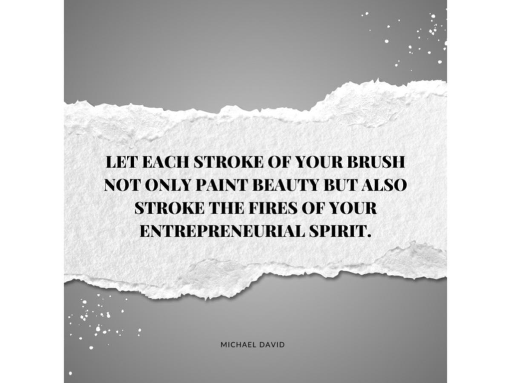

XV

Cultivating

Resilience

and

Well-Being

in

Hairstyling

> Consider it pure joy, my brothers and sisters, whenever you face trials of many kinds, because you know that the testing of your faith produces perseverance.

— James 1:2-3

## Introduction

**R**eflect on the passion and artistry that first drew you to hairstyling, fueling your journey through creativity and resilience. The moments when creativity flows, where every cut and color reflects the vision in your mind. Yet alongside that passion often lies another reality: the exhaustion of long hours, the stress of managing clients, and the pressure to constantly innovate. For freelance hairstylists, the path to success isn’t always smooth. Balancing creativity with the demands of running a business—whether in a rented studio, mobile setup, or at-home salon—can leave you vulnerable to burnout.

In a field that celebrates self-expression, sustaining mental and physical well-being is as critical as mastering the latest techniques. Psychological studies highlight the importance of resilience in high-demand professions like hairstyling. Resilience—our ability to bounce back, adapt, and thrive through challenges—is the foundation for both long-term success and fulfillment. Consider the journey of hairstylist Johnny Wright, known for his work with Michelle Obama. His career wasn’t always glitzy. Through rigorous self-care, a commitment to growth, and community support, Wright navigated the ups and downs of his freelance career and continues to thrive.

Then there’s Tabatha Coffey, a celebrity stylist who rose to fame through her unfiltered approach on television. Behind her on-screen persona, Coffey’s journey has been one of learning to balance a high-profile career with well-being. She has openly shared how prioritizing self-care and setting boundaries became essential to maintaining her resilience amid fame. And Maya Smith, founder of The Doux, represents resilience and authenticity. Smith’s brand stands for more than products—it’s a reflection of her own journey through challenges, as she built a brand that champions self-expression and celebrates natural hair textures.

In this chapter, we’ll dive into strategies to build resilience through mindset shifts, goal-setting, supportive community connections, and self-care practices. With each section, you’ll find tools to strengthen your well-being, ensuring your passion remains sustainable. Let’s explore these empowering practices to help you create a balanced, fulfilling career in hairstyling that endures.

## Burnout Self-Assessment

Take a moment to check in with yourself by answering yes or no to these questions:

1. Do you feel emotionally drained after a typical workday?
2. Have you noticed decreased satisfaction in your styling work?
3. Are you experiencing physical symptoms like headaches, back pain, or insomnia?
4. Do you find yourself canceling personal plans due to work exhaustion?
5. Have you become more irritable with clients or colleagues?
6. Do you feel a sense of reduced accomplishment despite working hard?
7. Are you relying on unhealthy coping mechanisms (excessive caffeine, alcohol, etc.)?
8. Has your creativity or problem-solving ability decreased?

**Scoring:** If you answered “yes” to 3 or more questions, you may be experiencing early signs of burnout. If you answered “yes” to 5 or more, consider implementing the strategies in this chapter immediately and potentially seek professional support.

Remember: Recognizing burnout early is the first step toward reclaiming your well-being and creative passion.

## Building Resilience: Reframing Challenges with a Growth Mindset

In any creative field, resilience starts with how we perceive challenges. Shifting from a fixed mindset to a growth mindset is a powerful way to build mental resilience. Psychologist Carol Dweck describes a growth mindset as seeing failures and setbacks not as limitations but as opportunities for learning. When hairstylists adopt this perspective, it becomes easier to embrace each misstep as a stepping stone to skill and self-improvement.

Example in Action: Renowned stylist Kim Kimble rose to success by adopting this mindset early in her career. Known for her work with Beyoncé, Kimble recalls the struggles she faced in the beginning. Instead of viewing each setback as a failure, she saw them as valuable learning moments. “Challenges have always driven me to learn more, to think differently,” she has said. This attitude helped Kimble innovate her techniques, allowing her to push creative boundaries and achieve career longevity.

Maya Smith’s Story: Maya Smith, founder of The Doux, exemplifies a growth mindset. Building her brand meant staying true to her vision while navigating the complexities of entrepreneurship. Smith’s approach has always been to view obstacles as catalysts for personal and professional growth. She believes in the power of authenticity, sharing her journey openly with her clients and community. This connection strengthens her brand’s message of resilience and pride in individuality.

## Personal Anecdote: Turning Setbacks into Success

There was a time early in my career when a major setback almost derailed my confidence. I had invested months into a promotional campaign that, despite my best efforts, failed to generate the expected response. Instead of wallowing in disappointment, I reframed the experience as a vital learning opportunity. I spent countless hours analyzing what went wrong—from misaligned messaging to technical glitches—and gradually transformed my perspective.

That setback taught me that each failure is a stepping stone, and embracing a growth mindset allowed me to refine my approach, ultimately leading to more innovative strategies and improved client interactions. This experience reshaped how I view challenges and solidified my belief in continuous learning.

**Key Insight:** Every setback contains valuable lessons that can strengthen your resilience and improve your professional approach when viewed through a growth mindset.

### Practical Steps for Hairstylists

1. **Self-Reflection After Setbacks:** Take a moment to analyze challenges. Instead of focusing on “what went wrong,” ask yourself, “What can I learn?” Keeping a journal where you reflect on client experiences, both good and challenging, can help build a constructive outlook.
2. **Seek Constructive Feedback:** Actively seek out constructive feedback from trusted peers or clients to improve your skills. This will help normalize learning from others while broadening your perspective.
3. **Celebrate Small Wins:** Growth doesn’t happen overnight. Celebrating progress, whether it’s perfecting a new technique or managing a difficult client interaction, reinforces a growth-focused outlook.

## Setting Purposeful Goals with the SMART Methodology

For freelance hairstylists, having clear goals can be a lifeline in the fast-paced beauty industry. SMART goals—Specific, Measurable, Achievable, Relevant, and Time-bound—provide a structured framework to achieve tangible progress. These goals anchor us, offering direction and a sense of purpose that strengthens resilience.

Real-World Example: Vernon François, a celebrity stylist known for his advocacy in textured hair care, credits goal-setting with helping him navigate the competitive beauty industry. Early in his career, François set specific goals to develop products that cater to diverse hair types, something he felt was missing in mainstream beauty. By focusing on his goal with purpose and clarity, he built a successful line of products that has changed the textured hair industry.

## Personal Anecdote: SMART Goals in Action

I vividly remember the time I decided to apply the SMART goal framework to boost my freelance business. I set a very clear objective: to increase my client bookings by 20% within six months. Breaking the goal down into specific, measurable, achievable, relevant, and time-bound steps, I crafted a plan that included targeted social media campaigns, a streamlined booking system, and follow-up routines for past clients.

By monitoring my progress regularly, I not only met my target but exceeded it by reaching a 25% increase in bookings. This structured approach gave me the confidence to set and achieve meaningful goals, proving that clarity and discipline can transform aspirations into tangible successes.

**Key Insight:** SMART goals provide the structure and accountability needed to turn ambitious visions into achievable milestones, creating momentum and building confidence.

### Practical Steps for Stylists

1. **Define Specific Goals:** Instead of a vague goal like “I want more clients,” specify it as “I want to attract five new clients in the next month by improving my social media presence.”
2. **Break Goals into Steps:** Outline achievable actions. For example, to increase visibility, plan to post daily on social media, collaborate with a local brand, or attend industry networking events.
3. **Set Milestones and Track Progress:** Regularly review your progress and celebrate reaching smaller milestones. Tracking your efforts helps maintain motivation and a sense of accomplishment.
4. **Adjust and Reflect:** Not every goal will go as planned. Flexibility is essential; re-evaluate and adjust your approach to remain aligned with your overall vision.
5. **Accountability Tip:** Connect with another stylist or professional to share your goals and check in regularly. Having someone to encourage you and keep you on track can boost resilience.

## Building a Support Network Through Community and Vulnerability

A thriving freelance hairstyling career doesn’t have to be a solitary journey. Research from the American Sociological Association underscores the importance of support networks in fostering resilience. Building genuine connections with others in the industry can provide emotional support, shared learning, and professional growth.

Case in Point: Hairstylist and educator Ted Gibson, known for his celebrity clients and salon success, openly credits his community for sustaining him throughout his career. After closing his salon in New York, Gibson joined industry groups and built a network of support, which he describes as invaluable to his resilience. He later reimagined his business in Los Angeles, offering virtual consultations, a shift inspired by his support network’s insights and encouragement.

## Personal Anecdote: Building Future Community

Building a supportive network has always been a goal of mine, and while I haven’t yet established a dedicated community, I’m excited about the future. There was a time when I truly felt the need for a group of like-minded stylists to share insights and lift each other up. That experience has inspired me to create a space where we can all grow together.

With the launch of this book, I look forward to starting a community—Curls n Contemp Collective—where we can exchange ideas, overcome challenges, and celebrate our successes. If you’re reading this, I encourage you to sign up and be part of this emerging collective. Together, we’ll build a network that supports our creative journeys and drives our industry forward.

**Key Insight:** Creating community takes intention and vulnerability, but the support and shared wisdom gained from connecting with fellow professionals can be transformative for both personal and career growth.

### Practical Steps for Cultivating Supportive Connections

1. **Engage with Industry Groups:** Join hairstyling communities, whether online or in person, to share experiences and find mentors. Platforms like Instagram and LinkedIn have active groups for stylists, offering opportunities to connect with others who understand the industry’s challenges.
2. **Create Accountability Partnerships:** Pair with a fellow stylist to set goals, brainstorm solutions, and celebrate wins. Accountability partners offer encouragement and practical insights that enhance resilience.
3. **Attend Events and Workshops:** Industry events provide valuable opportunities to meet like-minded professionals and build your support network.
4. **Practice Vulnerability:** Sharing your challenges can feel uncomfortable but often leads to deeper connections and mutual support. Start small by opening up to trusted colleagues about your experiences.

## Professional Boundary Templates

Clear boundaries protect your well-being and professional standards. Use these templates to address common challenging situations:

**For After-Hours Requests:** “I appreciate you reaching out about your hair emergency. To ensure I provide the best service to all my clients, I maintain specific business hours (list your hours). I’d be happy to schedule you for the next available appointment, which is [date/time]. For urgent styling tips until then, I recommend [quick solution].”

**For Scope Creep:** “I understand you’d like to add [additional service] to today’s appointment. Since this service requires additional time that isn’t available in today’s schedule, I’d be happy to book a follow-up appointment specifically for that service. This ensures you’ll receive the dedicated attention each service deserves.”

**For Price Negotiation:** “I understand budget concerns, and I appreciate your interest in my services. My pricing reflects the quality of products I use, my ongoing education, and the personalized experience I provide. While I can’t adjust my rates, I’d be happy to discuss a service package that might better fit your budget while still meeting your needs.”

**For Persistent Lateness:** “I notice we’ve had some challenges with appointment timing. To ensure you receive a complete service and I can honor my commitments to all clients, I’ll need to start precisely at our scheduled time. If you arrive more than [X minutes] late, we may need to reschedule or modify your service. Would you prefer a different appointment time that might work better with your schedule?”

## Practicing Essential Self-Care

Self-care is not a luxury but a necessity for mental, emotional, and physical well-being. Research highlights how regular self-care improves focus, reduces stress, and enhances overall resilience, allowing professionals to sustain their passion and productivity. For hairstylists who work in dynamic, high-pressure environments, building a self-care routine can make all the difference.

Inspiration from Experience: Celebrity hairstylist Tabatha Coffey, known for her work on TV shows like “Tabatha Takes Over,” has spoken openly about her self-care practices. Coffey maintains that taking time to rest and recharge fuels her creativity and strengthens her resilience. She emphasizes that self-care is what enables her to handle high-stakes situations calmly and with a positive outlook.

## Personal Anecdote: The Power of Self-Care

After years of relentless work, there came a moment when burnout hit me hard—I was missing important family events, and my creative spark was fading. It was then that I realized self-care wasn’t a luxury but a necessity. I began to incorporate practices like daily mindfulness meditation, regular physical exercise, and strict boundaries between work and personal time.

One particularly transformative week, after forcing myself to take a full day off, I returned with renewed energy and a sharper focus on my craft. That turning point taught me that prioritizing self-care not only enhances my well-being but also elevates the quality of my work, proving that taking care of myself is integral to sustaining a vibrant, creative career.

**Key Insight:** Self-care isn’t selfish—it’s essential for maintaining the energy, creativity, and resilience needed to serve clients at your highest level.

### Actionable Self-Care Tips for Stylists

1. **Mindful Morning Routine:** Start the day with intention. A few moments of meditation, deep breathing, or journaling can help center your focus, creating mental clarity before a busy day.
2. **Set Boundaries:** It’s essential to know when to say “no” to extra hours or challenging clients if it compromises your well-being. Respecting your boundaries prevents burnout and keeps your energy sustainable.
3. **Prioritize Physical Health:** Long hours can take a toll on the body. Stretching exercises, regular movement, and proper ergonomics are essential. Making time for exercise—even a quick walk—can boost your mood and keep you energized.
4. **Digital Detox:** Set aside time to disconnect from social media and digital devices. Unplugging from work-related stress helps clear your mind and recharge.
5. **Practice Gratitude:** Reflect on positive moments and achievements at the end of each day. A gratitude journal can reinforce your appreciation for your work and clients, helping you maintain a resilient, positive outlook.

## Mental Health Resources for Creative Professionals

When self-care isn’t enough, professional support can make all the difference. These resources are tailored for creative professionals and entrepreneurs:

**Crisis Support:**

- National Suicide Prevention Lifeline: 988 or 1-800-273-8255 (24/7)
- Crisis Text Line: Text HOME to 741741 (24/7)

**Apps for Mental Wellness:**

- **Headspace:** Guided meditation app with specific programs for work stress and creativity
- **Calm:** Sleep stories and relaxation techniques for better rest
- **Woebot:** AI-based cognitive behavioral therapy chatbot for daily mental health support
- **Youper:** Emotional health assistant that tracks mood patterns

**Organizations for Creative Professionals:**

- **The Boris Lawrence Henson Foundation:** Focuses on mental health in the Black community
- **Loveland Foundation:** Provides therapy support to Black women and girls
- **Beauty 2 The Streetz:** Supports stylists experiencing homelessness or financial crisis
- **Professional Beauty Association:** Offers emergency funding and resources for beauty professionals

**Finding a Therapist:**

- **Therapy for Black Girls:** Directory of culturally competent therapists
- **Open Path Collective:** Affordable therapy for individuals without insurance
- **BetterHelp:** Online therapy platform with flexible scheduling for busy professionals

Remember: Seeking help is a sign of strength, not weakness. Your mental health is as important as your creative talent.

## Physical Wellness for Hairstylists

The physical demands of hairstyling—standing for hours, repetitive motions, and exposure to chemicals—can take a significant toll on your body over time. Proactive physical wellness practices not only prevent injury but also enhance your stamina and career longevity.

### Ergonomic Practices to Prevent Physical Strain

1. **Proper Positioning:** Maintain good posture while working. Adjust your client’s chair height so you don’t need to hunch or reach awkwardly. Your shoulders should be relaxed, not raised or rounded forward.
2. **Supportive Footwear:** Invest in quality shoes with proper arch support and cushioning. Consider compression socks for improved circulation during long days.
3. **Anti-Fatigue Mats:** Place these in areas where you stand the most to reduce pressure on your joints and lower back.
4. **Wrist Protection:** Keep wrists in a neutral position when cutting and styling. Consider ergonomic scissors and tools designed to reduce strain.
5. **Height-Adjustable Equipment:** Use chairs, styling stations, and tools that can be adjusted to your height to prevent unnecessary reaching or bending.

### Essential Stretches for Hairstylists

**Daily Stretching Routine for Stylists**

**Morning Stretches (5 minutes):**

1. **Wrist Flexor Stretch:** Extend one arm forward, palm up. With your other hand, gently pull fingers back toward your body. Hold 15-30 seconds. Repeat on other side.
2. **Shoulder Rolls:** Roll shoulders forward 5 times, then backward 5 times.
3. **Neck Stretches:** Gently tilt your head to each shoulder, holding for 15 seconds.

**Between Clients (1-2 minutes each):**

1. **Standing Back Bend:** Place hands on lower back and gently arch backward.
2. **Finger Spreads:** Spread fingers wide, then make a fist. Repeat 10 times.
3. **Calf Raises:** Rise onto toes, hold for 3 seconds, then lower. Repeat 10 times.

**End of Day Recovery (10 minutes):**

1. **Child’s Pose:** Kneel on the floor, sit back on heels, extend arms forward, rest forehead on mat. Hold 1-2 minutes.
2. **Seated Spinal Twist:** Sit with legs extended, bend one knee and cross it over the other leg. Twist toward the bent knee. Hold 30 seconds each side.
3. **Legs Up The Wall:** Lie on your back with legs extended up a wall. Stay for 2-5 minutes to improve circulation.

### Nutrition for Sustained Energy

1. **Prep Nutrient-Dense Meals:** Prepare balanced meals that include protein, healthy fats, and complex carbohydrates to maintain steady energy levels throughout your workday.
2. **Stay Hydrated:** Keep a water bottle accessible. Dehydration can lead to fatigue, headaches, and reduced concentration.
3. **Strategic Snacking:** Pack small, energy-boosting snacks like nuts, fruit, or yogurt to maintain blood sugar levels between clients.
4. **Limit Caffeine:** While tempting during long days, excessive caffeine can lead to energy crashes. Consider herbal teas or infused water as alternatives.

## Financial Wellness and Mental Well-Being

Financial stress can significantly impact your mental health and creative performance. For freelance hairstylists, irregular income patterns can create additional anxiety. Building financial wellness practices helps create stability, reducing a major source of stress and enhancing your overall resilience.

### Creating Financial Stability as a Freelancer

1. **Emergency Fund:** Build a savings buffer that covers 3-6 months of essential expenses. Start small if necessary—even $500 can provide peace of mind during slower periods.
2. **Separate Business and Personal Finances:** Maintain separate accounts to clearly track income and expenses, making tax preparation less stressful.
3. **Income Smoothing:** During high-earning months, set aside a percentage of income to support yourself during predictable slow seasons.
4. **Diversify Revenue Streams:** Reduce financial vulnerability by developing multiple income sources—services, product sales, education, or content creation.
5. **Understand Your Worth:** Regularly review and adjust your pricing to ensure it reflects your experience, specialization, and market value.

### Simple Financial Practices for Mental Peace

1. **Weekly Money Check-ins:** Schedule 15-30 minutes weekly to review your finances. Regular attention prevents anxiety-inducing surprises.
2. **Automate Essential Payments:** Set up automatic payments for recurring expenses to reduce mental load and avoid late fees.
3. **Implement a Simple Tracking System:** Use apps like Mint, YNAB, or QuickBooks Self-Employed to easily monitor income and expenses.
4. **Create Financial Boundaries:** Establish clear policies about deposits, cancellations, and payment methods to protect your financial health.
5. **Seek Professional Guidance:** Consider consulting with a financial advisor who specializes in working with freelancers or creative professionals.

Remember that financial wellness isn’t about pursuing wealth for its own sake—it’s about creating a foundation that supports your creative freedom and reduces unnecessary stress. Even small steps toward financial organization can significantly improve your mental well-being.

## Embracing Resilience as a Lifelong Practice

Building a career as a freelance hairstylist requires much more than technical skill; it demands resilience, adaptability, and a dedication to well-being. Throughout this chapter, we’ve explored how adopting a growth mindset, setting structured goals, building community connections, and prioritizing self-care can create a foundation for long-term fulfillment and success.

Resilience is not a fixed trait; it’s a practice. With each challenge you face, you have the opportunity to strengthen your resilience, adapting to the demands of the beauty industry while nurturing your passion. Let the tools and insights in this chapter be a guide on your journey. With self-awareness, purpose, and community, you can shape a career that not only sustains you but allows you to flourish.

As you move forward, remember that resilience is both a skill and a journey. Lean on these practices, honor your well-being, and trust in your unique strengths. By fostering resilience, you’ll not only enhance your career but also inspire others to pursue their passions with balance, strength, and intention.

## Actionable Steps

### Immediate Actions (This Week)

1. **Complete the Burnout Self-Assessment** and honestly evaluate your current well-being status
2. **Establish One Daily Self-Care Practice** such as morning meditation or evening gratitude journaling
3. **Set Up Ergonomic Workspace** adjustments to prevent physical strain and injury
4. **Create Professional Boundary Templates** for common challenging client situations

### Short-Term Goals (Next Month)

1. **Develop a SMART Goal** for one specific area of your business you want to improve
2. **Connect with One Industry Professional** to begin building your support network
3. **Implement a Simple Financial Tracking System** to reduce money-related stress
4. **Establish a Daily Stretching Routine** to maintain physical wellness

### Long-Term Strategies (Next 3-6 Months)

1. **Build an Emergency Fund** starting with small, consistent contributions
2. **Join or Create a Professional Community** of like-minded hairstylists
3. **Develop Multiple Revenue Streams** to increase financial stability
4. **Create a Comprehensive Self-Care Plan** that addresses mental, physical, and emotional wellness
1. American Psychological Association, “Building Resilience: How to Bounce Back,” 2019, accessed March 8, 2025, https://www.apa.org/topics/resilience.
2. Hairstylist Insider, “Johnny Wright: From Celebrity Cuts to Innovative Resilience,” August 15, 2019, accessed March 8, 2025, https://www.hairstylistinsider.com/johnny-wright.
3. Modern Salon, “Tabatha Takes Over: How Self-Care Powers High-Profile Stylists,” November 20, 2015, accessed March 8, 2025, https://www.modernsalon.com/tabatha-takes-over-self-care.
4. Dweck, Carol S., *Mindset: The New Psychology of Success* (New York: Random House, 2006).
5. Doran, George T., “There’s a S.M.A.R.T. Way to Write Management’s Goals and Objectives,” *Management Review* 70, no. 11 (1981): 35–36.
6. Umberson, Debra, and Jennifer K. Montez, “Social Relationships and Health: A Flashpoint for Health Policy,” *Journal of Health and Social Behavior* 51, suppl. (2010): S54–S66, https://doi.org/10.1177/0022146510383501.
7. U.S. Occupational Safety and Health Administration, “Ergonomics for Hairdressers,” 2021, accessed March 8, 2025, https://www.osha.gov/ergonomics/hairdressers.
8. U.S. Financial Literacy and Education Commission, “Financial Literacy and the Importance of an Emergency Fund,” 2016, accessed March 8, 2025, https://home.treasury.gov/policy-issues/financial-markets-financial-institutions-and-fiscal-service.

## Quiz

### Question 1

What is the key benefit of a growth mindset for hairstylists?

a) It eliminates all career challenges b) It fosters resilience by viewing setbacks as learning opportunities c) It guarantees immediate success d) It removes the need for skill development

### Question 2

What does SMART stand for in goal-setting?

a) Specific, Measurable, Achievable, Relevant, Time-bound b) Simple, Manageable, Achievable, Realistic, Timely c) Standard, Measured, Applicable, Resilient, Tangible d) Structured, Motivated, Adaptable, Relevant, Task-based

### Question 3

Why is a support network important for hairstylists?

a) It provides shared learning and emotional support b) It guarantees financial success c) It replaces the need for personal skill development d) It removes job-related stress

### Question 4

What is one recommended practice for self-care as a hairstylist?

a) Working longer hours to increase productivity b) Practicing mindfulness and gratitude regularly c) Ignoring physical discomfort d) Avoiding all forms of professional development

## Worksheet

### Resilience Assessment and Planning

**Current State Reflection:**

1. What specific challenges in your hairstyling career cause you the most stress?
2. How do you currently handle setbacks or difficult client situations?
3. What physical symptoms of stress or fatigue do you notice most often?

**Growth Mindset Development:** 4. Describe a recent setback in your career. How could you reframe this experience as a learning opportunity?

5. What’s one new skill or technique you’ve been wanting to learn? What’s been holding you back?

**Goal Setting Exercise:** 6. Using the SMART framework, write one specific goal for improving your well-being:

**Specific:** _________________________________ **Measurable:** _______________________________ **Achievable:** _______________________________ **Relevant:** ________________________________ **Time-bound:** ______________________________

**Support Network Planning:** 7. List three people in your professional network who could provide support or mentorship:

4. What’s one step you can take this week to strengthen your professional connections?

**Self-Care Action Plan:** 9. Choose three self-care practices from this chapter that resonate with you:

4. How will you incorporate these practices into your daily or weekly routine?

**Financial Wellness Planning:** 11. What’s your biggest financial concern as a freelance hairstylist?

12. What’s one small step you can take this month to improve your financial stability?

**Commitment Statement:** Complete this commitment: “To build resilience in my hairstyling career, I commit to…”

**Timeline for Implementation:** _________________________

**Success Metrics:** How will you know these strategies are working?

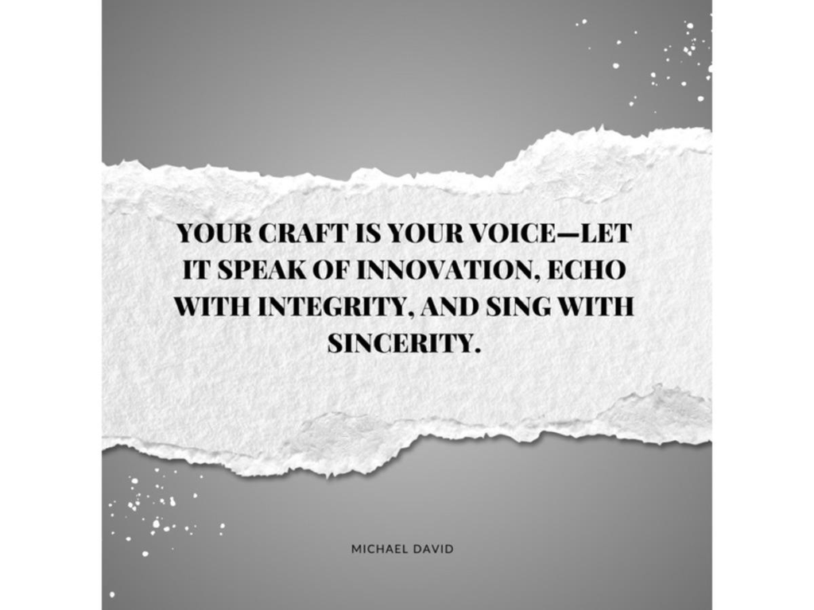

XVI

Tresses

and

Textures

-

Embracing

Diversity

in

Hairstyling

> There is neither Jew nor Gentile, neither slave nor free, nor is there male and female, for you are all one in Christ Jesus.

— Galatians 3:28

## Introduction

**I**magine stepping into a world where every strand of hair tells a story of heritage, identity, and personal expression. The beauty industry has undergone a profound transformation in recent years, evolving from a landscape that often marginalized textured hair to one that increasingly celebrates the rich diversity of hair types, textures, and cultural styles. This shift represents more than just changing trends—it reflects a deeper cultural reckoning with inclusivity, representation, and the acknowledgment that beauty exists in infinite expressions.

As professional hairstylists in today’s diverse marketplace, we stand at the intersection of artistry and cultural awareness. Our ability to work skillfully, respectfully, and confidently with all hair textures isn’t just a professional advantage—it’s an ethical responsibility. The journey toward true inclusivity in hairstyling requires us to examine our biases, expand our technical capabilities, and honor the cultural significance that different hair textures and styles hold for our clients.

This chapter serves as both a practical guide and a philosophical exploration of diversity in hairstyling. From understanding the science behind different hair textures to developing cultural competency in your practice, we’ll navigate the multifaceted landscape of inclusive hairstyling. Whether you work in a community with diverse clientele or in a more homogeneous market looking to expand your expertise, this chapter will equip you with the knowledge, techniques, and mindset to embrace and celebrate the beautiful diversity of human hair.

## Understanding and Honoring Hair Diversity

To truly excel in working with diverse hair textures, we must first understand the scientific and cultural foundations that shape different hair types. This section explores the biological basis of hair diversity while acknowledging the rich cultural contexts that give meaning to different hair textures and styles.

### The Science of Hair Texture Diversity

Hair texture diversity stems from variations in follicle shape, which determine whether hair grows straight, wavy, curly, or coily. A 2019 study published in the *Journal of Cosmetic Science* found that the more oval or flat a follicle’s cross-section, the curlier the hair will be. Straight hair typically grows from round follicles, while curly and coily textures emerge from increasingly elliptical follicle shapes.

Beyond follicle shape, several other factors contribute to texture diversity:

- **Protein Composition:** Variations in keratin proteins and disulfide bonds significantly impact curl pattern and strength.
- **Sebum Distribution:** Natural oils travel more easily down straight hair shafts, while curly and coily textures may experience drier mid-lengths and ends.
- **Moisture Retention:** Different textures exhibit varying abilities to retain moisture, with many curly and coily patterns requiring specialized hydration strategies.

Understanding these biological foundations allows us to approach texture diversity from a scientific perspective, informing our product selections and technique applications.

### Classification Systems: Beyond Andre Walker

While **Andre Walker’s** hair typing system (Types 1-4) has been widely adopted as a reference point for categorizing hair textures, contemporary hair science acknowledges that this system represents a simplified spectrum of a much more complex reality.

Modern texture classification considers multiple factors:

- **Curl Pattern:** The degree of wave, curl, or coil (ranging from straight to zigzag)
- **Density:** The number of hairs per square inch of scalp
- **Porosity:** The hair’s ability to absorb and retain moisture
- **Elasticity:** The hair’s ability to stretch and return to its original state
- **Width:** The diameter of individual hair strands (fine, medium, coarse)

When the hairstylist **Lorraine Massey** introduced her curl-centric approach in *Curly Girl: The Handbook* (2001), she helped shift the industry toward embracing natural textures rather than “correcting” them. Her work demonstrated that effective hair care requires understanding these multiple dimensions of hair character, not just curl pattern alone.

### Cultural Significance of Hair Textures

Hair has served as a powerful symbol of identity, resistance, and cultural expression throughout human history. For many communities, particularly those of African descent, hair carries profound historical and social significance.

A few examples illustrate this cultural richness:

- **Pre-colonial Africa:** Elaborate hairstyles served as indicators of tribe, age, marital status, and social position.
- **Black American experience:** From hot combs during the post-Reconstruction era to the revolutionary Afros of the Civil Rights Movement, to the Natural Hair Movement of today, hair has been intertwined with politics, resistance, and self-affirmation.
- **Indigenous traditions:** Many Native American and First Nations peoples maintain spiritual and cultural practices around hair, with long hair symbolizing connection to community and ancestry.
- **South Asian contexts:** Hair oiling rituals reflect intergenerational knowledge transfer and familial bonding.

## Personal Anecdote: Understanding Cultural Heritage

I once worked with a client who explained how her grandmother’s hair wrapping techniques had been passed down through generations, surviving even through slavery and cultural oppression. As she entrusted me with her hair, I realized I wasn’t merely styling it—I was being invited to participate in a living cultural tradition. This experience transformed my understanding of hair’s profound significance beyond aesthetics.

**Key Insight:** Hair carries deep cultural significance that extends far beyond aesthetics, requiring stylists to approach each client’s texture with respect, cultural awareness, and recognition of the heritage they represent.

Recognizing these dimensions means approaching diverse hair textures not merely as technical challenges but as expressions of cultural heritage deserving respect and celebration. This cultural awareness forms the foundation for truly inclusive hairstyling practice.

## Cultural Competency in Textured Hair Care

Cultural competency—the ability to understand, communicate with, and effectively interact with people across cultures—is essential for hairstylists working with diverse clientele. This section explores how to develop this competency specifically in relation to textured hair care.

### Deconstructing Bias in the Beauty Industry

The beauty industry has historically centered European beauty standards, often positioning straight hair as the ideal while marginalizing textured hair as “difficult,” “unprofessional,” or requiring “correction.” This bias has manifested in various ways:

- **Product Development:** Until recently, mainstream hair care lines offered limited options for textured hair, particularly tighter curl patterns.
- **Professional Education:** Many cosmetology programs provide insufficient training on textured hair, with some states only recently beginning to require textured hair competency for licensing.
- **Media Representation:** Advertising, magazines, and other media have overwhelmingly featured straight or loosely waved hair as the beauty standard.
- **Salon Experiences:** Many clients with textured hair report negative salon experiences, including stylists who express frustration with their texture or recommend chemical straightening as the default option.

Acknowledging these historical biases is the first step toward dismantling them in our own practice. As educator **Nancy Twine**, founder of *Briogeo Hair Care*, notes: “You cannot solve a problem you’re unwilling to acknowledge exists.”

### Language Matters: Communication and Terminology

The language we use around hair textures profoundly impacts client experiences and perpetuates or challenges biases. Consider these guidelines for respectful, inclusive communication:

- **Avoid loaded terminology:** Terms like “good hair,” “bad hair,” “unmanageable,” or “difficult” carry implicit judgment. Instead, use descriptive, neutral language like “coily,” “densely curled,” or “high volume.”
- **Practice active listening:** When clients describe their hair goals, listen without imposing assumptions. A client with coily hair isn’t automatically seeking straightening services.
- **Use inclusive consultation questions:** Rather than asking “What do you want to do about your frizz?” try “How would you like to style your texture today?”
- **Educate without condescension:** Share information about hair care in a way that acknowledges clients as experts of their own experience while offering professional expertise.

## Case Study: Transforming Client Experience Through Language

**Real-Life Example: Teenage Client with 4C Hair**

**Challenge:** A teenage client with 4C hair showed visible hesitancy and discomfort during her initial consultation, despite her hair being healthy and beautiful.

**Solution:** When I gently asked about her discomfort, she explained that previous stylists had only used negative terms like “difficult” or “tough” to describe her hair. I immediately shifted to using positive, accurate descriptive language, calling her hair “beautifully coiled” and “versatile,” while showing genuine appreciation for her texture’s unique characteristics.

**Outcome:** Over subsequent appointments, I witnessed a visible transformation in her confidence and relationship with her hair. She began asking questions about styling techniques and eventually became one of my most enthusiastic advocates, referring several friends.

**Lessons Learned:** The power of language cannot be underestimated. Positive, respectful terminology doesn’t just describe hair—it shapes how clients see themselves and their natural beauty.

### Client-Centered Approaches to Textured Hair

A client-centered approach is essential when working with textured hair, recognizing that each client brings unique hair patterns, needs, and cultural contexts. The relationship between a client and their hair often extends beyond aesthetics into identity, self-worth, and cultural connection.

Practice these client-centered approaches:

- **Comprehensive consultations:** Allow extra time for first-time textured hair consultations. Ask about hair history, current regimen, moisture needs, and styling preferences.
- **Respect cultural considerations:** Be aware that certain styles (like locs, braids, or particular cutting techniques) may hold cultural significance. Approach these with appropriate respect and knowledge.
- **Honor natural textures:** Position yourself as an ally in helping clients embrace their natural texture, rather than suggesting they “fix” or “tame” it.
- **Prioritize education:** Take time to demonstrate techniques and product application methods that clients can recreate at home.

Salon owner and texture specialist **Shannon King** explains: “When you honor a client’s texture history and preferences, you’re not just building trust—you’re acknowledging their autonomy and the relationship they have with their hair. This perspective transforms the service from a transaction into a collaboration.”

## Mastering Techniques for All Hair Textures

Technical proficiency across the spectrum of hair textures requires specialized knowledge and skills. This section focuses on the practical aspects of working with diverse textures, from consultation to cutting, styling, and chemical services.

### Consultation Techniques for Textured Hair

Effective consultations establish the foundation for successful textured hair services. Consider these specialized consultation approaches:

- **Texture analysis:** Assess multiple texture factors including pattern, density, porosity, elasticity, and width. Document these observations for future reference.
- **Dry assessment:** Evaluate textured hair in its natural, dry state before washing to understand its true pattern and behavior.
- **Growth pattern mapping:** Note cowlicks, growth direction changes, and density variations that will impact cutting and styling.
- **Lifestyle considerations:** Discuss maintenance commitment, styling preferences, and how the client’s lifestyle should influence your recommendations.

Celebrity hairstylist **Vernon François** recommends asking clients to bring photos of their hair in different states—freshly washed, second-day, stretched, and styled—to gain a comprehensive understanding of how their texture behaves in various conditions.

### Cutting and Shaping Diverse Textures

Cutting techniques must be adapted for different texture patterns. Consider these texture-specific approaches:

#### Straight to Wavy Hair (Types 1-2)

- Precision cutting techniques work well as these textures generally behave predictably.
- Consider weight distribution and face framing based on density and desired movement.
- For wavy textures, cutting slightly longer than the desired finished length accounts for reduced visual length when the wave pattern is active.

#### Curly Hair (Type 3)

- Dry cutting allows visualization of how curls naturally fall and clump.
- Cutting curl by curl preserves the integrity of curl families.
- Avoid over-layering, which can create excessive volume at the crown.
- Consider curl expansion factor—curls may appear 2-3 inches shorter than their stretched length.

#### Coily Hair (Type 4)

- Work with the hair’s natural state rather than stretching it, which can lead to uneven results when the hair returns to its coiled state.
- Use visible cutting techniques where the client can see your work, building trust and transparency.
- Consider shrinkage factors of 50-75% when determining length.
- Focus on shape and silhouette rather than precise lengths.

Specialized texture cutting programs like *Ouidad’s Carve and Slice method* or *DevaCurl’s DevaCut certification* provide in-depth training on texture-specific cutting approaches.

### Product Knowledge and Application Techniques

Product selection and application methods vary significantly across texture types:

#### Product Selection Principles

- **Moisture-Protein Balance:** All textures require both moisture and protein, but in varying ratios based on porosity and damage levels.
- **Weight Appropriateness:** Product weight should correspond to hair density and desired outcome—lighter products for fine textures, heavier products for dense, coarse textures.
- **Layering Logic:** The sequence of product application significantly impacts results, particularly for curly and coily textures.

#### Application Methods for Different Textures

- **Straight to Wavy:** Even distribution focusing on mid-lengths and ends, avoiding heavy application at the roots.
- **Curly:** Sectioned application with praying hands method or scrunching to encourage curl clumping and definition.
- **Coily:** Thorough saturation using techniques like shingling (applying product to small sections), raking, or the LOC method (Liquid, Oil, Cream) for maximum moisture retention.

## Personal Anecdote: Learning from a Master

During my mentorship with curl specialist **Christo** of *Christo Fifth Avenue*, I learned that product application for textured hair is as much about technique as product selection. I remember him demonstrating how the same styling cream could produce dramatically different results depending on whether it was applied to soaking wet hair, damp hair, or dry hair. This lesson transformed my approach to product application across all textures.

**Key Insight:** The timing and technique of product application can be just as important as the product itself, especially when working with textured hair that requires specific moisture levels and application methods.

### Chemical Services for Diverse Textures

Chemical services require texture-specific modifications to ensure hair integrity:

#### Coloring Considerations

- **Processing Time Adjustments:** Highly porous textured hair may process color more quickly, while low porosity textures may require extended development time.
- **Formula Strength:** Consider texture and porosity when determining developer strengths and formula concentrations.
- **Application Techniques:** Sectioning patterns and application methods may need modification for different curl patterns.

#### Texture Modification Services

- **Relaxers and Straightening:** When clients request these services, implement maximum protection protocols. Consider partial relaxing or spot treating rather than full-head application.
- **Curl Enhancement:** For clients seeking more defined curls, texture-appropriate perm solutions and techniques can enhance natural patterns.
- **Transitioning Support:** Develop protocols for clients transitioning from chemically straightened to natural texture, including trimming schedules and protective styling options.

The key to successful chemical services lies in thorough analysis, realistic expectation setting, and prioritizing hair health throughout the process.

## Building an Inclusive Hair Care Practice

Creating a truly inclusive hair care practice extends beyond technical skills to encompass the entire client experience, from marketing to salon environment to ongoing education. This section explores strategies for building a practice that authentically welcomes and serves diverse clientele.

### Creating an Inclusive Salon Environment

The physical salon environment communicates volumes about inclusivity before a word is spoken. Consider these elements of an inclusive space:

- **Visual Representation:** Display diverse imagery showing various hair textures, ethnicities, ages, and gender expressions in your decor, marketing materials, and social media.
- **Product Selection:** Stock products specifically formulated for a range of textures, including those from Black-owned brands and companies with demonstrated commitment to inclusivity.
- **Accessible Pricing:** Consider texture-neutral pricing structures that charge based on time and product usage rather than imposing higher fees specifically for textured hair services.
- **Physical Accessibility:** Ensure your space accommodates clients with mobility challenges and sensory sensitivities.

Salon owner **Christin Brown** of Santa Barbara’s *Tomahawk Salon* transformed her business by intentionally creating a “texture haven.” By featuring diverse imagery, stocking texture-specific products, and cultivating a team trained in all textures, she attracted a clientele that reflects the full spectrum of hair diversity, even in a predominantly white geographic area.

### Inclusive Marketing Strategies

Marketing that authentically reaches diverse clientele requires thoughtfulness and cultural awareness:

- **Showcase Diverse Work:** Ensure your portfolio, website, and social media feature various textures, with particular attention to those historically underrepresented in beauty marketing.
- **Use Inclusive Language:** Audit your service descriptions, website copy, and social media for language that might alienate certain groups.
- **Target Marketing Efforts:** Consider targeted outreach to underserved communities through partnerships with community organizations, cultural events, or specialized publications.
- **Be Authentically Inclusive:** Avoid tokenism or superficial diversity efforts. Authentic inclusion means showcasing texture diversity regularly, not as a special feature or trend.

Marketing specialist **Lala Inuti** advises: “True inclusivity in marketing isn’t about checking boxes for representation. It’s about consistently showing that you value, understand, and can skillfully serve diverse clients through every aspect of your communication.”

### Continuing Education in Texture Diversity

Texture education is a lifelong journey, not a destination. Consider these approaches to ongoing learning:

- **Specialized Training:** Invest in texture-specific education programs like DevaCurl certification, Ouidad training, or specialized texture courses from organizations like the Textured Hair Elevated Summit.
- **Cultural Immersion:** Attend hair shows, conventions, and events that center diverse textures, particularly those created by and for stylists of color.
- **Digital Learning:** Follow texture experts on social media, subscribe to texture-focused education platforms, and participate in online communities dedicated to textured hair.
- **Mentorship:** Seek mentorship from stylists with extensive texture experience, particularly those with personal and cultural connections to diverse hair types.

Education should encompass both technical skills and cultural context. As texture educator **Diane Da Costa** explains: “You cannot separate the texture from the person. To truly serve textured hair clients, you must understand not just the hair, but the history, culture, and lived experiences attached to it.”

### Building Texture Expertise in Any Market

Stylists sometimes hesitate to invest in texture education if they work in markets with less visible texture diversity. However, texture expertise creates opportunities regardless of location:

- **Underserved Niche:** In predominantly straight-hair markets, texture expertise can position you as a specialized resource, attracting clients willing to travel for skilled texture services.
- **Hidden Demographics:** Many communities have more texture diversity than immediately apparent, including clients who have been straightening their hair due to lack of texture-competent stylists.
- **Universal Applications:** Texture knowledge enhances all hair services, as principles of moisture balance, porosity awareness, and structural cutting benefit all hair types.

## Case Study: Building a Texture Business in an Unexpected Market

**Real-Life Example: Jackie Carr in Rural Midwest**

**Challenge:** Stylist Jackie Carr worked in a rural midwestern town with limited visible texture diversity and wanted to build expertise in textured hair services.

**Solution:** Carr positioned herself as the area’s curl specialist through targeted marketing and specialized education. She invested in texture training, stocked appropriate products, and marketed her services through social media and word-of-mouth.

**Outcome:** Starting with just a handful of curly clients, Carr built a thriving texture-focused business. People began driving from hours away for her services. She now has a waiting list and has hired two other stylists who she’s trained in texture work.

**Lessons Learned:** The demand for skilled texture services often exists even in unexpected markets—these clients just need someone qualified to serve them. Specialization can create opportunity regardless of location.

## The Future of Inclusive Hairstyling

The beauty industry stands at a pivotal moment of transformation. The movement toward true texture inclusivity isn’t a passing trend but a fundamental recalibration of our professional standards and values. As we look to the future, several developments suggest the direction of inclusive hairstyling:

- **Education Evolution:** Cosmetology education is increasingly incorporating comprehensive texture training, with more states requiring texture competency for licensing.
- **Product Innovation:** The explosive growth of texture-specific product lines indicates a market recognition of diverse hair needs, with continued innovation expected.
- **Consumer Empowerment:** Clients with textured hair increasingly expect and demand knowledgeable service, driving industry-wide improvement.
- **Digital Democratization:** Online education has democratized access to texture knowledge, allowing stylists worldwide to develop texture expertise.

For the individual stylist, embracing texture diversity represents both a professional opportunity and an ethical commitment. When we expand our capacity to serve diverse textures with skill and cultural awareness, we contribute to a more inclusive beauty industry while positioning ourselves for continued relevance in an evolving marketplace.

The journey toward texture inclusivity calls us to continual growth—technically, culturally, and personally. It asks us to examine our biases, expand our skills, and embrace the beautiful complexity of human diversity as expressed through hair. By committing to this journey, we honor not just the hair before us, but the full humanity of each client who trusts us with this deeply personal aspect of their identity and self-expression.

As you continue your professional evolution, remember that true texture inclusivity is both a skill set and a mindset—a commitment to seeing, celebrating, and skillfully serving the full spectrum of human hair in all its glorious diversity.

## Actionable Steps

### Immediate Actions (This Week)

1. **Audit Your Language** - Review your service menu and social media for potentially exclusionary language
2. **Assess Your Product Inventory** - Identify gaps in texture-specific products you currently stock
3. **Evaluate Your Portfolio** - Ensure your work showcases diverse hair textures and ethnicities
4. **Begin Cultural Education** - Start following texture specialists and educators on social media

### Short-Term Goals (Next Month)

1. **Invest in Basic Texture Education** - Enroll in an online course or attend a texture-focused workshop
2. **Expand Product Offerings** - Stock products specifically designed for diverse hair textures
3. **Practice Inclusive Consultations** - Implement texture-specific consultation techniques with current clients
4. **Connect with Texture Community** - Join professional groups focused on textured hair education

### Long-Term Strategies (Next 3-6 Months)

1. **Pursue Advanced Texture Certification** - Complete specialized training programs like DevaCurl or Ouidad certification
2. **Create Inclusive Marketing Strategy** - Develop marketing materials that authentically represent texture diversity
3. **Build Texture Referral Network** - Establish relationships with other texture-competent professionals
4. **Establish Ongoing Education Plan** - Commit to continuous learning about cultural competency and texture techniques
1. Gavazzoni Dias, M.F. “Hair Cosmetics: An Overview.” *International Journal of Trichology* 7, no. 1 (2015): 2-15.
2. Jenkins, A. and M. Jones. “Biophysical Characterization of Natural Hair Texture.” *Journal of Cosmetic Science* 70, no. 4 (2019): 195-206.
3. Walker, Andre. *Andre Talks Hair*. Simon & Schuster, 1997.
4. Massey, Lorraine. *Curly Girl: The Handbook*. Workman Publishing, 2001.
5. Byrd, Ayana and Lori Tharps. *Hair Story: Untangling the Roots of Black Hair in America*. St. Martin’s Press, 2014.
6. Thompson, Cheryl. “Black Women, Beauty, and Hair as a Matter of Being.” *Women’s Studies* 38, no. 8 (2009): 831-856.
7. Twine, Nancy. “Redefining Beauty Standards in the Natural Hair Care Industry.” *Journal of Business Ethics* 148, no. 4 (2018): 769-781.
8. King, Shannon. “Building Trust Through Texture Competency.” *Modern Salon*, June 2021, 44-47.
9. François, Vernon. “Embracing Texture: A Holistic Approach to Hair Consultation.” *The Colorist*, April 2020, 28-32.
10. Ouidad. “The Carve & Slice Method: Technical Guide.” Ouidad Professional, 2018.
11. Christo, Fifth Avenue. “Product Application Protocols for Textured Hair.” Curlisto Education Series, 2019.
12. Shapiro, Megan. “Salon Spotlight: How Tomahawk Salon Became a Texture Haven.” *Salon Today*, March 2022, 52-54.
13. Inuti, Lala. “Authentic Inclusivity in Salon Marketing.” *Beauty Business Journal*, February 2021, 17-23.
14. Da Costa, Diane. “Texture Education: Beyond the Technical.” *Texture Press*, 2020.
15. Carr, Jackie. “Building a Curl-Centric Business in Unexpected Markets.” *Salon Business Strategies*, October 2023, 34-38.

## Quiz

### Question 1

Which factor does NOT contribute to hair texture diversity?

- A) Follicle shape
- B) Protein composition
- C) Geographic location
- D) Sebum distribution

### Question 2

Which approach is most appropriate when consulting with a new client who has textured hair?

- A) Suggesting straightening options to make styling easier
- B) Assessing the hair only when wet to see its true length
- C) Evaluating texture characteristics including pattern, porosity, and density
- D) Focusing primarily on identifying problems to fix

### Question 3

What is the primary reason dry cutting is often recommended for curly and coily textures?

a) It’s faster than wet cutting b) It allows visualization of how curls naturally fall and clump c) It creates more precise lines d) It prevents the client from seeing mistakes

### Question 4

Which statement about product application for textured hair is correct?

a) All textured hair requires the same application techniques b) Heavy products are universally better for defining texture c) Application method can impact results as much as product selection d) Product should always be applied to dry hair for best results

## Worksheet

### Inclusive Texture Practice Evaluation

**Personal Reflection:**

1. What is your current comfort level working with different hair textures? Be honest about any biases or limitations you recognize.
2. Describe a time when you may have inadvertently used language that could be perceived as negative about textured hair. How would you handle that situation differently now?

**Skill Assessment:** Rate your current comfort level (1-5, with 5 being most comfortable) with each texture type:

- Type 1 (Straight): _____
- Type 2 (Wavy): _____
- Type 3 (Curly): _____
- Type 4 (Coily): _____
3. Based on your ratings, which textures do you need the most education and practice with?

**Service Menu Analysis:** 4. Review your current service menu. List any language that might alienate clients with textured hair:

5. How would you rewrite these descriptions to be more inclusive?

**Environment Assessment:** 6. Look at your salon space and marketing materials. What visual cues currently communicate inclusivity or exclusivity regarding texture diversity?

7. List 3-5 specific changes you could make to create a more visually inclusive environment:

**Product and Pricing Analysis:** 8. List the texture-specific products you currently carry:

9. Identify gaps in your product inventory for serving diverse textures:
10. Do your pricing structures penalize textured hair? If so, how might you create more equitable pricing?

**Education and Growth Plan:** 11. What specific texture education do you plan to pursue in the next 6 months?

12. Who are three texture specialists or educators you could follow or learn from?

**Action Commitment:** 13. Based on your assessment, identify the three most important actions you’ll take to enhance your texture inclusivity:

**Action 1:** _________________________________ **Timeline:** ________________________________

**Action 2:** _________________________________ **Timeline:** ________________________________

**Action 3:** _________________________________ **Timeline:** ________________________________

14. How will you measure success in becoming more inclusive in your texture practice?

**Cultural Competency Goals:** 15. What steps will you take to better understand the cultural significance of different hair textures and styles?

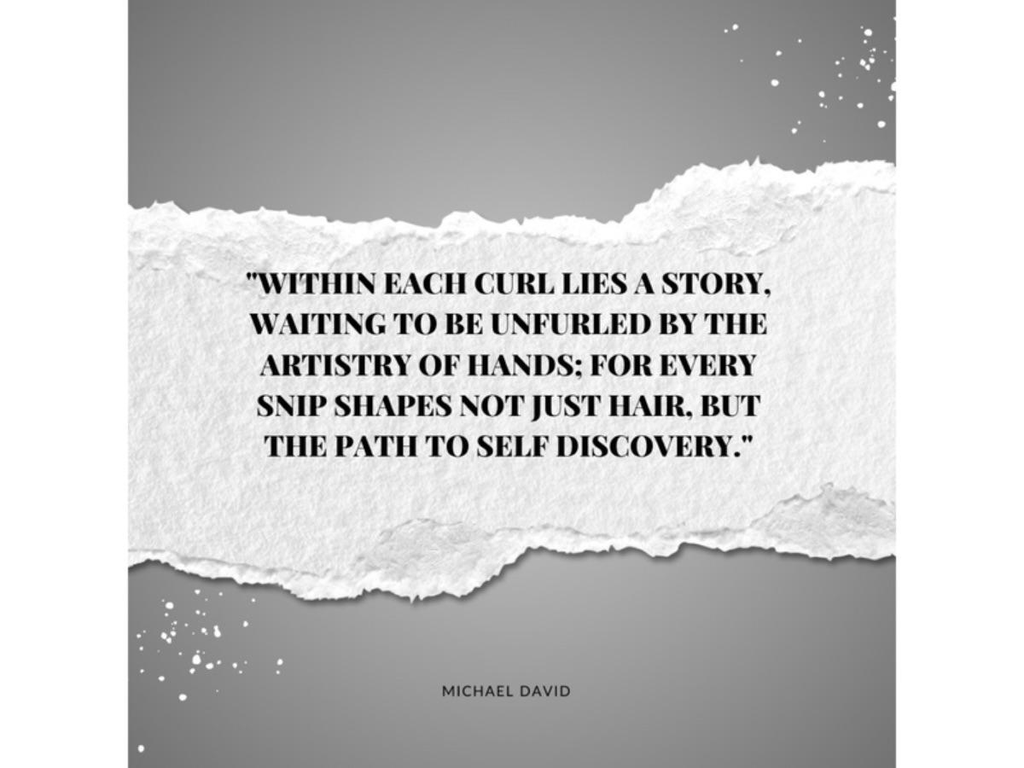

# CONCLUSION

The Enduring Legacy of the Conscious Hairstylist

✨

## The End of One Journey, The Beginning of Another

A

s we reach the end of this extraordinary journey, the salon lights dim, and the final strands of hair fall gently to the floor. In the quietude of this moment, dear reader, I invite you to pause and reflect on the transformative power of your craft—a power that extends far beyond the realm of mere aesthetics.

Consider the story of *Vidal Sassoon*, a pioneer of modern hairstyling who revolutionized the industry with his architectural hair designs and "wash and wear" philosophy. Sassoon's approach was more than just a style; it was a declaration of independence for women, freeing them from the confines of rollers and perms and empowering them to embrace their natural beauty. His legacy illustrates the profound impact that a conscious hairstylist can have on society, using their artistry as a tool for liberation and transformation.

Throughout these pages, we've explored the depths of *artistry*, the heights of *mastery*, and the boundless landscape of *self-discovery*. We've delved into the very essence of hairstyling, illuminating its profound impact on the lives we touch and the world we shape. But this book is more than a collection of techniques; it is a love letter to your inner artist, a tribute to the strength of the human spirit, and a celebration of the beauty within us all. It is a reminder that with every cut, color, and style, we hold the power to transform not just appearances, but destinies.

The conscious hairstylist approaches their craft with intention, awareness, and a deep sense of purpose. Unlike the mainstream focus on trends and surface-level beauty, the conscious hairstylist sees their work as a means of empowerment, connection, and healing. They understand that true beauty radiates from within, and that their role is to help clients unveil and celebrate their authentic selves.

As you embark on the next chapter of your journey, remember that your *creativity* is a precious gift—a guiding light that brightens the path for many. Your hands are the tools of transformation, your heart the compass directing you toward your truest calling. Know that genuine mastery lies not in awards or fame, but in the lives you impact, the confidence you awaken, and the passion you infuse into your art. It lies in the quiet moments of understanding, the joy shared, and the burdens lifted. It lies in the legacy you shape, one lock at a time.

But the journey of growth and evolution does not end with mastery; it is a lifelong pursuit that continues to unfold with each new chapter and opportunity. To truly thrive as a conscious hairstylist, one must commit to ongoing education, experimentation, and self-reflection, always striving to expand their skillset, deepen their understanding, and push the boundaries of their creativity.

So go forth, dear stylist, with fervor and intention. Let your imagination take flight, your empathy be your guide, and your devotion to your craft serve as the bedrock upon which you craft a life of purpose and meaning. Understand that with every strand you mold, every hue you weave, and every tale you tell, you are not simply styling hair—you are sculpting futures.

And in those moments when uncertainty looms, when the trials seem overwhelming, recall the wisdom woven through these chapters. Remember the victories and the challenges, the smiles and the sorrows, the magic and the mastery that have led you to this point. Remember that you belong to a noble lineage, a fellowship of visionaries who possess the capacity to transform the world, one client at a time.

So let your radiance emanate, let your devotion show the way, and let your legacy be one of enlightenment, encouragement, and unwavering commitment to the art that has called you. For ultimately, it is not the styles we design or the praise we garner that define us, but the souls we move and the beauty we breathe into existence.

This is the enduring legacy of the conscious hairstylist—a legacy of purpose, passion, and profound awakening. Embrace it with every ounce of your essence, and know that in doing so, you are not merely transforming tresses; you are transforming trajectories.

And that, my dear friend, is the most stunning work of art imaginable.

#### The Legacy Continues

You are not just a hairstylist. You are an artist, an entrepreneur, a healer, and a visionary. The chair was just your starting point—the world is your canvas.

With endless admiration for your journey,

Michael David

# QUIZ ANSWER KEY

**Book Title:** CURLS & CONTEMPLATION

**Author:** Michael David

This master key contains the correct answers for all chapter quizzes. Each chapter has 4 multiple choice questions with options A, B, C, or D.

📋

## Complete Answer Key for All Chapters

### Chapter 1: Unveiling Your Creative Odyssey

1.C 2.C 3.B 4.C

### Chapter 2: Refining Your Creative Toolkit

1.C 2.B 3.B 4.C

### Chapter 3: Reigniting Your Creative Fire

1.B 2.A 3.C 4.B

### Chapter 4: The Art of Networking

1.B 2.C 3.B 4.B

### Chapter 5: Mentorship

1.B 2.C 3.B 4.B

### Chapter 6: Mastering the Business

1.B 2.C 3.B 4.A

### Chapter 7: Wellness and Self-Care

1.C 2.C 3.C 4.B

### Chapter 8: Continuous Education

1.D 2.C 3.B 4.C

### Chapter 9: Stepping Into Leadership

1.B 2.C 3.C 4.B

### Chapter 10: Crafting Enduring Legacies

1.B 2.C 3.C 4.C

### Chapter 11: Advanced Digital Strategies

1.B 2.C 3.B 4.C

### Chapter 12: Financial Wisdom

1.B 2.C 3.B 4.C

### Chapter 13: Ethics and Sustainability

1.A 2.B 3.B 4.B

### Chapter 14: The Impact of AI

1.C 2.B 3.C 4.C

### Chapter 15: Resilience and Well-Being

1.B 2.A 3.A 4.B

### Chapter 16: Tresses and Textures

1.C 2.C 3.B 4.C

ℹ️

### How to Use This Answer Key

Review your answers against the correct responses above. Each chapter contains 4 questions numbered 1-4 with corresponding correct answers (A, B, C, or D). Use this as a learning tool to identify areas for further study and to reinforce key concepts from each chapter.

### Scoring Reference

A

#### Excellent

Outstanding mastery

B

#### Good

Solid understanding

C

#### Review

Needs more study

"Learning is a journey, not a destination. Every answer teaches us something new."

# POST-READING REFLECTION QUESTIONS

Now that you've completed your journey through *Curls & Contemplation*, take some time to reflect deeply on what you've learned and how you'll integrate these insights into your professional practice and personal growth. These thought-provoking questions will help you solidify your learning and create an actionable path forward.

📝

## Deep Reflection Worksheet

1

### Reflecting on your journey through these chapters, what new insights or strategies have you discovered that will help you advance your skills and well-being as a hairstylist?

Reflection space for your thoughts and insights...

2

### How has your understanding of leadership and mentorship in the hairstyling industry evolved, and what steps will you take to inspire and uplift others?

Reflection space for your thoughts and insights...

3

### Which self-care practices or wellness strategies discussed in the chapters resonated with you the most, and how do you plan to integrate them into your daily routine?

Reflection space for your thoughts and insights...

4

### How has your perspective on continuous education and skill development changed, and what specific actions will you take to keep growing professionally?

Reflection space for your thoughts and insights...

5

### In what ways do you feel more empowered to make a positive impact on your clients, community, and the hairstyling industry as a whole?

Reflection space for your thoughts and insights...

6

### Looking back at your initial goals when you began this book, which ones have you made progress toward? What new goals have emerged?

Reflection space for your thoughts and insights...

7

### On a scale of 1 to 5, how would you rate your confidence in these areas?

Technical hairstyling skills

Low to High Confidence

1

2

3

4

5

Business and entrepreneurial mindset

Low to High Confidence

1

2

3

4

5

Self-care and personal wellness

Low to High Confidence

1

2

3

4

5

Client communication and relationship building

Low to High Confidence

1

2

3

4

5

Creative expression and artistic vision

Low to High Confidence

1

2

3

4

5

8

### What is your personal commitment statement as you move forward in your hairstyling journey?

Write your commitment to your continued growth and excellence...

"The journey of transformation begins with honest reflection and bold commitment to growth."

# FINAL AFFIRMATION WORKSHEET

As you stand at this significant milestone in your creative journey, it's time to weave the essence of your discoveries into a unique, powerful affirmation. This is more than just a collection of words—it's a personal manifesto that captures the core of your inner wisdom and professional identity.

The power of affirmations lies in their ability to rewire our thought patterns and beliefs. When crafted with intention and repeated regularly, they can transform how we see ourselves and our creative potential. This final affirmation will serve as both a celebration of your journey and a compass for your continued growth.

✨

## Craft Your Personal Affirmation

### Sample Affirmations for Inspiration

•

I create with courage, clarity, and compassion.

•

My craft uplifts, respects, and empowers every client.

•

I honor diverse textures, stories, and cultures.

•

My skills grow through practice, study, and patience.

•

I align art, ethics, and wellness in my work.

Reflect on your journey through this book, the insights you've gained, and the self-awareness you've cultivated. Consider the transformations you've experienced and the vision you hold for your future as a creative professional. Now, craft your personal 12-line affirmation below, making each line a powerful declaration of who you are becoming.

### Your Complete 12-Line Affirmation

1

Write your powerful affirmation line here...

2

Write your powerful affirmation line here...

3

Write your powerful affirmation line here...

4

Write your powerful affirmation line here...

5

Write your powerful affirmation line here...

6

Write your powerful affirmation line here...

7

Write your powerful affirmation line here...

8

Write your powerful affirmation line here...

9

Write your powerful affirmation line here...

10

Write your powerful affirmation line here...

11

Write your powerful affirmation line here...

12

Write your powerful affirmation line here...

### Making Your Affirmation a Practice

•

#### Morning ritual:

Read your affirmation aloud each morning as you begin your day, allowing the words to set your intention.

•

#### Visual reminder:

Consider writing your affirmation on beautiful paper and placing it in your workspace where you'll see it regularly.

•

#### Embodiment:

As you recite each line, visualize yourself already embodying these qualities and living these truths.

•

#### Evolution:

Revisit your affirmation every few months and refine it as you continue to grow and evolve in your creative practice.

•

#### Voice recording:

Record yourself speaking your affirmation with conviction and listen to it during moments when you need inspiration or confidence.

This affirmation is more than words; it's a crafted symbol of your path, a guiding light for your future. As you articulate each line, let the vibration of the words resonate deeply, affirming your capabilities, dreams, and the evolving artist you are becoming. Your words have power—use them to create the reality you envision.

# CONTINUING LEARNING PLEDGE

The most successful hairstylists understand that excellence is not a destination, but a journey of continuous growth and evolution. This pledge represents your formal commitment to lifelong learning—a powerful promise to yourself and to those you serve that will elevate your craft, expand your possibilities, and sustain your passion throughout your career.

📜

## My Formal Commitment to Excellence

As a dedicated hairstylist committed to excellence in my craft, I solemnly pledge to embrace lifelong learning as my pathway to mastery. I recognize that in our ever-evolving industry, continuous education and skill development are not optional luxuries but essential foundations for success.

### I vow to:

#### 1. Prioritize Learning by:

•

Dedicating _____ hours each week specifically for education and skill development

•

Attending _____ industry workshops, courses, or training events per year

•

Investing _____% of my annual income back into my professional development

•

Other: _________________________________

#### 2. Seek Diverse Knowledge by:

•

Reading industry publications and books related to hairstyling and beauty

•

Following master stylists and educators on social media and online platforms

•

Learning techniques from different cultural traditions and backgrounds

•

Exploring related disciplines such as art, fashion, photography, or business

•

Other: _________________________________

#### 3. Surround Myself with Mentors by:

•

Identifying and reaching out to _____ mentors in my field within the next 3 months

•

Scheduling regular check-ins with experienced colleagues for feedback and guidance

•

Participating in a mastermind group or community of fellow hairstylists

•

Other: _________________________________

#### 4. Embrace Curiosity and Feedback by:

•

Seeking constructive criticism on my work from trusted colleagues and mentors

•

Implementing a system to collect and review client feedback regularly

•

Approaching new trends and techniques with open-minded curiosity

•

Keeping a learning journal to track my questions, insights, and growth

•

Other: _________________________________

#### 5. Pay It Forward by:

•

Mentoring _____ emerging stylists or assistants within the next year

•

Sharing valuable techniques and insights with colleagues

•

Creating educational content to help others in the industry

•

Contributing to industry events, competitions, or educational platforms

•

Other: _________________________________

#### 6. Embrace the Endless Journey by:

•

Reviewing and updating this pledge every 6 months to reflect my evolving journey

•

Celebrating my growth and achievements along the way

•

Approaching each day with humility and a beginner's mindset

•

Setting progressive learning goals that continuously challenge and inspire me

•

Other: _________________________________

Through this commitment to continuous learning and growth, I invest not only in my abilities but in the positive impact I can have on the lives of those I serve. I recognize that my evolution as a hairstylist opens new doors of opportunity and allows me to add greater value to my clients. This vow is my promise to myself and to those I serve, to continually evolve and contribute positively, one hairstyle at a time.

Signature:

Date:

By signing above, I make this formal commitment to my ongoing growth and excellence as a hairstylist.

"Excellence is never an accident. It is always the result of high intention, sincere effort, and intelligent execution; it represents the wise choice of many alternatives."

- Aristotle

# FROM MY HEART TO YOURS

Dear Fellow Dreamer,

💝

## A Personal Letter of Gratitude

T

he night I decided to put these words on paper, I sat alone at my kitchen table, surrounded by scattered notes and half-empty coffee cups. Doubt perched heavily on my shoulder, whispering that I had nothing worthwhile to say. I share this with you not for sympathy, but because vulnerability creates the most authentic connections—and connection is why I wrote this book.

You're holding years of midnight revelations, breathtaking failures, unexpected victories, and moments of clarity so profound they left me speechless. These pages contain coffee stains from late nights and tear marks from breakthroughs. This isn't just a book. It's a confession. A rebellion. *A love letter to those who dare to reimagine what's possible.*

I remember staring at blank pages, fingers hovering above my keyboard, terrified that I wasn't qualified to guide anyone. Who was I to speak of transformation when I was still figuring it out myself? The words finally came when I stopped trying to be an expert and simply became a fellow traveler, sharing what I'd learned along the way.

Creating requires tremendous courage. There were days when self-doubt felt like my only companion, when I questioned everything—my voice, my path, my worth. I'm guessing you know that feeling too. Perhaps that's what connected us before we even met.

What I've discovered is that the most revolutionary act isn't abandoning our familiar paths—it's transforming how we walk them. It's refusing to accept that our value lies solely in what we produce. *It's understanding that our creative spirits contain multitudes—we can build communities, reshape standards, tell our truths, and still honor the craft that first called to us.*

When doubt wraps itself around your dreams, remember this: The voice questioning if you're enough is the same one that once insisted the earth was flat. Innovation has always faced resistance—first from the world, then from within. Learn to distinguish between legitimate feedback and fear masquerading as wisdom.

As you close these pages, I hope you feel less alone in your ambitions. The path of authentic creation isn't marked with neat signs or many travelers, but those on this journey recognize each other by the light in their eyes—that unmistakable glow of someone who has glimpsed their potential and can never again settle for less.

Take what resonates. Leave what doesn't. Add your own wisdom. This was never meant to be a blueprint but a permission slip—one written by someone who needed it just as desperately as you might.

The greatest thanks I can offer is my promise to keep expanding what's possible, to continue sharing my journey honestly, and to remember that true fulfillment comes when we rise together, celebrating each other's unique brilliance.

With profound gratitude and unwavering faith in your journey,

Michael David

**P.S.** The world will try to convince you that stability is the highest virtue. But we both know that some souls were born to dance with uncertainty—finding their balance not in stillness, but in the perfect rhythm of perpetual motion. Trust the dance.

"In gratitude, we find connection. In connection, we find transformation."

# ABOUT THE AUTHOR

Meet the visionary behind Curls & Contemplation

👨‍🎨

## The Beautiful Rebellion

Three weeks before Michael David Warren Jr. was supposed to begin a promising corporate career, he stood in the cramped office of Arrojo Cosmetology School in NYC, holding his life savings in a worn envelope. The receptionist asked if he was lost. He wasn't—though everyone who loved him thought he must be.

"My grandfather had just helped me put a down payment on a sensible apartment," Michael recalls, eyes gleaming with the mischief that has become his signature. "That night I called him and said I'd returned the deposit. The silence that followed was deafening. Then he said something I'll never forget: 'Some people need safety. Some people need meaning. I've always known which one you were.'"

Arrojo became more than a school—it became the first chapter in a narrative Michael had been silently writing his entire life. While classmates perfected techniques for future salon positions, Michael was designing an education that would serve his bigger vision: a career unconfined by four walls, unbounded by others' expectations.

"On graduation day, most of my class was applying to salons. I was applying for a passport," he says. "I knew every salon offer would become a comfortable cage, and comfort has always been my greatest fear."

### The Nomadic Education

The salon world seemed perplexed by Michael's approach. He would join prestigious teams just long enough to master specific techniques or philosophies, absorbing the expertise of industry titans like Yusef Williams, Naeemah Lafond, and Vernon François before deliberately departing, often turning down promotions that would have anchored him to one location.

"They thought I lacked commitment," Michael explains. "What I lacked was interest in a conventional path. I was committed to freedom—the freedom to work with musicians in Paris one week and teach in Johannesburg the next. The freedom to say no to clients who didn't align with my values, even when my bank account suggested otherwise."

This philosophy transformed Michael into what the industry now recognizes as the quintessential modern hairstylist: part artist, part entrepreneur, part cultural anthropologist. His passport became a textural library—each stamp representing not just a location but an approach to understanding beauty beyond Western standards.

"In Tokyo, I learned that great stylists listen with their hands. In Copenhagen, I discovered that sustainability isn't a trend but a responsibility. In Lagos, I witnessed how hair rituals create sacred spaces between people. No salon could have taught me these things. The world was always meant to be my classroom."

### The Liberation of Freelance

The turning point in Michael's career came when he stopped apologizing for his unorthodox approach and began evangelizing it instead. What the industry had initially perceived as restlessness, he reframed as revolutionary—a deliberate rejection of systems that reward conformity over creativity.

"I remember a salon owner telling me I'd never build client loyalty without 'consistency,'" Michael says with the quiet confidence of someone whose waitlist now extends months. "What he meant was physical consistency—same chair, same corner, same view. What I've proven is that loyalty isn't about geography. It's about transformation. My clients follow me because I evolve, and in turn, help them evolve too."

This evolution continues today. Between writing sessions for this book, Michael traveled to three continents, collaborated with humanitarian organizations bringing dignity through hair services to displaced communities, and continued his own education through masterclasses with artisans both within and beyond the beauty industry.

"The moment I believe I've learned everything is the moment I should retire," he states firmly. "Curiosity is the antidote to stagnation. I'm still taking classes, still making mistakes, still discovering new approaches. That hunger keeps my work alive."

### The Heart Behind the Book

*CURLS & CONTEMPLATION* isn't merely a technical manual—it's the culmination of a philosophy that values liberation over limitation. What began as journal entries scribbled on international flights and voice notes recorded between clients has transformed into what Michael describes as "a permission slip for those who feel trapped by industry expectations."

"I wrote this for the stylist sitting in a breakroom wondering if their dreams are too big," he shares, voice softening. "For the talented creator who feels their wings being clipped by hourly rates and someone else's business model. For anyone who suspects there might be more available to them than what they've been shown."

His voice catches slightly—a rare moment of visible emotion from someone known for his steadiness. "This is the book I needed when I was sleeping on friends' couches between gigs, questioning everything. The book that would have shortened my journey through trial and error. The book that says: trust the voice inside you that wants more than security—it knows exactly where you need to go."

In a world increasingly dominated by algorithms and automation, Michael David Warren Jr. stands as a testament to the enduring power of human touch, intuition, and authenticity. His story reminds us that sometimes the most direct path to our purpose requires leaving the map behind entirely.

As he writes in the book's final chapter: "True freedom isn't the absence of obligations, but the presence of choice. Choose your constraints carefully—make sure they're worthy of containing your one wild and precious life."

### Connect with Michael David

🌐

Website

https://www.michaeldavidhair.com

📱

Instagram

https://www.instagram.com/michaeldavidhair

📧

Newsletter

https://www.michaeldavidhair.com/newsletter

"The most beautiful rebellion is becoming exactly who you were meant to be, regardless of who the world thinks you should become."

- Michael David Warren Jr.

# JOIN THE CURLS & CONTEMPLATION COLLECTIVE

As you turn the final pages of this book, you stand not at an ending but at the threshold of a new beginning. The journey you've embarked on through these chapters—exploring the artistry and soulful expression of hairstyling—has equipped you with insights, techniques, and reflections that can transform both your creative practice and personal growth.

Now is the perfect moment to extend this journey beyond these pages by connecting with a community of like-minded hairstylists who share your passion for artistic excellence, authentic expression, and continual evolution.

🌀

## Your Story Matters

The Curls & Contemplation Collective thrives on the diverse experiences and unique perspectives that each member brings. By sharing your own journey—the challenges you've overcome, the techniques you've mastered, the insights you've gathered—you contribute to our collective wisdom and inspire others who may be facing similar situations.

We invite you to submit your personal "How You Really Feel" letter through our website. This confidential reflection allows you to express the realities of your hairstyling journey—both the triumphs and the struggles—in a supportive environment where vulnerability is honored and celebrated.

These shared experiences become powerful beacons of hope and guidance for others, creating a tapestry of authentic stories that illuminate the path for the entire community.

### Embrace the Community, Share Your Passion

The Curls & Contemplation Collective is more than just a network—it's a dynamic ecosystem where creativity flourishes, knowledge is freely shared, and every member's growth is celebrated. In a profession that can sometimes feel isolating, our community provides the connection, support, and inspiration that fuels sustained passion and innovation.

What Awaits You in the Collective:

#### Supportive Network

Connect with fellow hairstylists who understand your unique challenges and celebrate your creative vision. Our community spans the globe, bringing together diverse perspectives and approaches that expand your horizons.

#### Exclusive Learning Resources

Access a growing library of tutorials, masterclasses, and guides created by industry leaders and innovative stylists. These resources cover everything from advanced technical skills to business development and client communication.

#### Mentorship Opportunities

Benefit from the wisdom of experienced professionals who have navigated the path before you. Our structured mentorship program pairs developing stylists with seasoned experts for personalized guidance and support.

#### Creative Collaboration

Find partners for artistic projects, styled shoots, educational content creation, and innovative business ventures. The collective actively facilitates connections between members with complementary skills and interests.

#### Engaging Discussions

Participate in thoughtful conversations about the evolving role of hairstyling in personal expression, cultural movements, and societal transformation. These discussions deepen your understanding of your craft's significance beyond mere aesthetics.

### Join Us and Let's Embark on This Journey Together

💬

#### Connect on Discord

Join our vibrant, real-time community where conversations flow, questions find immediate answers, and spontaneous inspiration abounds:

https://discord.gg/4C8jDu78

🌐

#### Connect on Website

Discover in-depth resources, submit your story, and access our calendar of virtual and in-person events:

www.unconventionalstylist.com

📱

#### Connect on Social Media

Stay updated with daily inspiration, quick tips, and community highlights:

Instagram: @curlscontemplation

TikTok: @curlscontemplation

Pinterest: @curlscontemplation

Your voice, experiences, and presence are invaluable to our growing community. By joining the Curls & Contemplation Collective, you're not only investing in your own growth but contributing to the elevation of our entire profession. Together, we can redefine hairstyling as a powerful form of artistry, healing, and transformation—one story, one technique, one breakthrough at a time.

Welcome to the next chapter of your journey. We can't wait to see how you'll grow, what you'll create, and whose lives you'll touch through your evolving mastery of curls and contemplation.

"Alone, we can do so little; together, we can do so much." — Helen Keller

#### Ready to Join Our Community?

Take the next step in your journey and connect with hairstylists who share your passion for growth, creativity, and conscious artistry.

# INTERACTIVE JOURNALING GUIDE

Welcome to your personal transformation toolkit! This collection of interactive worksheets is designed to guide you through deep self-reflection, goal setting, and professional growth. Each page is a stepping stone on your journey to becoming the stylist—and person—you're meant to be.

✍️

## Your Journey Ahead

1

### Manifesting Journal

Transform dreams into reality through focused intention and visualization.

2

### SMART Goals Worksheet

Structure your ambitions with specific, measurable, achievable goals.

3

### Professional Development

Chart your career path and identify growth opportunities.

4

### Self-Care Planning

Design sustainable practices that nurture your well-being.

5

### Vision Journal

Clarify your long-term vision and align daily actions with purpose.

6

### Creative Expression

Explore ideas through doodling, sketching, and free writing.

### How to Use These Tools

📝

#### Be Honest:

These exercises work best when you're completely truthful with yourself.

🎯

#### Take Your Time:

Don't rush. Deep reflection requires patience and space.

💡

#### Revisit Often:

Your answers may evolve. Return to these pages as you grow.

✨

#### Trust the Process:

Transformation happens one insight at a time.

Your greatest masterpiece isn't just the hair you style—it's the life you create for yourself. Let's begin this beautiful work together.

#### Ready to Begin Your Journaling Journey?

Take the first step toward deeper self-awareness and intentional growth through the power of reflective writing.

# MANIFESTING JOURNAL

Manifestation is the art of bringing your innermost desires into tangible reality through the alignment of thought, emotion, and action. As a hairstylist, your creative vision has the power to materialize when you focus your intentions with clarity and purpose. This journal provides a framework for articulating, energizing, and activating your professional dreams with deliberate practice.

✨

## The Three Pillars of Effective Manifestation

### 1. Clarity

Define your desires with precision. Vague wishes produce vague results, while detailed visions create detailed outcomes. When you can see, feel, hear, and sense your goal with vivid specificity, you've created a blueprint for manifestation.

### 2. Belief

Cultivate unwavering faith in both the possibility and your worthiness of your desires. Doubt creates resistance; confidence creates flow. Your mind must accept your vision as an eventual reality before your external world can reflect it.

### 3. Aligned Action

Take consistent steps that harmonize with your vision. Manifestation isn't passive wishing—it's co-creation through inspired movement. When your actions align with your intentions, you become a powerful conduit for manifestation.

Use this journal regularly—ideally daily—to maintain focus on your vision and strengthen your manifestation practice. Date each entry to track your journey and notice patterns in your manifestation process. Remember that manifestation is both an art and a science; approach it with both creativity and discipline.

Date:

### Gratitude Alignment

Begin by acknowledging what you already appreciate in your hairstyling practice. Gratitude connects you to abundance and primes your energy for receiving more.

I am grateful for:

Writing space for your manifestation practice...

### Milestones on Your Path

Describe 3 specific scenarios that represent milestones on your path to manifesting your hairstyling dreams. Envision them happening and feel the positive emotions they evoke. Be as detailed and sensory as possible.

Milestone 1: Near Future (1-3 months)

Your response here...

Milestone 2: Mid-Term (6-12 months)

Your response here...

Milestone 3: Long-Term Vision (1-3 years)

Your response here...

### Your Ideal Future

Close your eyes and imagine your ideal future as a hairstylist. What does success look and feel like to you? Describe your vision in vivid detail, engaging all your senses.

Writing space for your manifestation practice...

### Positive Affirmations

Write 3 positive affirmations that align with your hairstyling vision. Craft them in present tense, as if they are already true. Repeat them to yourself daily to reinforce a mindset of growth and opportunity.

Affirmation 1: Professional Identity

Your response here...

Affirmation 2: Creative Expression

Your response here...

Affirmation 3: Abundance and Impact

Your response here...

### Aligned Actions

Identify specific steps you can take today that move you toward your vision. Choose actions that feel energizing and inspired rather than forced.

Writing space for your manifestation practice...

### Evidence and Synchronicities

Record any signs, coincidences, or progress indicators that suggest your manifestation is underway. Recognizing evidence reinforces your belief and accelerates the manifestation process.

Writing space for your manifestation practice...

### Releasing Blocks

Identify any limiting beliefs, fears, or doubts that may be hindering your manifestation. Write them down, then consciously release them by writing a new, empowering perspective for each.

Limiting Belief 1:

Your response here...

New Perspective 1:

Your response here...

Limiting Belief 2:

Your response here...

New Perspective 2:

Your response here...

### Daily Reflection

End your manifestation practice with a moment of reflection. How did this journaling session shift your energy or perspective? What insights emerged?

Writing space for your manifestation practice...

Remember: Manifestation thrives on consistency and emotional connection. Return to this journal regularly, infusing your writing with genuine feeling and expectation. The universe responds not just to your words, but to the energy behind them.

#### Begin Your Manifestation Practice

Transform your dreams into reality through focused intention, clear vision, and inspired action.